# TMA03_FINAL

## Python Activity - Structure formation in the Universe

### Detecting the signature of Baryon Accoustic Oscillations

In Chapter 11 of the *Cosmology* textbook, you learned how acoustic oscillations propagating through the Universe before recombination and the epoch of last scattering produce detectable signatures in the distribution of galaxies today. These signatures are called *baryon acoustic oscillations* (or BAOs for short).

In this activity you will work with real observational data that were assembled by the [Dark Energy Survey](https://www.darkenergysurvey.org) (DES) team. These data list the celestial coordinates (Right Ascension and Declination) and the redshifts of over 7 million galaxies! Your goal will be to analyse these survey data and fulfil two key objectives.

1. Detect a characteristic signature of BAOs that are imprinted on the large-scale spatial distribution of galaxies.
2. Show that the angular size of this signature evolves with redshift and that this evolution is consistent with the [cosmological parameters](https://arxiv.org/abs/1807.06209) that were derived by the *Planck* science team in 2018.

**The code provided is complex, and will require careful reading to understand what it is doing, and how this relates to identifying the large-scale structure in the galaxy catalogue. However, the tasks you need to complete consist of understanding, running and modifying the code, and interpreting its results, not writing new code blocks.**

Before you start this activity, you should have carefully worked through Chapters 10 and 11 of the *Cosmology* textbook.

We will start by importing the `numpy` package and the `matplotlib.pyplot` module. We will assign the latter the short alias `plt`.

**Note that we will be importing other Python packages that we need as and when we need them. That means that if you complete this activity in several sittings and need to close and reload the notebook, then you will need to rerun *all* the cells that you worked through in the previous sessions before you carry on. If you forget to do this you may find that subsequent cells fail to run because the packages they require have not been imported.**

```python
import numpy as np
import matplotlib.pyplot as plt
import pandas as pd
```

## Part 1: Load and inspect the catalogue data

We will start by loading the catalogue from a FITS file provided by the DES team. Once we have opened the file we will read the data in the first extension into an `astropy` table object. If this process seems unfamiliar, then you should watch the "Data analysis part 2: catalogues and spectra" Python skills video, where we explained how to read tabular data from FITS files in much more detail.

This is not a scientifically interesting task so we have written the code for you. If you are working on this activity via the OCL, then we have already downloaded the FITS file for you and you should just be able to run the next two cells without modification.

Otherwise you can download the file from [this link](http://desdr-server.ncsa.illinois.edu/despublic/y3a2_files/baosample/DESY3_LSSBAO_CATALOG.fits) and you may need to update the value of the `catalogue_file_path` variable in the second cell to point to the location you downloaded it to.

First, run the next cell to import two astropy modules that we need to read the FITS file and create a table containing its data.

```python
import astropy.io.fits as apfits
import astropy.table as aptable
```

Run the next cell to open the FITS file and create a table called `data_table` using the data in the first extension.

```python
# If you download the file yourself you may need to change this file path
catalogue_file_path = "/opt/shared-data/DESY3_LSSBAO_CATALOG.fits"

# Open the file
with apfits.open(catalogue_file_path) as data_fits:
    # create a table called `data_table` holding the data in the first extension
    data_table = aptable.Table(data_fits[1].data)
```

Let's do a quick check that we've loaded the data correctly. To do this, we'll use the `display` function that you saw in the "Data analysis part 2: catalogues and spectra" Python skills video. The function will display a few details about the table and a subset of its contents so we can check that they look reasonable.

```python
# use the `display` function gives details about the table and some of its contents
display(data_table)
```

*Table length=7031981*

| RA float64 | DEC float64 | COADD_OBJECT_ID int64 | TILENAME str12 | HPIX_4096 int64 | SOF_CM_MAG_ERR_I float64 | SOF_CM_MAG_ERR_G float64 | SOF_CM_MAG_ERR_R float64 | SOF_CM_MAG_ERR_Z float64 | SOF_CM_MAG_CORRECTED_I float64 | SOF_CM_MAG_CORRECTED_G float64 | SOF_CM_MAG_CORRECTED_R float64 | SOF_CM_MAG_CORRECTED_Z float64 | DNF_ZMC_SOF float32 | DNF_ZMEAN_SOF float32 | DNF_ZSIGMA_SOF float32 | WTOT float64 |
| --- | --- | --- | --- | --- | --- | --- | --- | --- | --- | --- | --- | --- | --- | --- | --- | --- |
| 0.78088 | -35.517303999999996 | 142381265 | DES0004-3540 | 67218510 | 0.014310012859636956 | 0.02738855717879745 | 0.014284280296884055 | 0.016969463194769854 | 19.933414373534536 | 21.964519052446253 | 20.669474995739236 | 19.56951050246005 | 0.63826 | 0.62022704 | 0.045591164 | 1.0141275873468105 |
| 1.7890329999999999 | -37.357574 | 179836883 | DES0007-3706 | 67184745 | 0.013438561466475324 | 0.05281973110298955 | 0.017245621016924107 | 0.014368704177054485 | 19.674343736953364 | 22.708071366026086 | 20.810370635050308 | 19.197421510783602 | 0.706514 | 0.68562007 | 0.020323604 | 1.000732029159304 |
| 30.774510999999997 | -11.499084 | 67959417 | DES0203-1124 | 71633178 | 0.022496538023512817 | 0.1139605834968087 | 0.02863163070675791 | 0.0234042129036183 | 20.683466145478725 | 23.40765305240256 | 21.709015524230402 | 20.28205245070702 | 0.6203 | 0.6809188 | 0.08051174 | 0.9907464386854997 |
| 27.661991 | -12.196586 | 256038934 | DES0149-1207 | 71603361 | 0.019641853745618113 | 0.05244511027131809 | 0.02301722968628803 | 0.02221012134803913 | 20.555167825173427 | 22.890873286527764 | 21.473877411420048 | 20.18740818459362 | 0.729933 | 0.6749786 | 0.043276723 | 1.0028986428768316 |
| 1.838457 | -37.048972 | 179820308 | DES0007-3706 | 67185474 | 0.02013030663322522 | 0.05252623605140992 | 0.02001602305145903 | 0.02038170699387349 | 20.398587005434702 | 22.703953134628073 | 21.33412586516413 | 19.953395208884785 | 0.66324 | 0.6915173 | 0.04629432 | 1.0064175525587988 |
| 28.248151999999997 | -11.498823999999999 | 261363277 | DES0154-1124 | 71616035 | 0.01206785280653588 | 0.02630437880251341 | 0.01325079994186857 | 0.013300820567328701 | 20.211106208751243 | 22.398728117502134 | 21.02527509535497 | 19.807835470196864 | 0.60162 | 0.63089335 | 0.018907662 | 1.0099509105545659 |
| 28.151044 | -11.378962 | 256590792 | DES0151-1124 | 71617541 | 0.021040960320833673 | 0.09103152742631733 | 0.025025868081955536 | 0.022996548743665107 | 20.829823200428738 | 23.765709143661084 | 21.81029348293731 | 20.388686457098785 | 0.642693 | 0.64554495 | 0.04045648 | 1.0011205007042172 |
| 29.708282999999998 | -11.619047 | 61911655 | DES0200-1124 | 71594483 | 0.015100047125308012 | 0.05258599154798432 | 0.016276642488222935 | 0.014167838651881648 | 20.562488797347914 | 23.10357993216125 | 21.46960964434234 | 20.19241559365739 | 0.662589 | 0.62802273 | 0.028187165 | 0.9978271460958149 |
| 3.809493 | -36.07664 | 183958956 | DES0014-3623 | 67199314 | 0.01628050224617618 | 0.05825500791402378 | 0.018480440256558636 | 0.01721422978645722 | 19.733062458114908 | 22.630264876692607 | 20.77563863496191 | 19.26040010466216 | 0.634223 | 0.6379382 | 0.02391501 | 0.9991395419335141 |
| 2.123027 | -36.600014 | 179532383 | DES0007-3623 | 67186539 | 0.01307993490633792 | 0.026849993755217225 | 0.014772131082932703 | 0.016813163587040773 | 19.716491407163527 | 21.556507058096397 | 20.419523002202215 | 19.352988706566403 | 0.632122 | 0.6311993 | 0.022134654 | 0.9837167891941636 |
| ... | ... | ... | ... | ... | ... | ... | ... | ... | ... | ... | ... | ... | ... | ... | ... | ... |
| 36.588105 | -18.141144 | 117099905 | DES0225-1749 | 149352472 | 0.0658608385535179 | 0.3813224059976261 | 0.10208349234811115 | 0.06584707999415114 | 21.90710209094972 | 24.869921402704737 | 23.049497845794615 | 20.973181938229633 | 0.935511 | 1.0309981 | 0.11233492 | 0.9421363226404442 |
| 33.322015 | -18.877152 | 89538004 | DES0212-1832 | 149686854 | 0.14941475903016077 | 0.23256358562766732 | 0.15786766984371262 | 0.15825522080300275 | 22.16259543415153 | 23.660103587228896 | 22.968304346962263 | 21.420698078722452 | 0.625 | 1.0643395 | 0.23058106 | 1.0601959626560646 |
| 41.894005 | -21.433942 | 320023775 | DES0246-2124 | 149227912 | 0.037944832880418694 | 0.19791124699798393 | 0.05546480645784614 | 0.03575885701320508 | 21.53750918943115 | 24.21488175491027 | 22.526556832891988 | 20.635033832943364 | 1.10103 | 1.0155076 | 0.055197734 | 0.992292584497251 |
| 38.050942 | -18.835261 | 128642405 | DES0230-1832 | 149321381 | 0.04383498767842639 | 0.06714770004850167 | 0.04568458180327627 | 0.03776249334826073 | 21.296795177104023 | 22.60637169361372 | 21.92468686141711 | 20.383634391376987 | 1.09 | 1.0804455 | 0.024537636 | 0.9498355386251467 |
| 38.251115 | -18.382939 | 307214489 | DES0233-1832 | 149366936 | 0.03343688781137764 | 0.18908022931193086 | 0.04065485289278703 | 0.02917482492237273 | 21.74882624356485 | 24.81169453010621 | 22.8364410352603 | 20.817318363948544 | 1.23334 | 1.0265921 | 0.04642292 | 0.9765268891751182 |
| 37.73363 | -21.209559 | 127332247 | DES0230-2124 | 149207899 | 0.07024669898745513 | 0.07771634976228015 | 0.06726366069840609 | 0.0751184083983415 | 22.049367749924215 | 23.15781589227837 | 22.669208870531772 | 21.539334626197554 | 1.01851 | 1.0516747 | 0.10355773 | 0.9721841187159594 |
| 35.219263 | -17.295344999999998 | 110177663 | DES0221-1707 | 149704075 | 0.046063117831784066 | 0.3058873820031027 | 0.06922488543456139 | 0.05245063239923817 | 21.92179336563776 | 24.953507184372693 | 23.124061052427685 | 21.03151698604609 | 0.941774 | 1.0017973 | 0.06967465 | 0.9360172331959196 |
| 38.815506 | -18.72521 | 307233313 | DES0233-1832 | 149359354 | 0.05873506608527341 | 0.6737253505426937 | 0.07864527946322135 | 0.05443656194644921 | 21.850594548449155 | 25.739991570229172 | 23.030697628277487 | 20.912779164783792 | 1.02102 | 1.003357 | 0.08546507 | 0.9560992140124406 |
| 38.459362 | -20.511477 | 307743714 | DES0234-2041 | 149220899 | 0.053870335355003886 | 0.08273211838656575 | 0.059022078241174704 | 0.053447231947861086 | 21.826399042771293 | 23.47911352358523 | 22.691844052913964 | 21.09501909480062 | 1.1 | 1.0412655 | 0.09596398 | 1.0669940978208607 |
| 39.615455999999995 | -19.118522 | 313549812 | DES0239-1915 | 149356920 | 0.059115412150919554 | 0.6944399861884333 | 0.07172359176886721 | 0.056613558551226795 | 21.74059390901347 | 25.84060924097866 | 22.812473621161185 | 20.69679107388628 | 1.14 | 1.0516762 | 0.09722268 | 0.9779902001029014 |

The first line of the output tells us that the table contains 7031981 rows. We know there should be over 7 million galaxies in the catalogue, so that looks okay. We can also look at the names of the different columns that the table contains. The ones we will use in this activity are:

1. `RA` - This column lists the Right Ascension celestial coordinate (often denoted $\alpha$) for each galaxy in the catalogue, in degrees.
2. `DEC` - This column lists the Declination celestial coordinate (often denoted $\delta$) for each galaxy in the catalogue, in degrees.
3. `DNF_ZMEAN_SOF` - This column lists the estimated redshifts for each galaxy in the catalogue. The strange looking column name reflects the method used to get the redshift estimate, but you don't need to know about that for this activity

## Part 2: Load and inspect a map of the survey "footprint"

In addition to the survey data themselves, the DES team have also provided details about the area on the sky that contains the galaxies in the catalogue you loaded in *Part 1*. This area is often referred to as the survey "footprint". In this part, you will load the footprint data from a FITS file and plot a map of the footprint projected onto the sky.

The survey footprint map is provided as a HEALPix skymap. You have already learned about the HEALPix format in the second S385 Python Activity. Just like we did in that activity, we will use the `healpy` package to load the map and inspect its contents. We start by importing the package and giving it a short alias `hp`.

```python
import healpy as hp
```

Before we can use `healpy` to plot the footprint map, we need to load the footprint data from the FITS file provided by the DES team. The data are stored in the **first extension** of the file.

If you are working on this activity via the OCL, then we have already downloaded the footprint data FITS file for you. The file is called `des_footprint.fits` and you can find it in the `/opt/shared-data` directory. Otherwise you can download the file from [this link](https://learn2.open.ac.uk/mod/resource/view.php?id=2393295).

The code in the next cell opens the FITS file containing the footprint data and reads those data into an `astropy` table and assign that table to a variable named `des_footprint_data`.

```python
# create a variable holding the FITS file path
footprint_file_path = "/opt/shared-data/des_footprint.fits"

# open the footprint FITS file
with apfits.open(footprint_file_path) as des_footprint_fits:
    # create a table called `des_footprint_data` holding the data in the first extension
    des_footprint_data = aptable.Table(des_footprint_fits[1].data)
```

To display the table we just use the `display` function and pass our table as the single argument.

```python
display(des_footprint_data)
```

*Table length=20248610*

| HPIX_4096 int64 | COVERAGE_GRIZ float64 | FOREGROUND int16 | BADREGIONS int16 | DEPTH_SOF_I float64 |
| --- | --- | --- | --- | --- |
| 148051311 | 1.0 | 0 | 0 | 23.073556900024414 |
| 148062235 | 1.0 | 0 | 0 | 22.95286750793457 |
| 142276861 | 1.0 | 0 | 0 | 23.214303970336914 |
| 147870859 | 1.0 | 0 | 0 | 23.2386417388916 |
| 142322239 | 0.8125 | 0 | 0 | 23.104875564575195 |
| 142269864 | 1.0 | 0 | 0 | 23.14451026916504 |
| 142314525 | 0.890625 | 0 | 0 | 23.386722564697266 |
| 147873744 | 1.0 | 0 | 0 | 23.25383949279785 |
| 147926294 | 1.0 | 0 | 0 | 23.138195037841797 |
| 142292469 | 0.96875 | 0 | 0 | 22.913883209228516 |
| ... | ... | ... | ... | ... |
| 150016988 | 0.9375 | 0 | 0 | 22.948190689086914 |
| 148434530 | 1.0 | 0 | 0 | 23.08450698852539 |
| 148533769 | 1.0 | 0 | 0 | 22.97718620300293 |
| 148534107 | 1.0 | 0 | 0 | 23.040822982788086 |
| 148536189 | 1.0 | 0 | 0 | 23.243927001953125 |
| 148525974 | 1.0 | 0 | 0 | 23.163442611694336 |
| 148429920 | 1.0 | 0 | 0 | 22.918094635009766 |
| 148428251 | 1.0 | 0 | 0 | 23.219160079956055 |
| 148398049 | 1.0 | 0 | 0 | 22.974689483642578 |
| 148480716 | 1.0 | 0 | 0 | 23.073673248291016 |

Now that the data have been loaded into memory we can use some of the functions provided by `healpy` to manipulate and plot them.

You may recall from the second Python activity that `healpy` defines pixels on the sky with equal area, and so there must be fewer pixels in the longitude direction for latitudes close to the poles of a sphere than there are for latitudes close to the equator. That means that it doesn't make sense to use a rectangular array to store the data for each pixel. Instead, `healpy` uses a one-dimensional array and maintains an *index* that defines constant mapping between elements of the array and specific locations on the sky.

The [documentation](https://des.ncsa.illinois.edu/releases/y3a2/Y3bao) that was provided by the DES team to accompany this catalogue is very detailed and you don't need to read it. However, it tells us that the `HPIX_4096` column of the footprint data table we just created contains the HEALPix index for `nside=4096` in NEST schema.

It turns out that `healpy` can use one of two rules (or schemas) to map between positions in a 1d array of data and locations on the sky. We don't need to know the details of these schemas, we just need to remember that the NEST schema was used to produce our data and `healpy` can use the values in the `HPIX_4096` column to identify the area on the sky that the data in each row of our table correspond to.

We will make use of the `nside` parameter later. It controls the size of the pixels created by `healpy`. Larger values of `nside` correspond with smaller pixels.

The other columns in the table list the various characteristics of the survey in each pixel. We will use the data in the `COVERAGE_GRIZ` column, which tells us what fraction of the pixel's area was observed using all four four survey filters, which are named $g$, $r$, $i$ and $z$.

For efficiency, the table doesn't contain information about the whole sky. It only provides data for HEALPix pixels that were at least partially observed by the survey. To plot the coverage data in the `COVERAGE_GRIZ` column, we need to perform three operations:

1. We need to work out how many pixels would be used by HEALPix to cover the *whole* sky using the same schema that was used to create our footprint data. This is where we use the fact that `nside=4096` We can use the `healpy.nside2npix` function to calculate this number.
2. We need to create an array of zeros with enough elements to represent the number of pixels we calculated in step 1. We can use the `numpy.zeros` function to do this. Notice that we pass an extra keyword argument named `dtype` to the zeros function and set this equal to `np.float16`. The effect of this keyword argument is to store the numerical values using a smaller amount of computer memory per value (16 bits versus the default 64). The reason we do this is because the data sets you will use in this activity are very large and if we store them all at very high precision, we run the risk of exhausting the available system memory. We have tested the notebook and restricting the numerical precision of the data does not compromise the results. You will see several places in this notebook where we add similar memory-saving keyword arguments to functions you are familiar with. However, we will not ask you to write code that includes them.
3. We need to set the values of any pixels that have non-zero coverage to the value stored in the `COVERAGE_GRIZ` column of our table. To do this we pass the values in the `HPIX_4096` using the indexing operator of our pixel array (see the Python skills video "Working with data in Python") to select the pixels that we have data for and then assign the values in the `COVERAGE_GRIZ` to them.

The code in the next cell executes these three steps. Before you run it, take the time to read each line and try to convince yourself that the code is really performing the operations we described.

```python
# Calcuate the number of pixels required to cover the whole sky for nside=4096
num_pixels = hp.nside2npix(nside=4096)
# Create a 1-dimensional array containing all zeros with length equal to the number of pixels
footprint_map = np.zeros(shape=num_pixels, dtype=np.float16)
# Use the indexing operator to select the pixels we have data for and set them equal to
# the fractional coverage of the survey for each pixel
footprint_map[des_footprint_data["HPIX_4096"]] = des_footprint_data["COVERAGE_GRIZ"]
```

Now we can use two more `healpy` functions to plot our coverage data. The first is called `mollview` and it can be used to plot the data on a map of the whole sky using a [*Mollweide* projection](https://en.wikipedia.org/wiki/Mollweide_projection), in the same way as you have seen previously for plots of the CMB.

The second function we need is called `graticule`. This function draws axes and gridlines on our plot so that we can easily tell which parts of the sky our survey covers.

The next cell shows how to use these two functions. You can read the comments to find out what each function argument controls. You might like to experiment by changing the values of these arguments to see the effect they have.

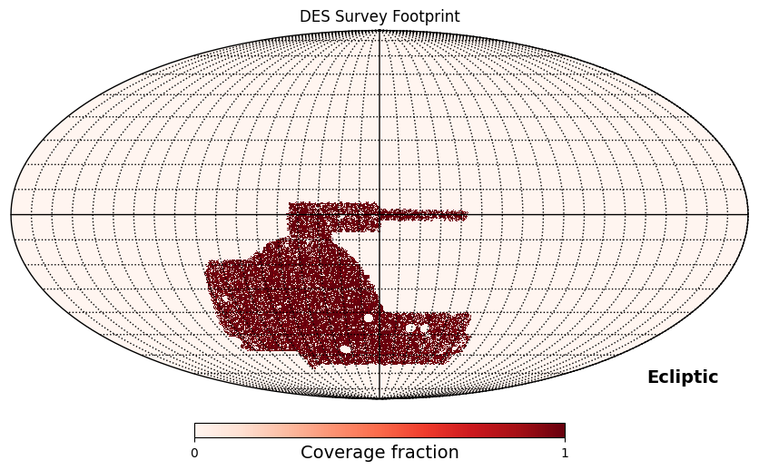

```python
# Call the mollview function to plot the data
hp.mollview(
    # The map data we want to plot
    footprint_map,
    # Specify that the data use the NEST schema
    nest=True,
    # Specify a colour map for our data
    cmap="Reds",
    # Specify a title for our plot
    title="DES Survey Footprint",
    # Specify the property that we are plotting for each pixel
    unit="Coverage fraction",
    # Specify that the pixels are aligned to the Ecliptic (RA - Dec) coordinate system.
    coord="E",
)
# Call the graticule function to add some grid lines
# Note: Choosing values less than 10 for dmer and dpar can have unexpected results.
hp.graticule(
    # Specify that the pixels are aligned to the Ecliptic (RA - Dec) coordinate system.
    coord="E",
    # Draw gridlines in the north-south (up-down) direction separated by 10 degree intervals.
    dmer=10,
    # Draw gridlines in the east-west (left-right) direction separated by 10 degree intervals.
    dpar=10,
)
```

Now we can see that the survey spans an irregular area on the sky. A lot of that area is fully covered with a coverage fraction around one. However, there are some gaps in the coverage. These correspond with the locations of bright stars or very nearby galaxies and have been deliberately excluded.

In the next part, we will plot the redshifts of the galaxies in a thin "slice" of the survey data. By doing so, we will see that the galaxies are not uniformly distributed in space and do show some signs of the large-scale structure that we will try to quantify later in this activity.

## Part 3: Plot the redshifts for a slice of the catalogue data

In this part, we will make a plot using some of the data contained in the survey catalogue table. In particular, we will plot the redshift versus Right Ascension for a subset of the galaxies that lie within a thin "slice" across the declination axis.

For the purposes of this demonstration we will pick the slice between $\delta = -40$ and $\delta = -45$, but you can experiment with other declination ranges. You could even try slicing in the right ascension direction.

Let's start by defining our selection. We write an expression to select galaxies that have values in the `DEC` column of our data table that are less than -40 **and** (`&`) greater than -45. You can see an example of selecting data in a similar way in the "Data analysis part 2: catalogues and spectra" Python skills video.

```python
selection = (data_table["DEC"] < -40) & (data_table["DEC"] > -45)
```

Let's print the number of galaxies we've selected. Remember that our `selection` is actually a `numpy` array of Boolean (`True` or `False`) values with the same length of our entire data table. To find out how many of those values are equal to `True`, we can use the `sum()` method of our array to add up all the values it contains. This works because `numpy` interprets `True` values as having a numerical value of 1 and `False` values as having a numerical value of 0. Therefore, if we add up all the values in the array the result equals the number of `True` values.

```python
print("Selection contains", selection.sum(), "galaxies.")
```

```
Selection contains 763363 galaxies.
```

Now let's plot the data. To make a nice looking plot we'll use some slighly complicated `matplotlib` functionality. For the purposes of this activity you don't need to know exactly how it all works, but remember that if you want to you can look up the documentation for all the functions we use online. You can also experiment by changing some of the numbers. We have commented the code quite thoroughly to help you understand what it is doing and where you might be able to make changes.

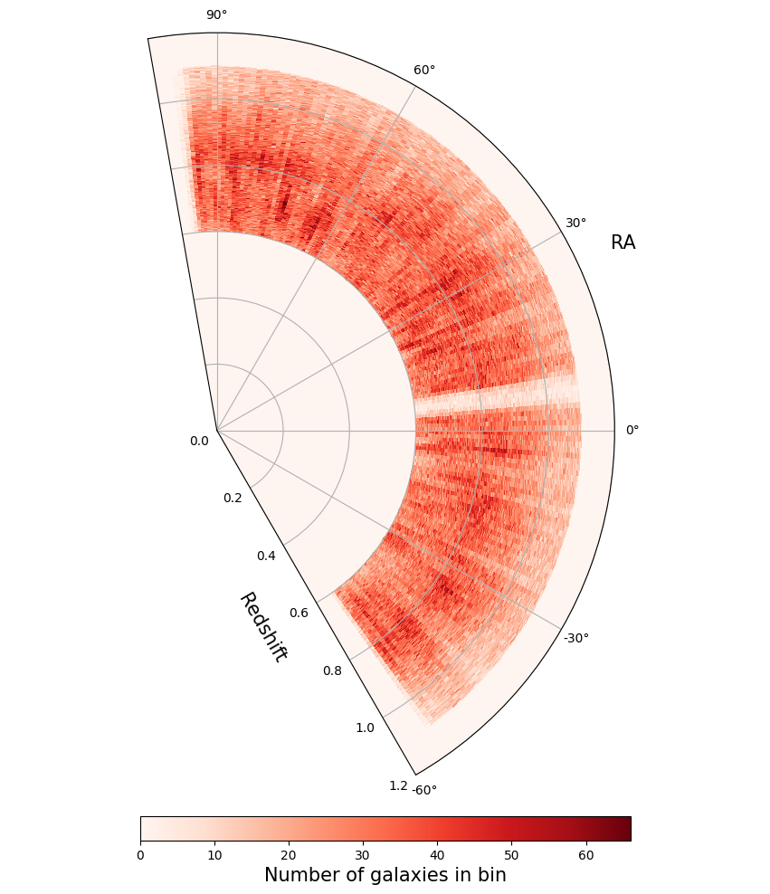

```python
# Create a figure object that we can plot into and set its size
fig = plt.figure(figsize=(10, 10))
# Add an axis object to our figure and set its `projection` to "polar"
# This will render the data we plot as a segment of a ring that starts
# and and at angular positions that we can specify later.
ax = fig.add_subplot(1, 1, 1, projection="polar")

# We will plot the data we selected as a two dimensional histogram.
# First, let's create some new variables to hold the data we
# actually want to plot. We'll start by extracting our selected RA
# values. We use the indexing operator on our table object
# passing the name of the column we want to select it i.e. "RA".
# Then we use the indexing operator again passing our selection array
# of boolean values to select the subset of RA values we want.
ra_degrees = data_table["RA"][selection]

# Our RA values are stored with units of degrees. To plot them, we need to
# convert them to radians. The conversion isn't complicated, but we can make it
# even simpler by using the numpy.deg2rad function.
ra_radians = np.deg2rad(ra_degrees)

# Now let's extract our redshift values. Remember that these are listed in
# the "DNF_ZMEAN_SOF" column. We can extract them in exactly the same
# way we extracted the RA values.
redshifts = data_table["DNF_ZMEAN_SOF"][selection]

# Now we have our data, we can plot them. We'll plot a 2-dimensional
# histogram using the `hist2d` method of our axis object. We will use
# 400 bins in RA spanning the full range of values in our selection.
# For the redshift we will also use 400 bins but we will specify the
# bin boundaries explicitly by passing an array that we generate using
# the numpy linspace function.

# In the "Data analysis part 2: catalogues and spectra" Python video, you saw
# that the hist2d method returns several objects. We will assign them all to
# different variables, but we only need the "graphics" object in this activity.
hist, xbins, ybins, graphics = ax.hist2d(
    # First argument is our array of RA values in radians
    ra_radians,
    # Second argument is our array of redshift values
    redshifts,
    # Third argument specifies how we want to bin the data
    bins=[
        # Use 400 bins in the RA dimension, spanning the full range
        400,
        # Use 400 bins in the redshift dimension with boundaries linearly
        # spaced between 0 and 1.2
        np.linspace(start=0, stop=1.2, num=401),
    ],
    cmap="Reds",
)

# Now we set the range of angular values (in this case RA) to plot.
# We specify a minimum and maximum value, both in degrees. To work out
# which values to choose, we just looked at the footprint sky map in the
# region of the slice we selected.

# The minimum value of RA to plot - you could change this if select a different slice.
ax.set_thetamin(-60)
# The maximum value of RA to plot - you could change this if select a different slice.
ax.set_thetamax(100)

# As an aside, you might be wondering why we have to supply the range of angles to
# display in degrees, when we specified our angular data in radians. There is no physical
# reason for this. It is just a slightly confusing requirement of the matplotlib
# method we're using to make this plot.

# Add a colour bar to our plot. You have seen other examples of this in
# previous Python activities. We have used some of the extra arguments to
# fine tune its appearance and positioning.
cbar = plt.colorbar(
    mappable=graphics, ax=ax, fraction=0.03, orientation="horizontal", pad=0.05
)
# Add a title to our colour bar, explaining what the colours of each bin mean.
cbar.set_label("Number of galaxies in bin", fontsize=15)

# Add axis labels
# We have to do this manually because matplotlib's support for polar axes is a bit limited
ax.text(0.3, 0.15, "Redshift", rotation=-60, transform=ax.transAxes, fontsize=15)
ax.text(0.8, 0.7, "RA", transform=ax.transAxes, fontsize=15)

# Set the tick labels' font size to make them more readable
plt.tick_params(labelsize=10)

# Lay out the plot nicely
plt.tight_layout()
```

For this example, we deliberately chose a slice with a large hole in the coverage at $\alpha\approx7^{\circ}$ and this hole is clearly visible in the redshift plot. However, away from the hole in coverage we can see that the distribution of galaxies is not uniform. There are obvious groups of darker bins that contain more galaxies and lighter bins that contain fewer galaxies. These variations in the number density are indicative of large scale structure in the distribution of galaxies in the survey.

You may wish to include a plot that is similar to this in your final report and you should be able to reuse the majority of the code we've given you.

## Part 4: Detecting the BAO signature

To detect the BAO signature, you will construct a graph of the *angular two-point correlation function*, $\omega(\theta)$. In Chapter 11 of the *Cosmology* textbook, you learned that $\omega(\theta)$ is defined as: \begin{equation} \omega(\theta) = \frac{\langle P(\theta)\rangle}{R(\theta)} - 1 \end{equation} In this expression, $P(\theta)$ is the probability of observing two galaxies separated on the sky by an angle between $\theta$ and $\theta +\delta\theta$ (where $\delta\theta$ represents a small angular step or bin size) and $R(\theta)$ is the probability of observing two galaxies with an angular separation in the same range *if* galaxies were uniformly distributed throughout the Universe and not clustered in any way. When we say that galaxies are uniformly distributed, this means that if we search within any region of space with a specific volume, the probability that it contains a galaxy is independent of its location in the Universe.

When working with real data, it turns out that this simple formula can produce biased estimates of $\omega(\theta)$. To prevent this happening, professional cosmologists normally calculate $\omega(\theta)$ using an alternative formula called the *Landy-Szalay Estimator*, which is expressed mathematically as: \begin{equation} \omega(\theta) = \frac{DD(\theta) - 2fDR(\theta) + f^{2}RR(\theta)}{f^{2}RR(\theta)} \end{equation} The equation for the Landy-Szalay estimator includes four new terms:

1. $DD(\theta)$ is calculated using the real *observed* catalogue of galaxies. It represents the number of pairs of galaxies in the catalogue that have an angular separation between $\theta$ and $\theta +\delta\theta$.
2. $RR(\theta)$ is calculated using a *synthetic* catalogue that spans the same volume of space as the observed catalogue, but contains fake "galaxies" that are uniformly distributed throughout that space. It represents the number of pairs of galaxies in this *synthetic* catalogue that have an angular separation between $\theta$ and $\theta +\delta\theta$.
3. $DR(\theta)$ represents the number of galaxy pairs with angular separations between $\theta$ and $\theta +\delta\theta$ that can be formed by taking one galaxy from the real *observed* catalogue and one galaxy from the *synthetic* catalogue.
4. $f$ is the number of galaxies in the observed catalogue divided by the number of galaxies in the synthetic catalogue. It is common practice to use a synthetic catalogue that contains many more galaxies than the observed one. When we compute $DR(\theta)$ and $RR(\theta)$, having more synthetic galaxies allows more galaxy pair separations to be measured, which reduces the associated statistical uncertainties and ultimately improves the accuracy of the $\omega(\theta)$ estimate.

To fulfil the goals of this activity you will need to calculate $\omega(\theta)$ for subsets of the DES survey catalogue that fall within different redshift ranges that you will need to choose. However, before we can calculate $\omega(\theta)$, we are missing one key ingredient.

### Part 4.1 - Generate a random catalogue

In order to calculate $\omega(\theta)$ using the Landy Szalay estimator we need to be able to compute values for $DR(\theta)$ and $RR(\theta)$ and to do that we need a synthetic catalogue of fake galaxies that are uniformly distributed throughout the same volume of space that was probed by the original DES survey. In this section you will use the survey coverage map to generate the synthetic catalogue we need.

You might think that working out the shape of the volume of the Universe covered by the survey, so that we can fill it with uniformly distributed fake galaxies, is a very difficult task. In general, you would be correct. However, our job is made much easier because the catalogue of observed galaxies we are using was selected to have a special property called *completeness*. If a galaxy survey catalogue is *complete* this means that it is *guaranteed* to contain *all* of the galaxies within the survey volume that fulfil a set of specially chosen criteria based on observable quantities.

The criteria used by the DES team were designed to select a particular population of galaxies. However, the details are quite complicated and we don't need to know them for this activity. For our purposes, we can just assume that any galaxy in the selected population with a redshift between 0.6 and 1.1 and with celestial coordinates that fall within the DES survey is included in the catalogue. That makes the survey volume we need to fill with our fake galaxies look quite simple. For all solid angles within the DES survey footprint, completeness means that the volume extends unbroken between $z=0.6$ and $z=1.1$ without any gaps.

We have created an interactive visualisation of the volume so that you can get a better understanding of its shape. Run the next cell to display the visualisation. Once it appears you can rotate the view by dragging with your mouse or trackpad on the image.

```python
from IPython.display import HTML

HTML("des_volume.html")
```

des_volume.html

Now, remember that the reason we are creating this synthetic catalogue is because we want to calculate $\omega(\theta)$. Although the value we *measure* for $\omega(\theta)$ may depend on the redshifts of the galaxies we consider, the formula that we need to evaluate for the Landy-Szalay estimator does not - it only depends on $\theta$. This means that when we create our synthetic catalogue, we only need to make sure that our fake galaxies, which lie within the survey footprint are uniformly distributed in *angular* space.

We need to be sure that we are accurately measuring the angular distribution of the real galaxies in the DES survey catalogue. We can make that guarantee because the survey catalogue is complete and the survey volume contains no gaps in redshift. If the catalogue was *not* complete we would measure an angular distribution that artificially *appears* to be less dense in places because we would be missing galaxies in some part of the redshift range. We would then have to account for that imperfect redshift coverage when we generated our synthetic catalogue.

#### Part 4.1.1 - Generate a set of uniformly distributed celestial coordinates

In this part you will generate sets of Right Ascension and Declination values to represent the celestial coordinates of the fake galaxies that will form your synthetic catalogue.

To calculate $\omega(\theta)$ correctly, we need to make sure that all the galaxies in our synthetic catalogue fall within the DES survey footprint. We can do this because we have the footprint map provided by the DES survey team. Our strategy will involve finding all of the pixels in the footprint map that have non-zero coverage (i.e. non-zero values in the `COVERAGE_GRIZ` column of the map data table that we loaded from the map FITS file).

For each of these pixels, we will use two `healpy` functions:

1. First, we will use the `nside2resol` function to calculate the angular size of the pixels. Remember that the pixelation of HEALPix maps is specifically designed to make sure that all pixels in the map have the same angular size, so we only need to call this function once.
2. Second we will use the `pix2ang` function to compute the celestial coordinates of each pixel's centre.

Once we know the location and size of each pixel with nonzero coverage we will use the `uniform` function that is provided by the `random` module in the `numpy` package to generate a fixed number of galaxies with celestial coordinates that are uniformly distributed in angular space within each pixel.

Let's start by deciding how many galaxy coordinate pairs to generate for each pixel. We mentioned in the introduction to *Part 4* that the accuracy of our estimate for $\omega(\theta)$ gets better if we use a synthetic catalogue with more entries. However, we will see later that generating too many synthetic galaxies increases the time it takes to compute $RR(\theta)$ and $DR(\theta)$. As a compromise, we will generate a synthetic catalogue that is roughly ten times larger than the original DES survey catalogue. You can experiment with different numbers of synthetic galaxies to see how it changes the results but be aware that if you use too many, it will take a very long time to compute the answer!

```python
# First calculate the average number of galaxies per pixel in the orginal DES survey.
# This is just the length of the survey catalogue table divided by the length of the
# footprint map table (Remember that the footprint map table only contains rows for
# pixels with non-zero coverage). Later we will need an integer value so we use
# the ceil function to round up to the next whole number and the `int` function
# to convert the floating point (real values) number to an integer.
survey_num_per_pixel = int(  # convert to integer
    # use ceil to round up to next whole number
    np.ceil(len(data_table) / len(des_footprint_data))
)  # N galaxies / N pixels

# Set the number of synthetic galaxies to generate for pixels with full coverage to be
# 4 times the average number of galaxies per pixel in the original DES survey.
# Note that because of the way the later code is implemented this actually results in a final
# synthetic catalogue that is around 10 times larger than the original DES catalogue.
synth_num_per_pixel = 4 * survey_num_per_pixel
print("Generate", synth_num_per_pixel, "fake galaxies per pixel.")
```

```
Generate 4 fake galaxies per pixel.
```

Now let's use the `healpy` `nside2resol` function to calculate the angular size of each pixel in the footprint map. The `nside2resol` function *requires* one argument, which is the value of the `nside` parameter that was used to generate the map. We saw in *Part 2* of this activity that `nside=4096` for our footprint map. By default, the `nside2resol` function returns an angular size in radians, but we can modify that behaviour and calculate an angular size in arcminutes by setting the optional `arcmin` argument to `True`. We will be generating celestial coordinates with units of degrees, so it will be convenient to calculate the pixel size in degrees. To do that we just divide the value returned by `nside2resol` by 60.

```python
pixelsize = hp.nside2resol(4096, arcmin=True) / 60  # degrees
```

Our goal is to generate synthetic galaxy coordinates that are uniformly distributed within the DES survey footprint. To achieve this, we will generate a set of uniformly distributed angular offsets from the centre of each pixel with non-zero coverage in the survey footprint map.

To do that we will use the `pixelsize` value we just calculated and the `numpy.random.uniform` function. In the "Working with data in Python" Python skills video, you saw that this function accepts three arguments called `low`, `high` and `size`. The first two arguments specify the lower and upper ends of the range that you want your random numbers to fall within. The `size` argument is used to specify the *shape* of the output array. If we set the `size` argument carefully, we will be able to generate all of the random offsets we need in a single function call, without having to write any loops over pixels or coordinate dimensions. We will set the first two function arguments as follows:

1. We will set the `low` argument to minus half the pixel size. Since our offsets are defined from the pixel centres, they can be both negative and positve. If we set the minimum to be less than this value i.e. more negative, we could generate galaxy locations outside of the pixel whose centre we are offsetting from.
2. Following a similar argument, we will set the `high` argument to plus half the pixel size.

For the `size` argument we will specify a value that generates a three dimensional array of numbers. To enable some subsequent calculations we will interpret the three dimensions of the array as follows

1. The zeroth array dimension will represent the number of galaxies in each pixel, so we will set the size of that dimension equal to the `synth_num_per_pixel` value we calculated earlier.
2. The first array dimension will represent the Right Ascension and Declination values for each galaxy. Since there are two values per galaxy we set the size of the first dimension to 2.
3. The second dimension will represent the number of pixels with non-zero coverage that we are generating galaxies within. This is equal to the number of rows in the footprint map data table which we can compute using Python's builtin `len` function.

Run the next code cell to generate your random galaxy coordinate offsets.

```python
random_offsets = np.random.uniform(
    low=-pixelsize / 2,
    high=pixelsize / 2,
    size=(synth_num_per_pixel, 2, len(des_footprint_data))
).astype(np.float16)
```

Now that we have our coordinate offsets, we need to calculate the coordinates of the pixel centres that we are offsetting from. To calculate those coordinates, we will use the the `healpy` `pix2ang` function. This function requires two arguments.

1. Like many `healpy` functions, `pix2ang` needs to know what value of the `nside` argument was used to generate the footprint map. By now you should be familiar with the fact that this value is `nside=4096`.
2. The second required argument is called `ipix`. It should be a `numpy` array containing the HEALPix mappin numbers (or indices) for the pixels whose coordinates we want to compute. These indices are listed in the `HPIX_4096` column of the footprint map data table.

We also specify values for two optional arguments to `pix2ang`.

1. We set `nest=True` to specify the schema that was used for the footprint map (see Part 2 to remind yourself what this means).
2. By default `pix2ang` will return the pixel coordinates in radians. To override this behaviour and return the pixel coordinates in degrees, we specify `lonlat=True`

Finally, the `pix2ang` function actually returns a Python `tuple` containing two `numpy` arrays corresponding to the RAs and Declinations of all the pixel centres. We immediately convert this tuple to a `numpy` array because this will allow us to quickly combine these coordinates with the random coordinate offsets we computed earlier.

```python
pixel_coords = np.array(  # convert to a numpy array
    hp.pix2ang(  # calculate the coordinates for a set of pixels
        nside=4096,  # The nside value used to generate the footprint map
        ipix=des_footprint_data[
            "HPIX_4096"
        ],  # The pixel indices we need coordinates for
        nest=True,  # Specify that the NEST schema was used to generate the map
        lonlat=True,  # Specify that coordinates in degrees are required.
    ), dtype=np.float16
)
```

So now we have our pixel centre coordinates and our random coordinate offsets within each pixel we can simply add them together using the Python `+` operator to generate our final set of uniformy distributed coordinates. We can only do this so easily because of the way we specified the shape of our random offsets array using the `size` parameter for `np.random.uniform`. In particular, we arranged our data so that the number of elements in the first and second dimensions of our `random_offsets` array equals the number of elements in the zeroth and first dimensions of our `pixel_coords` array.

We can show that this is the case by printing the `shape` attributes of our `pixel_coords` and `random_offsets` arrays. Note how the two right-most numbers match in the two shape descriptions.

```python
print("The shape of `pixel_coords` is", pixel_coords.shape)
print("The shape of `random_offsets` is", random_offsets.shape)
```

```
The shape of `pixel_coords` is (2, 20248610)
The shape of `random_offsets` is (4, 2, 20248610)
```

Run the next cell to add the offsets to the pixel centre coordinates and print out the `shape` attribute of the result.

```python
random_coords = pixel_coords + random_offsets
del pixel_coords, random_offsets
print("The shape of `random_coords` is", random_coords.shape)
```

```
The shape of `random_coords` is (4, 2, 20248610)
```

Notice that after we have computed our `random_coords` array we use the `del` operator to delete the two arrays that we summed together. This is another piece of code (alongside storing numerical data at lower-that-default precision) that designed to save computer memory. We will not need the `pixel_coords` and `random_offsets` arrays again so we can delete them from memory. You will see similar code again later in this notebook.

We see that `random_coords` has the same shape as `random_offsets`. This is expected because each of the offsets was added to exactly one pixel centre coordinate for each of the galaxies we generate in each pixel. However, we don't really need to retain this three dimensional shape to be able to compute $\omega(\theta)$. What we really need is a two-dimensional array that contains the two celetial coordinates for each fake galaxy - we don't need to remember which pixel that galaxy was generated within.

The code in the next cell does exactly what we want. It retains the data in `random_coords` but modifies its shape to produce a two dimensional array comprising a one-dimensional array of RA values as the zeroth element of the zeroth dimension and a one-dimensional array of Declination values as the first element of the zeroth dimension. You don't need to understand what this code is doing. What is impportant is that it reshapes the array without mixing the RA and Declination values. Such mixing could produce coordinates outside of the DES survey footprint or even coordinates that are not valid. For example an invalid coordinate could be generated by swapping an RA value, which can validly be larger than 90 degrees with a declination value, which cannot.

Run the code in the next cell to reshape the array and print its final shape.

```python
reshaped_random_coords = random_coords.swapaxes(0, 1).reshape(2, -1)
del random_coords
print("The shape of `reshaped_random_coords` is", reshaped_random_coords.shape)
```

```
The shape of `reshaped_random_coords` is (2, 80994440)
```

#### Part 4.1.2 - Generate a set of uniformly distributed redshifts

For practical purposes it will be useful to assign our fake galaxies random redshifts that are uniformly distributed between $z=0.6$ and $z=1.1$. This is because later we will divide the observed and synthetic catalogues into bins based on galaxy redshift. If our fake galaxies are uniformly distributed in redshift we will be able to use exactly the same code to bin our real and synthetic galaxy catalogues.

To generate our fake galaxy redshifts we can use the `numpy.random.uniform` function again. This time we will specify that `low=0.6`, `high=1.1` and `size` is equal to the number of galaxy coordinate pairs we generated in *Part 4.1.1*. This number is given by the element of the `shape` attribute of the `random_coords` array with index `1`.

Run the next cell to generate a 1-dimensional array containing the random redshift values we need.

```python
random_redshifts = np.random.uniform(
    low=0.6, high=1.1, size=reshaped_random_coords.shape[1]
).astype(np.float16)
```

#### Part 4.1.3 - Combine our coordinates and reshifts into a synthetic catalogue table

Now just run the code in the next cell, which combines the random galaxy coordinates and redshifts into a single `astropy` `Table` object with three columns that have similar names to the real DES survey catalogue:

1. The `RA` column lists the Right Ascension values for our fake galaxies in degrees.
2. The `DEC` column lists the Declination values for our fake galaxies in degrees.
3. The `Z` column lists the redshift values for our fake galaxies.

The code may take a few seconds to run. It's processing a lot of data so please be patient!

```python
random_table = aptable.Table(
    np.vstack([reshaped_random_coords, random_redshifts]).T, names=["RA", "DEC", "Z"]
)
```

Now that we have created our synthetic galaxy catalogue, we need to check that it looks sensible. To do this we need to modify the example you saw in *Part 3* of this activity to plot the redshifts for one or more slices of the synthetic catalogue data. Compare these plots with equivalents made using the real data and think about the following points:

1. How do the two sets of plots differ?
2. How are the two sets of plots similar?
3. Do the similarities and differences make sense given what you know about the two datasets?

You may wish to check (by choosing appropriate slices of data) whether the celestial coordinate ranges (including any holes) in the DES survey footprint are being reproduced (as they should be) in the synthetic catalogue. You might also want to compare the amount of large scale structure that is evident in the observed and synthetic galaxy distributions. Are any differences as you would expect?

We start by defining a criterion that will select synthetic galaxies in a specific declination range. Compared to the code in *Part 3* all we have changed is the identifier of our data table (we use `random_table` instead of `data_table`) and the identifier to which we assign our selection criterion (We use `random_selection` instead of `selection`). These two differences will propagate into the plotting code. We could have chosen another declination range or a set of ranges in Declination and/or Right Ascension.

```python
random_selection = (random_table["DEC"] < -40) & (random_table["DEC"] > -45)
```

To plot the redshift distribution for our slice we can (again) resuse most of the code from *Part 3*. In addition to the variable identifier changes we have already mentioned, we also need to update the name of the column in our syntetic catalogue that contains the redshift values. In the real DES survey catalogue this was called `DNF_ZMEAN_SOF`. In the synthetic catalogue the column is simply named `Z`.

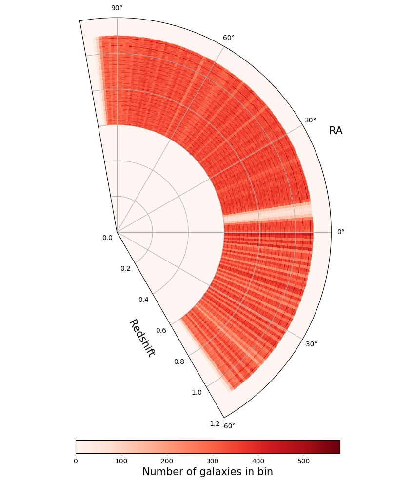

```python
# Create a figure object that we can plot into and set its size
fig = plt.figure(figsize=(10, 10))
# Add an axis object to our figure and set its `projection` to "polar"
# This will render the data we plot as a segment of a ring that starts
# and ends at angular positions that we can specify later.
ax = fig.add_subplot(1, 1, 1, projection="polar")

# We will plot the data we selected as a two dimensional histogram,
# but first, let's create some new variables to hold the data we
# actually want to plot. We'll start by extracting our selected RA
# values. First we use the indexing operator on our table object
# passing the name of the column we want to select it i.e. "RA".
# Then we use the indexing operator again passing our selection array
# of boolean values to select the subset of RA values we want.
ra_degrees = random_table["RA"][random_selection]

# Our RA values are stored with units of degrees. To plot them, we need to
# convert them to radians. The conversion isn't complicated, but we can make it
# even simpler by using the numpy.deg2rad function.
ra_radians = np.deg2rad(ra_degrees)

# Now let's extract our redshift values. Remember that these are listed in
# the "Z" column (Note that this is different to the column name used in the
# real DES survey catalogue. We can extract them in exactly the same
# way we extracted the RA values.
redshifts = random_table["Z"][random_selection]

# Now we have our data, we can plot them. We'll plot a 2-dimensional
# histogram using the `hist2d` method of our axis object. We will use
# 400 bins in RA spanning the full range of values in our selection.
# For the redshift we will also use 400 bins but we will specify the
# bin boundaries explicitly by passing an array that we generate using
# the numpy linspace function.

# In the "Data analysis part 2: catalogues and spectra" Python video, you saw
# that the hist2d method returns several objects. We will assign them all to
# different variables, but we only need the "graphics" object in this activity.
hist, xbins, ybins, graphics = ax.hist2d(
    # First argument is our array of RA values in radians
    ra_radians,
    # Second argument is our array of redshift values
    redshifts,
    # Third argument specifies how we want to bin the data
    bins=[
        # Use 400 bins in the RA dimension, spanning the full range
        400,
        # Use 400 bins in the Redshift dimension with boundaries linearly
        # spaced between 0 and 1.2
        np.linspace(start=0, stop=1.2, num=401),
    ],
    cmap="Reds",
)

# Now we set the range of angular values (in this case RA) to plot.
# We specify a minimum and maximum value, both in degrees. To work out
# which values to choose, we just looked at the footprint sky map in the
# region of the slice we selected.

# The minimum value of RA to plot - you could change this if select a different slice.
ax.set_thetamin(-60)
# The maximum value of RA to plot - you could change this if select a different slice.
ax.set_thetamax(100)

# Add a colour bar to our plot. You have seen other examples of this in
# previous Python activities. We have used some of the extra arguments to
# fine tune its appearance and positioning.
cbar = plt.colorbar(
    mappable=graphics, ax=ax, fraction=0.03, orientation="horizontal", pad=0.05
)
# Add a title to our colour bar, explaining what the colours of each bin mean.
cbar.set_label("Number of galaxies in bin", fontsize=15)

# Add axis labels
# We have to do this manually because matplotlib's support for polar axes is a bit limited
ax.text(0.3, 0.15, "Redshift", rotation=-60, transform=ax.transAxes, fontsize=15)
ax.text(0.8, 0.7, "RA", transform=ax.transAxes, fontsize=15)

# Set the tick labels' font size to make them more readable
plt.tick_params(labelsize=10)

# Lay out the plot nicely
plt.tight_layout()
```

Comparing the plots generated from the real and synthetic catalogues, we observe that:

1. The ranges of RA and Declination (including any holes) spanned by the two catalogues are identical. This is as we would expect becuase we specifically designed our synthetic catalogue to contain galaxies that occupy the same footprint on the sky as those in the real DES survey catalogue.
2. The synthetic catalogue *does not* show the same large scale structure that we observed when we plotted the real catalogue. This is good news! It shows that our synthetic does indeed contain galaxies that are uniformly distributed in angular *and* redshift space. Comparing the two plots actually makes the structure in the real data much more obvious.
3. The synthetic catalogue plot shows a radiating pattern of darker and lighter stripes. These are also visible in the observed catalogue plots, but the large scale structure in those plots makes them harder to see. The striped pattern highlights the small variations in the DES survey coverage and show that our synthetic catalogue has accurately captured them.
4. The average number of galaxies per bin is higher in the synthetic catalogue histogram. This is what we would expect. After all we deliberately generated a synthetic catalogue that was larger that the one containing real observational data.

## Part 5: Computing $\omega(\theta)$

Now we finally have all the data we need to compute $\omega(\theta)$ and to try to detect the BAO signal.

Before we do that though, let's recall what you read about BAOs in Chapter 11 of the *Cosmology* textbook. The BAO signal is expected to show an overabundance of large scale structures with **co-moving** sizes of about 150 megaparsecs. However, we do not measure the comoving size of the BAO signal, we measure the physical (proper) size which changes as the Universe expands.

If we calculated $\omega(\theta)$ using the positions of *all* of our observed and synthetic galaxies, then we would measure a smeared out superposition of BAO signals with different physical sizes, corresponding to galaxies in different reshift ranges. To reduce this smearing effect as much as possible, your task will be to measure $\omega(\theta)$ using subsets of the observed and synthetic galaxies, separated into bins of redshift.

We will show you how to calculate $\omega(\theta)$ for one redshift bin. Your task will then be to choose several other redshift bins and compute $\omega(\theta)$ for the observed and synthetic galaxies they contain. Once we have computed $\omega(\theta)$ for a range of values of $\theta$ we will fit a simple function to the data to determine the location of the BAO peak in a particular redshift bin.

Your final task for the activity will be to check whether or not your **measured** peak locations at different redshifts correspond with the expected **co-moving** size of the BAO feature.

### Part 5.1 - Selecting a subset of galaxies in a specific redshift bin

Let's start by defining a function to select galaxies within a particular redshift bin. Our function will accept four arguments:

1. `data` - This will be the `astropy.Table` object containing *either* our observational or synthetic galaxy catalogue.
2. `z_min` - A number specifying the lower edge of our redshift bin.
3. `z_max` - A number specifying the upper edge of our redshift bin.
4. `z_column` - The name of the column in our catalogue table containing the redshift values for our galaxies. In the observational data table, this column is called `DNF_ZMEAN_SOF`. In the synthetic catalogue table it is just called `Z`.

Our function will then use a `numpy` expression to identify all galaxies in our `data` catalogue that have redhsifts greater than `z_min` *and* (`&`) less than `z_max`. Once the galaxies have been identified, the function will extract them from the `data` table using the `numpy` indexing operator and return them to the caller.

```python
# A function to select galaxies within a specified range of redshifts
def select_z_bin(
    data,  # astropy.Table containing the galaxy catalogue
    z_min,  # minimum redshift to extract
    z_max,  # maximum redshift to extract
    z_column,  # column containing the galaxy redshift data
):
    # Use numpy syntax to define a selection criterion
    selection_criterion = (data[z_column] > z_min) & (data[z_column] < z_max)
    # Apply the criterion to select the galaxies that we want
    selection = data[selection_criterion]
    # Return our selection
    return selection
```

Now let's define the upper and lower bounds of our redshift bin. For this sample we will use galaxies with redshifts between 0.60 and 0.70.

```python
# create five empty lists to store data about redshift bins and BAO data in each bin
z_min_vals, z_max_vals, z_mean_vals, bao_locs, bao_loc_errors = [], [], [], [], []
```

As we work through the remainder of this activity we will append values to these lists as we compute them. At this point, we can immediately append the minimjum and maximum redshifts of this bin to the `z_min_vals` and `z_max_vals` lists.

```python
z_min = 0.60
z_max = 0.70
```

```python
# append the minimum redshift of the galaxies in this bin
z_min_vals.append(z_min)
# append the maximum redshift of the galaxies in this bin
z_max_vals.append(z_max)
```

Now we call our `select_z_bin` twice to extract subsets of our observed and synthetic galaxy catalogues that fall into our chosen redshift bin.

```python
# Select a redshift-limited subset from the observed catalogue
data_selection = select_z_bin(data_table, z_min, z_max, "DNF_ZMEAN_SOF")
# Select a redshift-limited subset from the synthetic catalogue
random_selection = select_z_bin(random_table, z_min, z_max, "Z")
```

### Part 5.2 - Performing the computation :

Run the next cell to import the `treecorr` package and give it the shorthand alias `tc`.

```python
import treecorr as tc
```

Calculating $\omega(\theta)$ using `treecorr` entails four steps:

1. First we need to create special `treecorr.Catalog` (which we can write as `tc.Catalog` because we used an alias in our import statement) objects that store our catalogue data in a format that makes it easier to efficiently compute the galaxy pair counts we need. We will create one `treecorr.Catalog` for the observed survey catalogue and a second one for the synthetic galaxy catalogue.

   To create a `treecorr.Catalog` object to represent the DES survey, we need use a special function called a "constructor". The constructor has the same name as the type of object we are trying to create - in this case `tc.Catalog`. We extract the columns containing celestial coordinates of the galaxies in the DES survey from the catalogue table, convert them to `numpy.array`s and then pass them to our constructor. We also use two optional arguments to specify that our coordinates have units of degrees.

   The final argument we pass to the constructor is called `npatch` and it is used by `treecorr` to divide galaxies in our catalogue into separate patches on the sky. Doing this allows `treecorr` to estimate the variance associated with the $\omega(\theta)$ values it calculates. Rather than just considering the whole catalogue (observed or synthetic, as appropriate) when counting pairs, `treecorr` also counts pairs and calculates $\omega(\theta)$ within each of the patches. The measured scatter between the different patches provides a more accurate estimate of the overall variance associated with $\omega(\theta)$ for the whole catalogue. We will use 20 patches in this example. If you have time, you could experiment with different numbers of patches to see what effect that has on the variance estimates, but 20 seems to work well in our experiments.

   We assign the identifier `data_cat` to the `Catalog` object we create.

```python
data_cat = tc.Catalog(
    ra=np.array(
        data_selection["RA"], dtype=np.float16
    ),  # Right ascensions of our galaxies - just a column from the catalogue table
    dec=np.array(
        data_selection["DEC"], dtype=np.float16
    ),  # Declinations of our galaxies - just a column from the catalogue table
    ra_units="degrees",  # The units used for RA - degrees
    dec_units="degrees",  # The units used for Declination - degrees
    npatch=20,  # Count pairs within 20 separate patches to calculate a variance estimate
)
```

To create a `treecor.Catalog` object to represent our synthetic galaxy catalogue, we call the constructor function again and pass equivalent values for the first four arguments. The difference is in the fifth argument. We want our synthetic galaxy catalogue to use exactly the same patches as the DES survey catalogue object, so instead of passing a value for `n_patch` we use a different argument called `patch_centers` and pass it the patch centres that were calculated for the `Catalog` object that represents the DES survey data. This is stored as the `patch_centres` attribute of the `data_cat` object we created in the previous cell.

We assign the identifier `random_cat` to the `Catalog` object we create for the synthetic catalogue.

```python
random_cat = tc.Catalog(
    ra=np.array(
        random_selection["RA"], dtype=np.float16
    ),  # Right ascensions of our galaxies - just a column from the catalogue table
    dec=np.array(
        random_selection["DEC"], dtype=np.float16
    ),  # Declinations of our galaxies - just a column from the catalogue table
    ra_units="degrees",  # The units used for RA - degrees
    dec_units="degrees",  # The units used for Declination - degrees
    patch_centers=data_cat.patch_centers,  # Use the patches that were calculated for the DES survey catalogue
)
```

2. Second we need to create some objects that will actually do the pair counting for us. The `treecor` package provides the `NNCorrelation` class for this purpose. We will create three `NNCorrelation` objects, and set them up independently calculate $DD(\theta)$, $DR(\theta)$ and $RR(\theta)$.

   The `NNCorrelation` constructor accepts a lot of arguments to fine-tune its behaviour. We will only use a 7 of them. The first five define the bins in $\theta$-space that we want to calculate $\omega(\theta)$ for.
   1. `min_sep` specifies the minimum value of $\theta$ that we want to consider. It specifies the lower boundary of the lowest $\theta$ bin in degrees. We choose a value of 0.5 degrees in this example.
   2. `max_sep` specifies the maximum value of $\theta$ that we want to consider. It specifies the upper boundary of the highest $\theta$ bin in degrees. We choose a value of 5 degrees in this example.
   3. `bin_size` specifies the width of the $\theta$ bins. It is equivalent to what we have denoted $\delta\theta$ in the introduction to Part 4 of this activity. We have chosen to calculate $\omega(\theta)$ within quite narrow bins with width 0.05 degrees. Later we will combine the results from multiple bins to make the BAO signals more obvious and easier to fit.
   4. `bin_type` - We specify that we want the bin boundaries to be equidistant in linear space. This is the same as using the `numpy.linspace` function. We have to provide this argument becsaue `treecor`'s default mode is to use bins that are equidistant in logarithmic space, like using the `numpy.logspace` function.
   5. `sep_units` - This is used to tell `treecorr` what angular units our binning specifications use. In this case, we are using degrees.

   The sixth argument that we need to pass is called `bin_slop`. This argument controls the trade-off between the speed and the accuracy of `treecorr`'s pair counting algorithm. We have found that setting `bin_slop=0.02` provides good results and allows $DR(\theta)$ and $RR(\theta)$ to be calcuated within a few minutes (rather than hours if set to 0!)

   The final argument that we need to set is called `var_method`. This tells `treecorr` how to calculate the variance for our $\omega(\theta)$ measurement. We specify the`"jackknife"` method. If you'd like to know more information about this method you can consult the `treecorr` documentation.

   Run the next three cells to create the `NNCorrelation` objects that we need.

```python
# This NNCorrelation object will compute DD(theta)
dd = tc.NNCorrelation(
    min_sep=0.5,
    max_sep=5.0,
    bin_size=0.05,
    bin_type="Linear",
    sep_units="degrees",
    bin_slop=0.02,  # Specifying bin_slop=0.02 results in a small loss of precision but is much faster
    var_method="jackknife",
)
```

```python
# This NNCorrelation object will compute RR(theta)
rr = tc.NNCorrelation(
    min_sep=0.5,
    max_sep=5.0,
    bin_size=0.05,
    bin_type="Linear",
    sep_units="degrees",
    bin_slop=0.02,  # Specifying bin_slop=0.02 results in a small loss of precision but is much faster
    var_method="jackknife",
)
```

```python
# This NNCorrelation object will compute DR(theta)
dr = tc.NNCorrelation(
    min_sep=0.5,
    max_sep=5.0,
    bin_size=0.05,
    bin_type="Linear",
    sep_units="degrees",
    bin_slop=0.02,  # Specifying bin_slop=0.02 results in a small loss of precision but is much faster
    var_method="jackknife",
)
```

3. Third we need to call the `process()` method of each of our `NNCorrelation` objects, which triggers them to execute the pair count. Even using `treecorr`'s much more efficient algorithm this process can take a few minutes.

   The `process` method accepts one *or* two arguments. When we compute $DD(\theta)$ and $RR(\theta)$ we are comparing the same catalogue against itself when counting galaxy pairs. In that case we only pass one argument which is the identifier we assigned to the `treecorr.Catalog` we created to represent the single catalogue that we are comparing with itself. In contrast, computing $DR(\theta)$ requires comparison of two catalogues and so we must pass the identifiers of both our `treecorr.Catalog` objects.

```python
# Actually calculate DD(theta) - we only need to pass the DES survey catalogue
dd.process(data_cat)
```

```python
# Actually calculate RR(theta) - we only need to pass the synthetic catalogue
# Note that this is the most time consuming operation in this activity - it can take
# several minutes to complete.
rr.process(random_cat)
```

```python
# Actually calculate DR(theta) - we need to pass both catalogues
dr.process(data_cat, random_cat)
```

4. Finally, we call the `calculateXi` method of the `NNCorrelation` object that we set up to calculate $DD(\theta)$. We pass the other two `NNCorrelation` objects as arguments to this method, which then calculates $\omega(\theta)$ and its variance.

```python
omega, omega_variance = dd.calculateXi(rr=rr, dr=dr)
```

### Part 5.3 - Plotting the results

We have now calculated our estimate of $\omega(\theta)$ and its variance for the DES survey! Let's plot the results. First, we'll get an array to represent the centres of the bins in $\theta$ that we calculated $\omega(\theta)$ for. We could compute this using the `numpy.linspace` function, but in fact `treecorr` has saved us the effort. The array we need is stored as the `rnom` attribute of the `NNCorrelation` object we used to calculate $DD(\theta)$. We'll just assign it a more meaningful identifier - `theta` - that we can use for the rest of the activity.

```python
theta = dd.rnom
```

Now let's use `matplotlib` to plot $\omega(\theta)$ and its associated errors versus $\theta$.

We'll create a figure and attach some axes to it. Then we'll use the `errorbar` method of our axes to plot our results. We'll also set our axes to display the $\theta$ and $\omega(\theta)$ with logarithmic scales. This will help us decide what type of function to fit to our results when we try to find the location of the BAO peak later on. Finally we'll set some titles for our axes and tidy up our plot using the `tight_layout` function provided by the `matplotlib.pyplot` module (which we aliased as `plt` right at the beginning of this activity).

Note that we use the square root of the variance of $\omega(\theta)$ as the size of our error bars. We are assuming that the uncertainties have a symmetric, Gaussian distribution, and so this corresponds to the standard deviation.

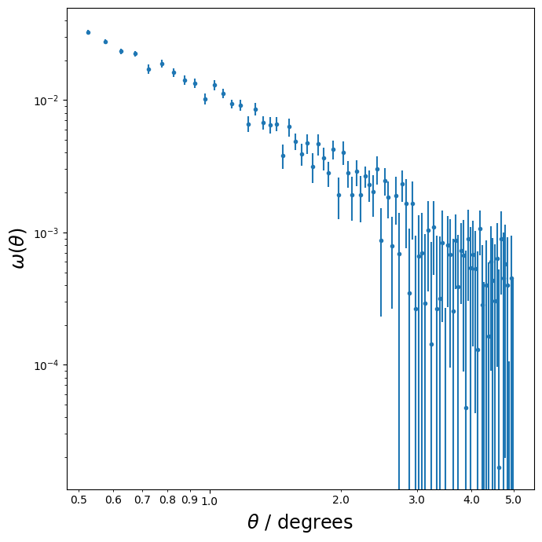

```python
# Create a figure
fig = plt.figure(figsize=(7, 7))

# Create a set of axes attached to our figure
ax = fig.add_subplot(1, 1, 1)

# Use the errorbar() method to plot the data
ax.errorbar(
    theta,  # The array of theta values calculated by treecorr
    omega,  # The array of omega values calculated by treecorr
    yerr=np.sqrt(
        omega_variance
    ),  # The square root variance values calculated by treecorr
    linestyle="none",  # Don't draw a line between the points on our plot
    marker="o",  # Use a circular marker style
    markersize=3,  # Set a marker size slightly smaller than the default (which is 5)
)

# Set the x and y axes to display logarithmic scales
ax.set_yscale("log")
ax.set_xscale("log")

# Fiddly formatting to improve the x-axis labels
from matplotlib import ticker
ax.xaxis.set_major_formatter(ticker.StrMethodFormatter('{x:.1f}'))
ax.xaxis.set_minor_formatter(ticker.StrMethodFormatter('{x:.1f}'))

# Set the x and y axes' titles
ax.set_ylabel(r"$\omega(\theta)$", fontsize="xx-large")
ax.set_xlabel(r"$\theta$ / degrees", fontsize="xx-large")

# Tidy up the plot
plt.tight_layout()

plt.savefig("0.6-0.7_Plot1.png")
```

To try to make the features more obvious, we will rebin our data.

To make this simple, we have written a function that accepts three arrays containing the `theta`, `omega`, `omega_variance` and rebins them by combining sets of 5 adjacent points.

```python
def rebin(theta, omega, omega_variance, points_to_combine=5):
    rebinned = np.array(
        [
            [
                theta[start : start + points_to_combine].mean(),
                omega[start : start + points_to_combine].mean(),
                omega_variance[start : start + points_to_combine].sum()
                / points_to_combine**2,
            ]
            for start in range(0, dd.rnom.size, points_to_combine)
        ]
    ).T
    return rebinned
```

You don't need to understand how this function works (although if you enjoy Python you might like to try to work it out). We will demonstrate how to call the function in the next cell.

```python
# Rebin the correlation function data using our `rebin` function
# The function returns three arrays containing our rebinned data.
theta_rebinned, omega_rebinned, omega_var_rebinned = rebin(
    theta, omega, omega_variance, 5
)
```

The next cell plots the rebinned data.

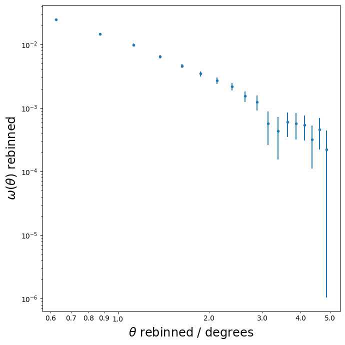

```python
# Create a figure
fig = plt.figure(figsize=(7, 7))

# Create a set of axes attached to our figure
ax = fig.add_subplot(1, 1, 1)

# Use the errorbar() method to plot the data
ax.errorbar(
    theta_rebinned,  # The array of rebinned theta values
    omega_rebinned,  # The array of rebinned omega values
    yerr=np.sqrt(omega_var_rebinned),  # The square root of the rebinned variance values
    linestyle="none",  # Don't draw a line between the points on our plot
    marker="o",  # Use a circular marker style
    markersize=3,  # Set a marker size slightly smaller than the default (which is 5)
)

# Set the x and y axes to display logarithmic scales
ax.set_yscale("log")
ax.set_xscale("log")

# Fiddly formatting to improve the x-axis labels
from matplotlib import ticker
ax.xaxis.set_major_formatter(ticker.StrMethodFormatter('{x:.1f}'))
ax.xaxis.set_minor_formatter(ticker.StrMethodFormatter('{x:.1f}'))

# Set the x and y axes' titles
ax.set_ylabel(r"$\omega(\theta)$ rebinned", fontsize="xx-large")
ax.set_xlabel(r"$\theta$ rebinned / degrees", fontsize="xx-large")

# Tidy up the plot
plt.tight_layout()

plt.savefig("0.6-0.7_Plot2.png")
```

## Part 6: Estimating the angular scale of the BAO signal

In this part, we will use a Python package called `iminuit` to fit an analytic function to the $\omega(\theta)$. The best fit parameters of our function will allow us to estimate the angular scale of the BAO signal. The `iminuit` package provides a `minimize` function that behaves just like the `scipy.optimize.minimize` function that you learned about in the "Python tools for cosmology and astrophysics" Python skills video. The reason we use it in this activity is that it provides additional, useful tools for calculating the uncertainties on the fitted model parameters.

1. A broken power law component (i.e. a power law that changes slope at a "break"), which we later refer to as the "continuum" model and can be written as \begin{equation} \begin{split} f_\text{BPL}(\theta) = \left \{ \begin{array}{ll} N_\text{BPL}\cdot(\theta / \theta_\text{break}) ^ {-\alpha_1} & : \theta < \theta_\text{break} \\ N_\text{BPL}\cdot(\theta / \theta_\text{break}) ^ {-\alpha_2} & : \theta \ge \theta_\text{break} \\ \end{array} \right. \end{split} \end{equation} This component of our model has four parameters that we can fit:
   1. $N_\text{BPL}$ is a normalisation term that sets the value of $f_\text{PL}$ at $\theta=\theta_\text{break}$.
   2. $\theta_\text{break}$ is the value of theta at which the power-law slope changes (or "breaks").
   3. $\alpha_{1}$ is the power law index that corresponds to the gradient of the power law for $\theta < \theta_\text{break}$, in logarithmic space.
   4. $\alpha_{2}$ is the power law index that corresponds to the gradient of the power law for $\theta > \theta_\text{break}$, in logarithmic space.

   We do not intend to interpret the best fitting parameters of this component physically. It needs to be flexible enough to model the background onto which the BAO signal is superimposed, but simple enough that we can constrain it using the data we have available.
2. A gaussian component that models the shape of the BAO signal (i.e., the bump): \begin{equation} f_\text{BAO}(\theta)=N_\text{BAO}\exp\left[-\left(\frac{\theta - \theta_\text{BAO}}{\sigma_{BAO}}\right)^{2}\right] \end{equation} This component has three parameters that we can fit:
   1. $N_\text{BAO}$ is a normalisation term that determines the *area* of the gaussian model for the BAO feature.
   2. $\theta_\text{BAO}$ represents the mean of the gaussian which corresponds with the angular scale of the BAO signal. **This is the parameter that we want to measure!**
   3. $\sigma_{BAO}$ represents the standard deviation of the gaussian component, which corresponds with the width of the BAO signal feature.

Our combined model will just be the sum of these two components: \begin{equation} f_\text{combined}(\theta, \Theta) = f_\text{BPL}(\theta) + f_\text{BAO}(\theta) \end{equation} where capital theta ($\Theta$) represents a vector containing the seven parameters of our combined model that we need to fit using our data.

### Part 6.1 - Implementing our combined model function $f_\text{combined}$

Now let's write some Python code that calculates $f_\text{combined}(\theta, \Theta)$ when given one or more values for $\theta$. We will write three functions:

1. A function called `bkn_powerlaw` that computes an array of $f_\text{BPL}(\theta)$ values, when given scalar values for $N_\text{BPL}$, $\alpha_1$, $\alpha_2$, $\theta_\text{break}$ and an array of $\theta$ values.
2. A function called `gaussian` that computes an array of $f_\text{BAO}(\theta)$, when given scalar values for $N_\text{BAO}$, $\theta_\text{BAO}$, $\sigma_{BAO}$ and an array of $\theta$.
3. A function called `model` that receives an array of $\theta$ values and the full parameter array, $\Theta$. The function will extract the individual parameter values, pass appropriate subsets of those values along with the $\theta$ array to the `bkn_powerlaw` and `gaussian` functions, and finally return the sum of the arrays of values that `bkn_powerlaw` and `gaussian` return. This function serves the same purpose as the function called "model_function" in the Python toolkit notebook example of model fitting.

All of these functions are defined in the next cell. We have added comments to the code to help you understand what it is doing. Please read them carefully, particularly for the `model` function.

```python
# Function to compute the broken power law component
def bkn_powerlaw(
    theta,  # numpy array of theta values
    norm,  # power law normalisation
    index_below,  # power law index below the break
    index_above,  # power law index above the break
    theta_break,  # angular separation at which the power law breaks
):
    # compute and return the values of the broken power law component using
    # the numpy.where function
    return np.where(
        # A boolean array True at positions where theta < theta_break
        # and False otherwise
        theta < theta_break,
        # An array of values to choose if the corresponding element of
        # the first argument is True i.e. for values of theta below
        # theta_break
        norm * (theta / theta_break) ** index_below,
        # An array of values to choose if the corresponding element of
        # the first argument is False i.e. for values of theta above
        # or equal to theta_break
        norm * (theta / theta_break) ** index_above,
    )


# Function to compute the gaussian component
def gaussian(
    theta,  # numpy array of theta values
    mean,  # gaussian mean
    sigma,  # gaussian sigma (standard deviation)
    norm,  # gaussian normalisation
):
    # compute and return the values of the gaussian component
    return norm * np.exp(-(((theta - mean) / sigma) ** 2))


# Function to compute the combined model
def model(
    theta,  # numpy array of theta values
    model_params,  # array of all 5 model parameters
):
    # extract the individual model parameters.
    # note that we expect them to be in a specific order and we will
    # need to be aware of this when we use the iminuit.minimize
    # function
    (
        bao_norm,
        bao_location,
        bao_sigma,
        pl_index_1,
        pl_index_2,
        pl_norm,
        pl_break,
    ) = model_params

    # compute the values of the power law components and store the results
    # power_law_1 = powerlaw(theta, pl_norm_1, pl_index_1)
    # power_law_2 = powerlaw(theta, pl_norm_2, pl_index_2)
    broken_powerlaw = bkn_powerlaw(theta, pl_norm, pl_index_1, pl_index_2, pl_break)
    # compute the values of the gaussian component and store the result
    bao_signal = gaussian(theta, bao_location, bao_sigma, bao_norm)

    # compute the combined model values by summing the two component arrays
    model = broken_powerlaw + bao_signal

    # return the combined model values
    return model
```

### Part 6.2 - Fitting the model to the measured $\omega(\theta)$ values

Now that we have defined our model function we can use the `iminuit.minimize` function to fit the model to our data. Run the next cell to import the `iminuit` package and give it the short alias `imin`.

```python
import iminuit as imin
```

To use the `iminuit.minimize` function we need to write one more function. This function will accept a trial set of model parameters, our measured $\omega(\theta)$ values and the values of $\theta$ at which they were measured. The function needs to compute and return a quantity that is guaranteed to be smaller for trial parameters that produce a model that fits the data better - this function will serve the same purpose as the function called "fit_function" in the Python toolkit model fitting example.

One quantity that has this property may be familiar to you. It is called the *Chi-Square* ($\chi^{2}$) statistic, it is a function of the model parameters ($\Theta$) and can be written mathematically as: \begin{equation} \chi^{2}(\Theta, \theta) = \sum_{\theta}\left(\frac{\omega(\theta) - f(\theta, \Theta)}{\sigma_{\omega}(\theta)}\right)^{2} \end{equation} where $\sigma_{\omega}^{2}(\theta)$ represents the variance associated with $\omega(\theta)$.

In the next cell, we define our fit function to compute the $\chi^{2}$ statistic given a set of model parameters $\Theta$ and a two-dimensional array containing measured values for $\theta$, $\omega(\theta)$ and $\sigma_{\omega}(\theta)$.

We have added comments to the code to help you understand what it is doing. Please read them carefully.

```python
# Fit function that computes the chi-square statistic
def fit_function(model_params, *data):
    # unpack the 2-dimensional data array into three separate data arrays.
    # note that we expect them to be in a specific order and we will
    # need to be aware of this when we use the iminuit.minimize
    # function
    theta, omega, omega_errors = data

    # call the model function to compute values of the combined model
    # given an array of theta values and the set of model parameters
    # that was passed to this function.
    model_omega = model(theta, model_params)

    # compute the chi-square statistic
    chi_square = (((omega - model_omega) / omega_errors) ** 2).sum()

    # return the computed chi_square statistic
    return chi_square
```

Now that we have defined a function that is guaranteed to return a smaller value for trial parameters that produce a model that fits the data better, we can use the `iminuit.minimize` function to search for a set of model parameters that produce the smallest possible $\chi^{2}$ value, given our measured data.

We need to provide five arguments to the minimize function. The first three are the same as in the Python toolkit example for `scipy.optimize`.

1. The first argument is just the identifier of the function that we want to minimize the output for. For us, this is the `fit_function` function that we just defined. Notice that we just pass the identifier of the function without any parentheses i.e `()` and we don't need to create a string by wrapping the identifier in `"` characters.
2. The second argument is called `x0` and it should be a Python list containing seven elements that represent *initial guesses* for the model parameters. It is important that these elements are in the order that is expected by our `model` function when it unpacks them. If you don't remember this order, go back and look again at the code and comments in our definition of the `model` function.
3. The third argument that we will pass is called `args`. We use `args` to pass a list containing our data arrays. These arrays should be in the order that is expected by our `fit_function` function when it unpacks them. If you don't remember this order, go back and look again at the code and comments in our definition of the `fit_function` function.
4. The fourth argument that we will pass is called `bounds`. This is a list containing 7 two-element lists, which can be used to nudge the fitting function to find a good result by telling it only to look within a certain range of values for each parameter. In each of the 7 two-element lists the zeroth and first elements represent the minimum and maximum values (or "bounds") that a model parameter can have. The bounds for each parameter should be listed at the same position in the `bounds` array that the initial guess for that parameter's value appears in the `x0` array. Restricting the range of parameter values in this way can help the `minimize` function to find a best fit solution that makes physical sense.
5. The final argument is called `options`. We pass a Python `dict` containing extra arguments that are used to fine tune the operation of the `minimize` function. You don't need to understand what these extra arguments mean and you should not need to modify them. We have found that they almost always result in the minimizer converging to a good solution.

Now that we understand what inputs the `minimize` function requires, we can see that we still need to define some values to proivde as the `x0` and `bounds` arguments.

Let's start with `x0` and set up some initial guesses for each of the model parameters. To do this, we need to inspect our plots of $\omega(\theta)$ and consider the descriptions of each of the model parameters at the beginning of this part of the activity (go back and read them if you have forgotten exactly what the parameters mean).

Later in this activity you will be asked to repeat this step for values of $\omega(\theta)$ calculated using galaxies in a different redshift range. At that point you may need to adjust your initial guesses, especially if the data you are trying to fit looks very different.

Run the code in the next cell to set up an array called `initial_parameter_guesses` that contains appropriate values for this example. Compare the guesses with the plot of $\omega(\theta)$ and try to convince yourself that the guesses make sense. You are free to choose some different initial guesses, but be careful! If you pick values that are too far from the best fitting set to start from, the fitter may not converge properly on the right solution.

```python
# final guesses for parameters
bao_norm = 1.0e-5    # normalisation of the gaussian BAO signal component
bao_location = 2.5  # mean of the gaussian BAO signal component
bao_sigma = 1.1     # sigma of the gaussian BAO signal component
pl_index_1 = -1.85  # index of the broken power law component below the break
pl_index_2 = -1.85  # index of the broken power law component above the break
pl_norm = 0.9e-3    # normalisation of the broken power law component
pl_break = 3.8      # value of theta at which the power law breaks


# collect the initial parameter guesses together into a numpy array in the
# order that is expected by our `model` function.
initial_parameter_guesses = np.array(
    [bao_norm, bao_location, bao_sigma, pl_index_1, pl_index_2, pl_norm, pl_break]
)
```

To check whether our parameter guesses produce an initial model that fits the calculated $\omega(\theta)$ points reasonably well, let's plot the initial model and data on the same set of axes. The next cell plots:

1. The rebinned correlation function and its associated errors.
2. The full model corresponding with our initial paramter value guesses.
3. The broken power law continuum component of our model corresponding with our initial paramter value guesses.

Run the next cell to generate the plot.

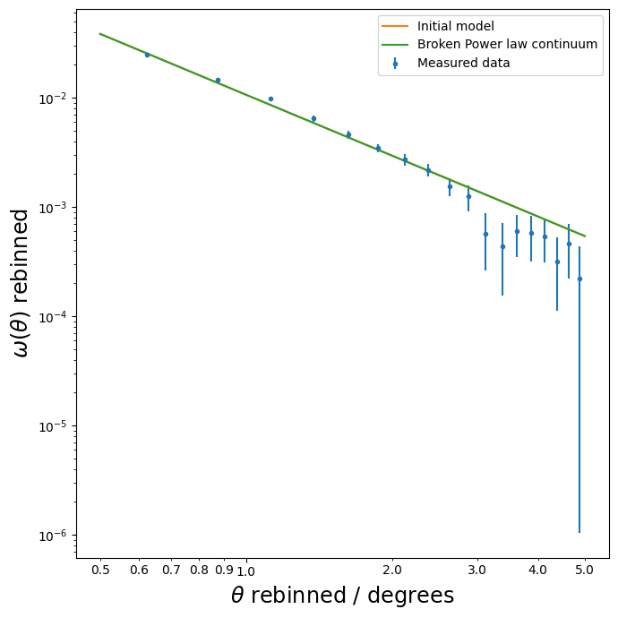

```python
# Create a figure
fig = plt.figure(figsize=(7, 7))

# Create a set of axes attached to our figure
ax = fig.add_subplot(1, 1, 1)

# Use the errorbar() method to plot the data
ax.errorbar(
    theta_rebinned,  # The array of rebinned theta values
    omega_rebinned,  # The array of rebinned omega values
    yerr=np.sqrt(omega_var_rebinned),  # The square root of the rebinned variance values
    linestyle="none",  # Don't draw a line between the points on our plot
    marker="o",  # Use a circular marker style
    markersize=3,  # Set a marker size slightly smaller than the default (which is 5)
    label="Measured data",  # Add a label that will be shown in the legend for this plot
)

# Use the `numpy.linspace` function to define a range of theta
# values at which to compute the values of the best fitting model
# function
theta_grid = np.linspace(0.5, 5, 50)

# Now call the `model` function to compute the model values for
# the values of theta in `theta_grid`. Note that we pass an array
# containing the initial parameter values as the second argument
# to the `model` function
initial_model_values = model(
    theta_grid,
    initial_parameter_guesses,
)

# Use the `plot` method of our axes object to plot the initial model
ax.plot(
    theta_grid,  # values of theta to plot the initial model for
    initial_model_values,  # values of the initial model
    label="Initial model",  # Add a label that will be shown in the legend for this plot
)

# Now call the `bkn_powerlaw` function to compute values for the
# broken power law continuum component of our model for the
# values of theta in `theta_grid`. Note that becuse of the way
# we defined the `bkn_powerlaw` function we must pass the parameters
# of our model that pertain to the broken
# power law separately.
initial_continuum_values = bkn_powerlaw(
    theta_grid,  # values of theta to plot the initial model for
    pl_norm,  # the brokemn power law normalisation
    pl_index_1,  # index of the broken power law component below the break
    pl_index_2,  # index of the broken power law component above the break
    pl_break,  # value of theta at which the power law breaks
)

# Use the `plot` method of our axes object to plot the initial continuum model
ax.plot(
    theta_grid,  # values of theta to plot the initial model for
    initial_continuum_values,  # values of the initial continuum model
    label="Broken Power law continuum",  # Add a label that will be shown in the legend for this plot
)

# Set the x and y axes to display logarithmic scales
ax.set_yscale("log")
ax.set_xscale("log")

# Fiddly formatting to improve the x-axis labels
from matplotlib import ticker
ax.xaxis.set_major_formatter(ticker.StrMethodFormatter('{x:.1f}'))
ax.xaxis.set_minor_formatter(ticker.StrMethodFormatter('{x:.1f}'))

# Set the x and y axes' titles
ax.set_ylabel(r"$\omega(\theta)$ rebinned", fontsize="xx-large")
ax.set_xlabel(r"$\theta$ rebinned / degrees", fontsize="xx-large")

# Add a legend to our axes
ax.legend()

# Tidy up the plot
plt.tight_layout()

plt.savefig("0.6-0.7_Plot3.png")
```

We can see that our initial plot lacks a bump and follows a mostly broken power law plot, therefore no BAO signal is detected, therefore the model fitting has not worked

```python
# Print out your list of mean redshifts to as to identify an element you want to remove

print(z_mean_vals)

# The function below empties all of the lists

def clear_all_lists(z_min_vals,z_max_vals,z_mean_vals,bao_locs,bao_loc_errors):

        z_min_vals.clear()
        z_max_vals.clear()
        z_mean_vals.clear()
        bao_locs.clear()
        bao_loc_errors.clear()

clear_all_lists(z_min_vals,z_max_vals,z_mean_vals,bao_locs,bao_loc_errors)

print(z_mean_vals)
```

```
[]
[]
```

## 0.70 < z < 0.80

```python
# create five empty lists to store data about redshift bins and BAO data in each bin
z_min_vals, z_max_vals, z_mean_vals, bao_locs, bao_loc_errors = [], [], [], [], []
```

```python
z_min = 0.70
z_max = 0.80

# append the minimum redshift of the galaxies in this bin
z_min_vals.append(z_min)
# append the maximum redshift of the galaxies in this bin
z_max_vals.append(z_max)

# Select a redshift-limited subset from the observed catalogue
data_selection = select_z_bin(data_table, z_min, z_max, "DNF_ZMEAN_SOF")
# Select a redshift-limited subset from the synthetic catalogue
random_selection = select_z_bin(random_table, z_min, z_max, "Z")
```

```python
data_cat = tc.Catalog(
    ra=np.array(
        data_selection["RA"], dtype=np.float16
    ),  # Right ascensions of our galaxies - just a column from the catalogue table
    dec=np.array(
        data_selection["DEC"], dtype=np.float16
    ),  # Declinations of our galaxies - just a column from the catalogue table
    ra_units="degrees",  # The units used for RA - degrees
    dec_units="degrees",  # The units used for Declination - degrees
    npatch=20,  # Count pairs within 20 separate patches to calculate a variance estimate
)

random_cat = tc.Catalog(
    ra=np.array(
        random_selection["RA"], dtype=np.float16
    ),  # Right ascensions of our galaxies - just a column from the catalogue table
    dec=np.array(
        random_selection["DEC"], dtype=np.float16
    ),  # Declinations of our galaxies - just a column from the catalogue table
    ra_units="degrees",  # The units used for RA - degrees
    dec_units="degrees",  # The units used for Declination - degrees
    patch_centers=data_cat.patch_centers,  # Use the patches that were calculated for the DES survey catalogue
)

# This NNCorrelation object will compute DD(theta)
dd = tc.NNCorrelation(
    min_sep=0.5,
    max_sep=5.0,
    bin_size=0.05,
    bin_type="Linear",
    sep_units="degrees",
    bin_slop=0.02,  # Specifying bin_slop=0.02 results in a small loss of precision but is much faster
    var_method="jackknife",
)

# This NNCorrelation object will compute RR(theta)
rr = tc.NNCorrelation(
    min_sep=0.5,
    max_sep=5.0,
    bin_size=0.05,
    bin_type="Linear",
    sep_units="degrees",
    bin_slop=0.02,  # Specifying bin_slop=0.02 results in a small loss of precision but is much faster
    var_method="jackknife",
)

# This NNCorrelation object will compute DR(theta)
dr = tc.NNCorrelation(
    min_sep=0.5,
    max_sep=5.0,
    bin_size=0.05,
    bin_type="Linear",
    sep_units="degrees",
    bin_slop=0.02,  # Specifying bin_slop=0.02 results in a small loss of precision but is much faster
    var_method="jackknife",
)
```

```python
# Actually calculate DD(theta) - we only need to pass the DES survey catalogue
dd.process(data_cat)

# Actually calculate RR(theta) - we only need to pass the synthetic catalogue
# Note that this is the most time consuming operation in this activity - it can take
# several minutes to complete.
rr.process(random_cat)

# Actually calculate DR(theta) - we need to pass both catalogues
dr.process(data_cat, random_cat)

omega, omega_variance = dd.calculateXi(rr=rr, dr=dr)
```

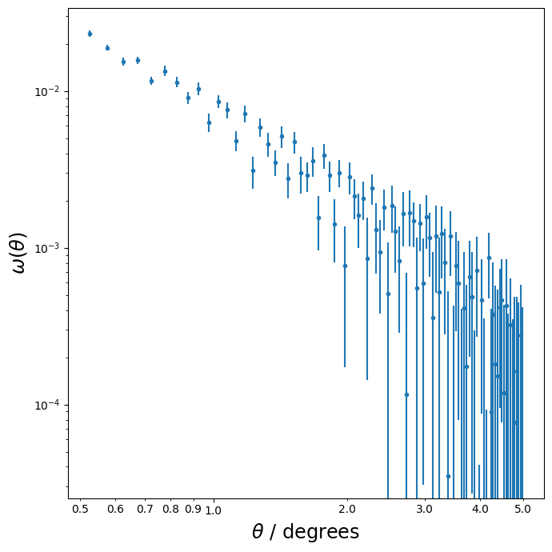

```python
# Create a figure
fig = plt.figure(figsize=(7, 7))

# Create a set of axes attached to our figure
ax = fig.add_subplot(1, 1, 1)

# Use the errorbar() method to plot the data
ax.errorbar(
    theta,  # The array of theta values calculated by treecorr
    omega,  # The array of omega values calculated by treecorr
    yerr=np.sqrt(
        omega_variance
    ),  # The square root variance values calculated by treecorr
    linestyle="none",  # Don't draw a line between the points on our plot
    marker="o",  # Use a circular marker style
    markersize=3,  # Set a marker size slightly smaller than the default (which is 5)
)

# Set the x and y axes to display logarithmic scales
ax.set_yscale("log")
ax.set_xscale("log")

# Fiddly formatting to improve the x-axis labels
from matplotlib import ticker
ax.xaxis.set_major_formatter(ticker.StrMethodFormatter('{x:.1f}'))
ax.xaxis.set_minor_formatter(ticker.StrMethodFormatter('{x:.1f}'))

# Set the x and y axes' titles
ax.set_ylabel(r"$\omega(\theta)$", fontsize="xx-large")
ax.set_xlabel(r"$\theta$ / degrees", fontsize="xx-large")

# Tidy up the plot
plt.tight_layout()

plt.savefig("0.7-0.8_Plot1.png")
```

```python
def rebin(theta, omega, omega_variance, points_to_combine=5):
    rebinned = np.array(
        [
            [
                theta[start : start + points_to_combine].mean(),
                omega[start : start + points_to_combine].mean(),
                omega_variance[start : start + points_to_combine].sum()
                / points_to_combine**2,
            ]
            for start in range(0, dd.rnom.size, points_to_combine)
        ]
    ).T
    return rebinned
```

```python
# Rebin the correlation function data using our `rebin` function
# The function returns three arrays containing our rebinned data.
theta_rebinned, omega_rebinned, omega_var_rebinned = rebin(
    theta, omega, omega_variance, 5
)
```

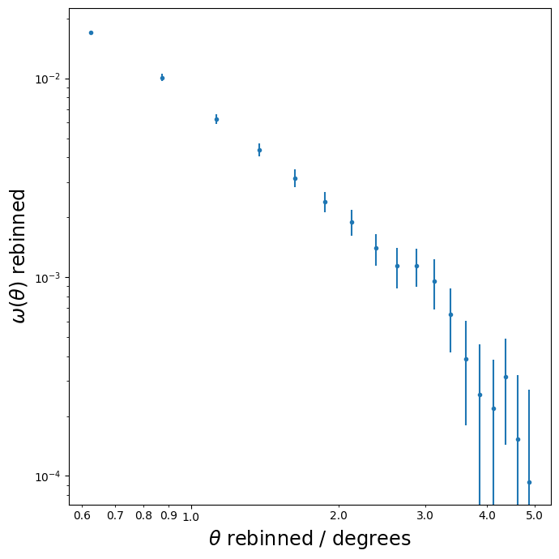

```python
# Create a figure
fig = plt.figure(figsize=(7, 7))

# Create a set of axes attached to our figure
ax = fig.add_subplot(1, 1, 1)

# Use the errorbar() method to plot the data
ax.errorbar(
    theta_rebinned,  # The array of rebinned theta values
    omega_rebinned,  # The array of rebinned omega values
    yerr=np.sqrt(omega_var_rebinned),  # The square root of the rebinned variance values
    linestyle="none",  # Don't draw a line between the points on our plot
    marker="o",  # Use a circular marker style
    markersize=3,  # Set a marker size slightly smaller than the default (which is 5)
)

# Set the x and y axes to display logarithmic scales
ax.set_yscale("log")
ax.set_xscale("log")

# Fiddly formatting to improve the x-axis labels
from matplotlib import ticker
ax.xaxis.set_major_formatter(ticker.StrMethodFormatter('{x:.1f}'))
ax.xaxis.set_minor_formatter(ticker.StrMethodFormatter('{x:.1f}'))

# Set the x and y axes' titles
ax.set_ylabel(r"$\omega(\theta)$ rebinned", fontsize="xx-large")
ax.set_xlabel(r"$\theta$ rebinned / degrees", fontsize="xx-large")

# Tidy up the plot
plt.tight_layout()

plt.savefig("0.7-0.8_Plot2.png")
```

```python
# Function to compute the broken power law component
def bkn_powerlaw(
    theta,  # numpy array of theta values
    norm,  # power law normalisation
    index_below,  # power law index below the break
    index_above,  # power law index above the break
    theta_break,  # angular separation at which the power law breaks
):
    # compute and return the values of the broken power law component using
    # the numpy.where function
    return np.where(
        # A boolean array True at positions where theta < theta_break
        # and False otherwise
        theta < theta_break,
        # An array of values to choose if the corresponding element of
        # the first argument is True i.e. for values of theta below
        # theta_break
        norm * (theta / theta_break) ** index_below,
        # An array of values to choose if the corresponding element of
        # the first argument is False i.e. for values of theta above
        # or equal to theta_break
        norm * (theta / theta_break) ** index_above,
    )


# Function to compute the gaussian component
def gaussian(
    theta,  # numpy array of theta values
    mean,  # gaussian mean
    sigma,  # gaussian sigma (standard deviation)
    norm,  # gaussian normalisation
):
    # compute and return the values of the gaussian component
    return norm * np.exp(-(((theta - mean) / sigma) ** 2))


# Function to compute the combined model
def model(
    theta,  # numpy array of theta values
    model_params,  # array of all 5 model parameters
):
    # extract the individual model parameters.
    # note that we expect them to be in a specific order and we will
    # need to be aware of this when we use the iminuit.minimize
    # function
    (
        bao_norm,
        bao_location,
        bao_sigma,
        pl_index_1,
        pl_index_2,
        pl_norm,
        pl_break,
    ) = model_params

    # compute the values of the power law components and store the results
    # power_law_1 = powerlaw(theta, pl_norm_1, pl_index_1)
    # power_law_2 = powerlaw(theta, pl_norm_2, pl_index_2)
    broken_powerlaw = bkn_powerlaw(theta, pl_norm, pl_index_1, pl_index_2, pl_break)
    # compute the values of the gaussian component and store the result
    bao_signal = gaussian(theta, bao_location, bao_sigma, bao_norm)

    # compute the combined model values by summing the two component arrays
    model = broken_powerlaw + bao_signal

    # return the combined model values
    return model
```

```python
# Fit function that computes the chi-square statistic
def fit_function(model_params, *data):
    # unpack the 2-dimensional data array into three separate data arrays.
    # note that we expect them to be in a specific order and we will
    # need to be aware of this when we use the iminuit.minimize
    # function
    theta, omega, omega_errors = data

    # call the model function to compute values of the combined model
    # given an array of theta values and the set of model parameters
    # that was passed to this function.
    model_omega = model(theta, model_params)

    # compute the chi-square statistic
    chi_square = (((omega - model_omega) / omega_errors) ** 2).sum()

    # return the computed chi_square statistic
    return chi_square
```

```python
# final guesses for parameters
bao_norm = 1e-5    # normalisation of the gaussian BAO signal component
bao_location = 2.5  # mean of the gaussian BAO signal component
bao_sigma = 0.5     # sigma of the gaussian BAO signal component
pl_index_1 = -1.85   # index of the broken power law component below the break
pl_index_2 = -1.8   # index of the broken power law component above the break
pl_norm = 0.65e-3    # normalisation of the broken power law component
pl_break = 3.8      # value of theta at which the power law breaks


# collect the initial parameter guesses together into a numpy array in the
# order that is expected by our `model` function.
initial_parameter_guesses = np.array(
    [bao_norm, bao_location, bao_sigma, pl_index_1, pl_index_2, pl_norm, pl_break]
)
```

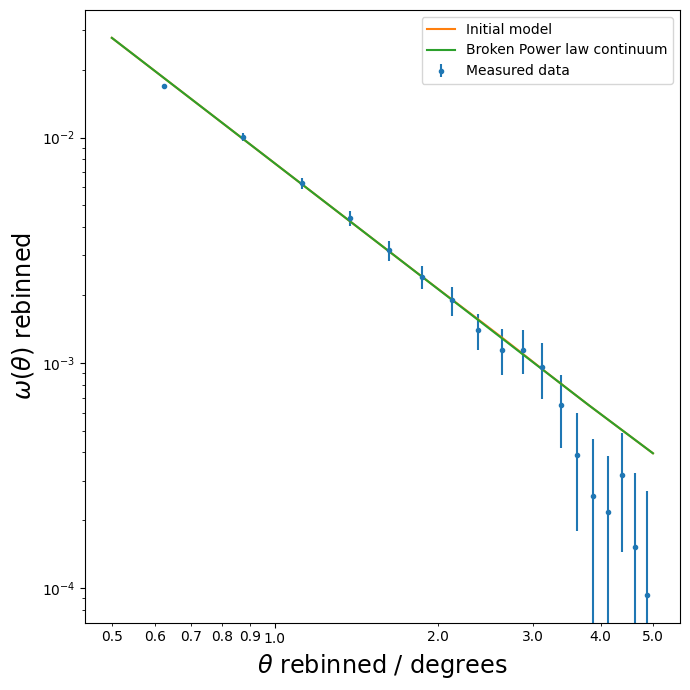

```python
# Create a figure
fig = plt.figure(figsize=(7, 7))

# Create a set of axes attached to our figure
ax = fig.add_subplot(1, 1, 1)

# Use the errorbar() method to plot the data
ax.errorbar(
    theta_rebinned,  # The array of rebinned theta values
    omega_rebinned,  # The array of rebinned omega values
    yerr=np.sqrt(omega_var_rebinned),  # The square root of the rebinned variance values
    linestyle="none",  # Don't draw a line between the points on our plot
    marker="o",  # Use a circular marker style
    markersize=3,  # Set a marker size slightly smaller than the default (which is 5)
    label="Measured data",  # Add a label that will be shown in the legend for this plot
)

# Use the `numpy.linspace` function to define a range of theta
# values at which to compute the values of the best fitting model
# function
theta_grid = np.linspace(0.5, 5, 50)

# Now call the `model` function to compute the model values for
# the values of theta in `theta_grid`. Note that we pass an array
# containing the initial parameter values as the second argument
# to the `model` function
initial_model_values = model(
    theta_grid,
    initial_parameter_guesses,
)

# Use the `plot` method of our axes object to plot the initial model
ax.plot(
    theta_grid,  # values of theta to plot the initial model for
    initial_model_values,  # values of the initial model
    label="Initial model",  # Add a label that will be shown in the legend for this plot
)

# Now call the `bkn_powerlaw` function to compute values for the
# broken power law continuum component of our model for the
# values of theta in `theta_grid`. Note that becuse of the way
# we defined the `bkn_powerlaw` function we must pass the parameters
# of our model that pertain to the broken
# power law separately.
initial_continuum_values = bkn_powerlaw(
    theta_grid,  # values of theta to plot the initial model for
    pl_norm,  # the brokemn power law normalisation
    pl_index_1,  # index of the broken power law component below the break
    pl_index_2,  # index of the broken power law component above the break
    pl_break,  # value of theta at which the power law breaks
)

# Use the `plot` method of our axes object to plot the initial continuum model
ax.plot(
    theta_grid,  # values of theta to plot the initial model for
    initial_continuum_values,  # values of the initial continuum model
    label="Broken Power law continuum",  # Add a label that will be shown in the legend for this plot
)

# Set the x and y axes to display logarithmic scales
ax.set_yscale("log")
ax.set_xscale("log")

# Fiddly formatting to improve the x-axis labels
from matplotlib import ticker
ax.xaxis.set_major_formatter(ticker.StrMethodFormatter('{x:.1f}'))
ax.xaxis.set_minor_formatter(ticker.StrMethodFormatter('{x:.1f}'))

# Set the x and y axes' titles
ax.set_ylabel(r"$\omega(\theta)$ rebinned", fontsize="xx-large")
ax.set_xlabel(r"$\theta$ rebinned / degrees", fontsize="xx-large")

# Add a legend to our axes
ax.legend()

# Tidy up the plot
plt.tight_layout()

plt.savefig("0.7-0.8_Plot3.png")
```

```python
# Print out your list of mean redshifts to as to identify an element you want to remove

print(z_mean_vals)

# The function below empties all of the lists

def clear_all_lists(z_min_vals,z_max_vals,z_mean_vals,bao_locs,bao_loc_errors):

        z_min_vals.clear()
        z_max_vals.clear()
        z_mean_vals.clear()
        bao_locs.clear()
        bao_loc_errors.clear()

clear_all_lists(z_min_vals,z_max_vals,z_mean_vals,bao_locs,bao_loc_errors)

print(z_mean_vals)
```

```
[]
[]
```

## 0.80 < z < 0.90

```python
# create five empty lists to store data about redshift bins and BAO data in each bin
z_min_vals, z_max_vals, z_mean_vals, bao_locs, bao_loc_errors = [], [], [], [], []
```

```python
z_min = 0.80
z_max = 0.90

# append the minimum redshift of the galaxies in this bin
z_min_vals.append(z_min)
# append the maximum redshift of the galaxies in this bin
z_max_vals.append(z_max)

# Select a redshift-limited subset from the observed catalogue
data_selection = select_z_bin(data_table, z_min, z_max, "DNF_ZMEAN_SOF")
# Select a redshift-limited subset from the synthetic catalogue
random_selection = select_z_bin(random_table, z_min, z_max, "Z")
```

```python
data_cat = tc.Catalog(
    ra=np.array(
        data_selection["RA"], dtype=np.float16
    ),  # Right ascensions of our galaxies - just a column from the catalogue table
    dec=np.array(
        data_selection["DEC"], dtype=np.float16
    ),  # Declinations of our galaxies - just a column from the catalogue table
    ra_units="degrees",  # The units used for RA - degrees
    dec_units="degrees",  # The units used for Declination - degrees
    npatch=20,  # Count pairs within 20 separate patches to calculate a variance estimate
)

random_cat = tc.Catalog(
    ra=np.array(
        random_selection["RA"], dtype=np.float16
    ),  # Right ascensions of our galaxies - just a column from the catalogue table
    dec=np.array(
        random_selection["DEC"], dtype=np.float16
    ),  # Declinations of our galaxies - just a column from the catalogue table
    ra_units="degrees",  # The units used for RA - degrees
    dec_units="degrees",  # The units used for Declination - degrees
    patch_centers=data_cat.patch_centers,  # Use the patches that were calculated for the DES survey catalogue
)

# This NNCorrelation object will compute DD(theta)
dd = tc.NNCorrelation(
    min_sep=0.5,
    max_sep=5.0,
    bin_size=0.05,
    bin_type="Linear",
    sep_units="degrees",
    bin_slop=0.02,  # Specifying bin_slop=0.02 results in a small loss of precision but is much faster
    var_method="jackknife",
)

# This NNCorrelation object will compute RR(theta)
rr = tc.NNCorrelation(
    min_sep=0.5,
    max_sep=5.0,
    bin_size=0.05,
    bin_type="Linear",
    sep_units="degrees",
    bin_slop=0.02,  # Specifying bin_slop=0.02 results in a small loss of precision but is much faster
    var_method="jackknife",
)

# This NNCorrelation object will compute DR(theta)
dr = tc.NNCorrelation(
    min_sep=0.5,
    max_sep=5.0,
    bin_size=0.05,
    bin_type="Linear",
    sep_units="degrees",
    bin_slop=0.02,  # Specifying bin_slop=0.02 results in a small loss of precision but is much faster
    var_method="jackknife",
)
```

```python
# Actually calculate DD(theta) - we only need to pass the DES survey catalogue
dd.process(data_cat)

# Actually calculate RR(theta) - we only need to pass the synthetic catalogue
# Note that this is the most time consuming operation in this activity - it can take
# several minutes to complete.
rr.process(random_cat)

# Actually calculate DR(theta) - we need to pass both catalogues
dr.process(data_cat, random_cat)

omega, omega_variance = dd.calculateXi(rr=rr, dr=dr)
```

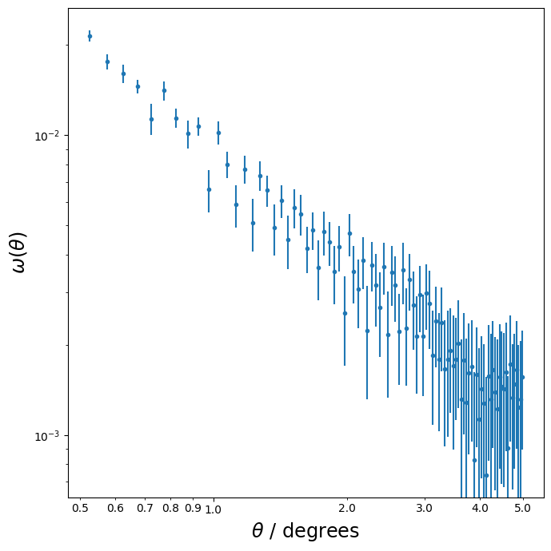

```python
# Create a figure
fig = plt.figure(figsize=(7, 7))

# Create a set of axes attached to our figure
ax = fig.add_subplot(1, 1, 1)

# Use the errorbar() method to plot the data
ax.errorbar(
    theta,  # The array of theta values calculated by treecorr
    omega,  # The array of omega values calculated by treecorr
    yerr=np.sqrt(
        omega_variance
    ),  # The square root variance values calculated by treecorr
    linestyle="none",  # Don't draw a line between the points on our plot
    marker="o",  # Use a circular marker style
    markersize=3,  # Set a marker size slightly smaller than the default (which is 5)
)

# Set the x and y axes to display logarithmic scales
ax.set_yscale("log")
ax.set_xscale("log")

# Fiddly formatting to improve the x-axis labels
from matplotlib import ticker
ax.xaxis.set_major_formatter(ticker.StrMethodFormatter('{x:.1f}'))
ax.xaxis.set_minor_formatter(ticker.StrMethodFormatter('{x:.1f}'))

# Set the x and y axes' titles
ax.set_ylabel(r"$\omega(\theta)$", fontsize="xx-large")
ax.set_xlabel(r"$\theta$ / degrees", fontsize="xx-large")

# Tidy up the plot
plt.tight_layout()

plt.savefig("0.8-0.9_Plot1.png")
```

```python
def rebin(theta, omega, omega_variance, points_to_combine=5):
    rebinned = np.array(
        [
            [
                theta[start : start + points_to_combine].mean(),
                omega[start : start + points_to_combine].mean(),
                omega_variance[start : start + points_to_combine].sum()
                / points_to_combine**2,
            ]
            for start in range(0, dd.rnom.size, points_to_combine)
        ]
    ).T
    return rebinned
```

```python
# Rebin the correlation function data using our `rebin` function
# The function returns three arrays containing our rebinned data.
theta_rebinned, omega_rebinned, omega_var_rebinned = rebin(
    theta, omega, omega_variance, 5
)
```

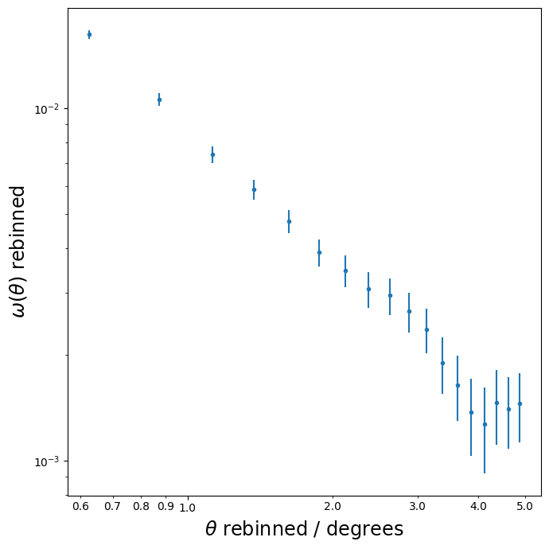

```python
# Create a figure
fig = plt.figure(figsize=(7, 7))

# Create a set of axes attached to our figure
ax = fig.add_subplot(1, 1, 1)

# Use the errorbar() method to plot the data
ax.errorbar(
    theta_rebinned,  # The array of rebinned theta values
    omega_rebinned,  # The array of rebinned omega values
    yerr=np.sqrt(omega_var_rebinned),  # The square root of the rebinned variance values
    linestyle="none",  # Don't draw a line between the points on our plot
    marker="o",  # Use a circular marker style
    markersize=3,  # Set a marker size slightly smaller than the default (which is 5)
)

# Set the x and y axes to display logarithmic scales
ax.set_yscale("log")
ax.set_xscale("log")

# Fiddly formatting to improve the x-axis labels
from matplotlib import ticker
ax.xaxis.set_major_formatter(ticker.StrMethodFormatter('{x:.1f}'))
ax.xaxis.set_minor_formatter(ticker.StrMethodFormatter('{x:.1f}'))

# Set the x and y axes' titles
ax.set_ylabel(r"$\omega(\theta)$ rebinned", fontsize="xx-large")
ax.set_xlabel(r"$\theta$ rebinned / degrees", fontsize="xx-large")

# Tidy up the plot
plt.tight_layout()

plt.savefig("0.8-0.9_Plot2.png")
```

```python
# Function to compute the broken power law component
def bkn_powerlaw(
    theta,  # numpy array of theta values
    norm,  # power law normalisation
    index_below,  # power law index below the break
    index_above,  # power law index above the break
    theta_break,  # angular separation at which the power law breaks
):
    # compute and return the values of the broken power law component using
    # the numpy.where function
    return np.where(
        # A boolean array True at positions where theta < theta_break
        # and False otherwise
        theta < theta_break,
        # An array of values to choose if the corresponding element of
        # the first argument is True i.e. for values of theta below
        # theta_break
        norm * (theta / theta_break) ** index_below,
        # An array of values to choose if the corresponding element of
        # the first argument is False i.e. for values of theta above
        # or equal to theta_break
        norm * (theta / theta_break) ** index_above,
    )


# Function to compute the gaussian component
def gaussian(
    theta,  # numpy array of theta values
    mean,  # gaussian mean
    sigma,  # gaussian sigma (standard deviation)
    norm,  # gaussian normalisation
):
    # compute and return the values of the gaussian component
    return norm * np.exp(-(((theta - mean) / sigma) ** 2))

# Function to compute the combined model
def model(
    theta,  # numpy array of theta values
    model_params,  # array of all 5 model parameters
):
    # extract the individual model parameters.
    # note that we expect them to be in a specific order and we will
    # need to be aware of this when we use the iminuit.minimize
    # function
    (
        bao_norm,
        bao_location,
        bao_sigma,
        pl_index_1,
        pl_index_2,
        pl_norm,
        pl_break,
    ) = model_params

    # compute the values of the power law components and store the results
    # power_law_1 = powerlaw(theta, pl_norm_1, pl_index_1)
    # power_law_2 = powerlaw(theta, pl_norm_2, pl_index_2)
    broken_powerlaw = bkn_powerlaw(theta, pl_norm, pl_index_1, pl_index_2, pl_break)
    # compute the values of the gaussian component and store the result
    bao_signal = gaussian(theta, bao_location, bao_sigma, bao_norm)

    # compute the combined model values by summing the two component arrays
    model = broken_powerlaw + bao_signal

    # return the combined model values
    return model
```

```python
# Fit function that computes the chi-square statistic
def fit_function(model_params, *data):
    # unpack the 2-dimensional data array into three separate data arrays.
    # note that we expect them to be in a specific order and we will
    # need to be aware of this when we use the iminuit.minimize
    # function
    theta, omega, omega_errors = data

    # call the model function to compute values of the combined model
    # given an array of theta values and the set of model parameters
    # that was passed to this function.
    model_omega = model(theta, model_params)

    # compute the chi-square statistic
    chi_square = (((omega - model_omega) / omega_errors) ** 2).sum()

    # return the computed chi_square statistic
    return chi_square
```

```python
# final guesses for parameters
bao_norm = 0.0005    # normalisation of the gaussian BAO signal component
bao_location = 2.8  # mean of the gaussian BAO signal component
bao_sigma = 0.6     # sigma of the gaussian BAO signal component
pl_index_1 = -1.3   # index of the broken power law component below the break
pl_index_2 = -0.2   # index of the broken power law component above the break
pl_norm = 1.3e-3    # normalisation of the broken power law component
pl_break = 4.0      # value of theta at which the power law breaks


# collect the initial parameter guesses together into a numpy array in the
# order that is expected by our `model` function.
initial_parameter_guesses = np.array(
    [bao_norm, bao_location, bao_sigma, pl_index_1, pl_index_2, pl_norm, pl_break]
)
```

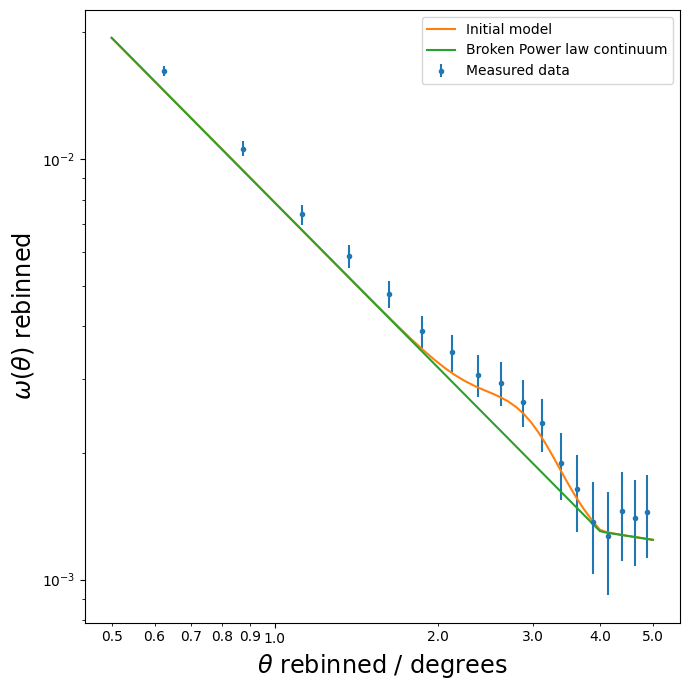

```python
# Create a figure
fig = plt.figure(figsize=(7, 7))

# Create a set of axes attached to our figure
ax = fig.add_subplot(1, 1, 1)

# Use the errorbar() method to plot the data
ax.errorbar(
    theta_rebinned,  # The array of rebinned theta values
    omega_rebinned,  # The array of rebinned omega values
    yerr=np.sqrt(omega_var_rebinned),  # The square root of the rebinned variance values
    linestyle="none",  # Don't draw a line between the points on our plot
    marker="o",  # Use a circular marker style
    markersize=3,  # Set a marker size slightly smaller than the default (which is 5)
    label="Measured data",  # Add a label that will be shown in the legend for this plot
)

# Use the `numpy.linspace` function to define a range of theta
# values at which to compute the values of the best fitting model
# function
theta_grid = np.linspace(0.5, 5, 50)

# Now call the `model` function to compute the model values for
# the values of theta in `theta_grid`. Note that we pass an array
# containing the initial parameter values as the second argument
# to the `model` function
initial_model_values = model(
    theta_grid,
    initial_parameter_guesses,
)

# Use the `plot` method of our axes object to plot the initial model
ax.plot(
    theta_grid,  # values of theta to plot the initial model for
    initial_model_values,  # values of the initial model
    label="Initial model",  # Add a label that will be shown in the legend for this plot
)

# Now call the `bkn_powerlaw` function to compute values for the
# broken power law continuum component of our model for the
# values of theta in `theta_grid`. Note that becuse of the way
# we defined the `bkn_powerlaw` function we must pass the parameters
# of our model that pertain to the broken
# power law separately.
initial_continuum_values = bkn_powerlaw(
    theta_grid,  # values of theta to plot the initial model for
    pl_norm,  # the brokemn power law normalisation
    pl_index_1,  # index of the broken power law component below the break
    pl_index_2,  # index of the broken power law component above the break
    pl_break,  # value of theta at which the power law breaks
)

# Use the `plot` method of our axes object to plot the initial continuum model
ax.plot(
    theta_grid,  # values of theta to plot the initial model for
    initial_continuum_values,  # values of the initial continuum model
    label="Broken Power law continuum",  # Add a label that will be shown in the legend for this plot
)

# Set the x and y axes to display logarithmic scales
ax.set_yscale("log")
ax.set_xscale("log")

# Fiddly formatting to improve the x-axis labels
from matplotlib import ticker
ax.xaxis.set_major_formatter(ticker.StrMethodFormatter('{x:.1f}'))
ax.xaxis.set_minor_formatter(ticker.StrMethodFormatter('{x:.1f}'))

# Set the x and y axes' titles
ax.set_ylabel(r"$\omega(\theta)$ rebinned", fontsize="xx-large")
ax.set_xlabel(r"$\theta$ rebinned / degrees", fontsize="xx-large")

# Add a legend to our axes
ax.legend()

# Tidy up the plot
plt.tight_layout()

plt.savefig("0.8-0.9_Plot3.png")
```

```python
# Bounds for model parameter values

# bounds on normalisation of the gaussian BAO signal component
# Note that we do not place an upper bound on this parameter.
bao_norm_bounds = [1e-4, None]
# bounds on mean of the gaussian BAO signal component
bao_location_bounds = [1.5, 4]
# bounds on sigma of the gaussian BAO signal component
bao_sigma_bounds = [0.4, 0.9]
# bounds on index of the broken power law component below the break
# Note that we restrict this to be negative, implying a falling power
# law.
pl_index_1_bounds = [-5, -1]
# bounds on index of the broken power law component above the break
# Note that we allow this to be slightly positive.
pl_index_2_bounds = [-3, 0.5]
# bounds on normalisation of the broken power law component
# Note that we do not place an upper bound on this parameter.
pl_norm_bounds = [1e-4, None]
# bounds on value of theta at which the power law breaks
# Note that we allow a large range of values because we do
# not need the continuum model to be physically meaningful
# but we do need it to be flexible.
pl_break_bounds = [2, 7]

# collect the parameter bounds together into a numpy array in the
# order that is expected by our `model` function.
parameter_bounds = np.array(
    [
        bao_norm_bounds,
        bao_location_bounds,
        bao_sigma_bounds,
        pl_index_1_bounds,
        pl_index_2_bounds,
        pl_norm_bounds,
        pl_break_bounds,
    ]
)
```

```python
# run the minimize function to find the best fit parameters
fit_results = imin.minimize(
    fit_function,
    x0=initial_parameter_guesses,
    args=[theta_rebinned, omega_rebinned, np.sqrt(omega_var_rebinned)],
    bounds=parameter_bounds,
    options=dict(stra=2, maxfun=10000),  # You should not need to change these options
)
```

```python
# test the value of the success attribute
if fit_results.success:
    # if True, print that the fit succeeded
    print("The fit succeeded!")
else:
    # if False, print that the fit failed and the message which may provide clues about why
    print("The fit failed:", fit_results.message)
```

```
The fit succeeded!
```

```python
# unpack the best fitting parameters found by the minimize function
(
    fitted_bao_norm,
    fitted_bao_location,  # the best fit BAO angular size
    fitted_bao_sigma,
    fitted_pl_index_1,
    fitted_pl_index_2,
    fitted_pl_norm,
    fitted_pl_break,
) = fit_results.x
```

```python
# The next two lines compute the parameter errors
fit_results.minuit.errordef = fit_results.minuit.LEAST_SQUARES
fit_results.minuit.hesse()

# unpack the best fitting parameter uncertainties
(
    fitted_bao_norm_err,
    fitted_bao_location_err,  # estimated uncertainty on the best fit BAO angular size
    fitted_bao_sigma_err,
    fitted_pl_index_1_err,
    fitted_pl_index_2_err,
    fitted_pl_break_err,
    fitted_pl_norm_err,
) = fit_results.minuit.errors
```

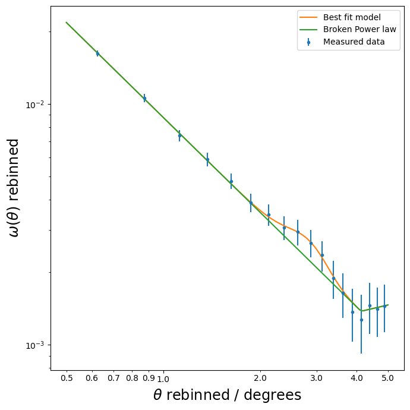

```python
# Create a figure
fig = plt.figure(figsize=(7, 7))

# Create a set of axes attached to our figure
ax = fig.add_subplot(1, 1, 1)

# Use the errorbar() method to plot the data
ax.errorbar(
    theta_rebinned,  # The array of rebinned theta values
    omega_rebinned,  # The array of rebinned omega values
    yerr=np.sqrt(omega_var_rebinned),  # The square root of the rebinned variance values
    linestyle="none",  # Don't draw a line between the points on our plot
    marker="o",  # Use a circular marker style
    markersize=3,  # Set a marker size slightly smaller than the default (which is 5)
    label="Measured data",  # Add a label that will be shown in the legend for this plot
)

# Use the `numpy.linspace` function to define a range of theta
# values at which to compute the values of the best fitting model
# function
theta_grid = np.linspace(0.5, 5, 50)

# Now call the `model` function to compute the model values for
# the values of theta in `theta_grid`. Note that we pass a list
# containing the best fit parameter values as the second argument
# to the `model` function
best_fit_model_values = model(
    theta_grid,
    [
        fitted_bao_norm,
        fitted_bao_location,  # the best fit BAO angular size
        fitted_bao_sigma,
        fitted_pl_index_1,
        fitted_pl_index_2,
        fitted_pl_norm,
        fitted_pl_break,
    ],
)

# Use the `plot` method of our axes object to plot the best fitting model
ax.plot(
    theta_grid,  # values of theta to plot the best fit model for
    best_fit_model_values,  # values of the best fitting model
    label="Best fit model",  # Add a label that will be shown in the legend for this plot
)

ax.plot(
    theta_grid,  # values of theta to plot the initial model for
    bkn_powerlaw(
        theta_grid,
        fitted_pl_norm,
        fitted_pl_index_1,
        fitted_pl_index_2,
        fitted_pl_break,
    ),  # values of the initial model
    label="Broken Power law",  # Add a label that will be shown in the legend for this plot
)

# Set the x and y axes to display logarithmic scales
ax.set_yscale("log")
ax.set_xscale("log")

# Fiddly formatting to improve the x-axis labels
from matplotlib import ticker
ax.xaxis.set_major_formatter(ticker.StrMethodFormatter('{x:.1f}'))
ax.xaxis.set_minor_formatter(ticker.StrMethodFormatter('{x:.1f}'))

# Set the x and y axes' titles
ax.set_ylabel(r"$\omega(\theta)$ rebinned", fontsize="xx-large")
ax.set_xlabel(r"$\theta$ rebinned / degrees", fontsize="xx-large")

# Add a legend to our axes
ax.legend()

# Tidy up the plot
plt.tight_layout()

plt.savefig("0.8-0.9_Plot4.png")
```

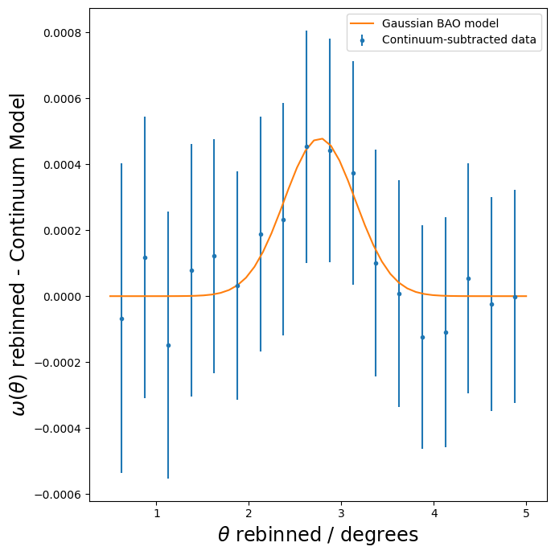

```python
# Create a figure
fig = plt.figure(figsize=(7, 7))

# Create a set of axes attached to our figure
ax = fig.add_subplot(1, 1, 1)

# subtract the continuum model corresponding with the best fit parameters from
# the correlation function data
continuum_subtracted_omega_rebinned = omega_rebinned - bkn_powerlaw(
    # calculate the values of the continuum model at the data point locations
    theta_rebinned,
    # pass the the best fit parameters
    fitted_pl_norm,
    fitted_pl_index_1,
    fitted_pl_index_2,
    fitted_pl_break,
)

# Use the errorbar() method to plot the continuum-subtracted data
ax.errorbar(
    theta_rebinned,  # The array of rebinned theta values
    continuum_subtracted_omega_rebinned,  # The array of continuum-subtracted omega values
    yerr=np.sqrt(omega_var_rebinned),  # The square root of the rebinned variance values
    linestyle="none",  # Don't draw a line between the points on our plot
    marker="o",  # Use a circular marker style
    markersize=3,  # Set a marker size slightly smaller than the default (which is 5)
    label="Continuum-subtracted data",  # Add a label that will be shown in the legend for this plot
)

# Use the `numpy.linspace` function to define a range of theta
# values at which to compute the values of the best fitting model
# function
theta_grid = np.linspace(0.5, 5, 50)

# Use the `plot` method of our axes object to plot the best fitting model
ax.plot(
    theta_grid,  # values of theta to plot the initial model for
    # gaussian model for the BAO signal
    gaussian(
        theta_grid,
        fitted_bao_location,
        fitted_bao_sigma,
        fitted_bao_norm,
    ),
    label="Gaussian BAO model",  # Add a label that will be shown in the legend for this plot
)

# Set the x and y axes' titles
ax.set_ylabel(r"$\omega(\theta)$ rebinned - Continuum Model", fontsize="xx-large")
ax.set_xlabel(r"$\theta$ rebinned / degrees", fontsize="xx-large")

# Add a legend to our axes
ax.legend()

# Tidy up the plot
plt.tight_layout()

plt.savefig("0.8-0.9_Plot5.png")
```

```python
# run the mnprofile function (the argument "x1" is just iminuit's internal
# label for the BAO angular size parameter)
test_bao_locs, chi_square_values, fit_succeeded = fit_results.minuit.mnprofile("x1")
```

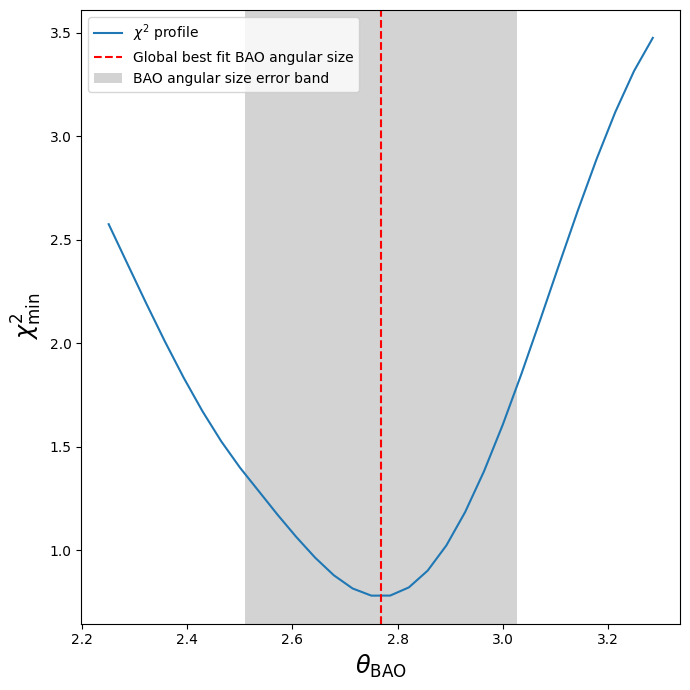

```python
# Create a figure
fig = plt.figure(figsize=(7, 7))

# Create a set of axes attached to our figure
ax = fig.add_subplot(1, 1, 1)

# Use the `plot` method of our axes object to plot chi-square versus BAO angular size
ax.plot(
    test_bao_locs,  # test values of the BAO angular size for which the chi square was minimised
    chi_square_values,  # the best fit chi-square values for each test BAO angular size
    label="$\chi^{2}$ profile",  # Add a label that will be shown in the legend for this plot
)

# Add a red, dashed vertical line at the location of the best fit value
ax.axvline(
    fitted_bao_location,
    color="r",
    linestyle="dashed",
    label="Global best fit BAO angular size",
)

# Add a filled grey region illustrating the range spanned by the fit uncertainties
# associated with the BAO angular size
ax.axvspan(
    fitted_bao_location - fitted_bao_location_err,
    fitted_bao_location + fitted_bao_location_err,
    facecolor="lightgrey",
    label="BAO angular size error band",
)

# Set the x and y axes' titles
ax.set_ylabel("$\chi^{2}_{\min}$", fontsize="xx-large")
ax.set_xlabel(r"$\theta_{\mathrm{BAO}}$", fontsize="xx-large")

# Add a legend to our axes
ax.legend()

# Tidy up the plot
plt.tight_layout()

plt.savefig("0.8-0.9_Plot6.png")
```

```python
# append the best fit BAO angular size
bao_locs.append(fitted_bao_location)
# append the uncertainty on the best fit BAO angular size
bao_loc_errors.append(fitted_bao_location_err)
```

```python
# generate an array of 100 redshifts  between 0.6 and 1.1
# for which to predict the expected size of the BAO feature
z_grid = np.linspace(start=0.6, stop=1.1, num=100)
```

```python
import astropy.units as u
```

```python
bao_comoving_size = 150 * u.Mpc
```

```python
bao_physical_sizes = bao_comoving_size / (1 + z_grid)
# print the physical sizes' units to verify that they are Mpc
print("The units of the computed physical sizes are", bao_physical_sizes.unit)
```

```
The units of the computed physical sizes are Mpc
```

```python
import astropy.cosmology as apcosmo
```

```python
ang_diam_distances = apcosmo.Planck18.angular_diameter_distance(z_grid)
# print the angular diameter distances' units to verify that they are Mpc
print(
    "The units of the computed angular diameter distances are", ang_diam_distances.unit
)
```

```
The units of the computed angular diameter distances are Mpc
```

```python
# compute the predicted BAO angular scales in radians
bao_angular_scales_rad = (bao_physical_sizes / ang_diam_distances) * u.radian
# convert from radians to degrees
bao_angular_scales = bao_angular_scales_rad.to(u.degree)
```

```python
# compute the mean redhsift of the galaxies in our selection
z_mean = data_selection["DNF_ZMEAN_SOF"].mean()
z_mean_vals.append(z_mean)
```

```python
print(z_mean_vals)
print(bao_locs)
print(bao_loc_errors)
print(z_min_vals)
print(z_max_vals)
```

```
[0.847884]
[2.767756410959582]
[0.25857672833267165]
[0.8]
[0.9]
```

```python
# Combine the lists into a dictionary
data_dict = {
    "z_mean_vals": z_mean_vals,
    "bao_locs": bao_locs,
    "bao_loc_errors": bao_loc_errors,
    "z_min_vals": z_min_vals,
    "z_max_vals": z_max_vals,
}
```

```python
df = pd.DataFrame(data_dict)
```

```python
csv_filename = "data_1.csv"  # File name
df.to_csv(csv_filename, index=False)  # Save without row indices

print(f"Data saved successfully to {csv_filename}!")
```

```
Data saved successfully to data_1.csv!
```

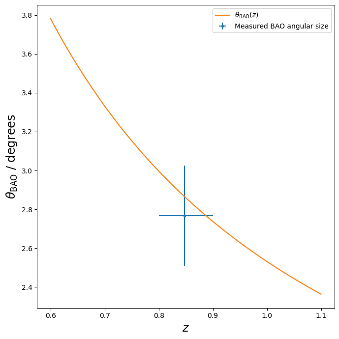

```python
# Create a figure
fig = plt.figure(figsize=(7, 7))

# Create a set of axes attached to our figure
ax = fig.add_subplot(1, 1, 1)

# compute sizes of lower and upper error bars in the redshift direction
# These are equal to the distance between the mean redshift and the lower
# or upper bin boundaries
z_err_low = np.array(z_mean_vals) - np.array(z_min_vals)
z_err_high = np.array(z_max_vals) - np.array(z_mean_vals)

# Use the errorbar() method to plot the data
ax.errorbar(
    x=z_mean_vals,  # mean redshift of galaxies in our redshift bin
    y=bao_locs,  # best fit BAO angular scale for galaxies in redshift bin
    yerr=np.atleast_2d(bao_loc_errors),  # uncertainty best fit BAO angular scale
    xerr=np.array([
        z_err_low,
        z_err_high,
    ]),  # horizontal errors to represent the reshift bin width
    linestyle="none",  # Don't draw a line between the points on our plot
    marker="o",  # Use a circular marker style
    markersize=3,  # Set a marker size slightly smaller than the default (which is 5)
    label="Measured BAO angular size",  # Add a label that will be shown in the legend for this plot
)


# Use the `plot` method of our axes object to plot theoretical angular sizes
ax.plot(
    z_grid,  # values of redshift for which to plot the theoretical angular sizes
    bao_angular_scales,  # values of the theoiretical angular sizes
    label=r"$\theta_{\mathrm{BAO}}(z)$",  # Add a label that will be shown in the legend for this plot
)

# Set the x and y axes' titles
ax.set_ylabel(r"$\theta_{\mathrm{BAO}}$ / degrees", fontsize="xx-large")
ax.set_xlabel("$z$", fontsize="xx-large")

# Add a legend to our axes
ax.legend()

# Tidy up the plot
plt.tight_layout()

plt.savefig("0.8-0.9_Plot7.png")
```

```python
# Print out your list of mean redshifts to as to identify an element you want to remove

print(z_mean_vals)

# The function below empties all of the lists

def clear_all_lists(z_min_vals,z_max_vals,z_mean_vals,bao_locs,bao_loc_errors):

        z_min_vals.clear()
        z_max_vals.clear()
        z_mean_vals.clear()
        bao_locs.clear()
        bao_loc_errors.clear()

clear_all_lists(z_min_vals,z_max_vals,z_mean_vals,bao_locs,bao_loc_errors)

print(z_mean_vals)
```

```
[0.847884]
[]
```

## 0.90 < z < 1.00

```python
# create five empty lists to store data about redshift bins and BAO data in each bin
z_min_vals, z_max_vals, z_mean_vals, bao_locs, bao_loc_errors = [], [], [], [], []
```

```python
z_min = 0.90
z_max = 1.00

# append the minimum redshift of the galaxies in this bin
z_min_vals.append(z_min)
# append the maximum redshift of the galaxies in this bin
z_max_vals.append(z_max)

# Select a redshift-limited subset from the observed catalogue
data_selection = select_z_bin(data_table, z_min, z_max, "DNF_ZMEAN_SOF")
# Select a redshift-limited subset from the synthetic catalogue
random_selection = select_z_bin(random_table, z_min, z_max, "Z")
```

```python
data_cat = tc.Catalog(
    ra=np.array(
        data_selection["RA"], dtype=np.float16
    ),  # Right ascensions of our galaxies - just a column from the catalogue table
    dec=np.array(
        data_selection["DEC"], dtype=np.float16
    ),  # Declinations of our galaxies - just a column from the catalogue table
    ra_units="degrees",  # The units used for RA - degrees
    dec_units="degrees",  # The units used for Declination - degrees
    npatch=20,  # Count pairs within 20 separate patches to calculate a variance estimate
)

random_cat = tc.Catalog(
    ra=np.array(
        random_selection["RA"], dtype=np.float16
    ),  # Right ascensions of our galaxies - just a column from the catalogue table
    dec=np.array(
        random_selection["DEC"], dtype=np.float16
    ),  # Declinations of our galaxies - just a column from the catalogue table
    ra_units="degrees",  # The units used for RA - degrees
    dec_units="degrees",  # The units used for Declination - degrees
    patch_centers=data_cat.patch_centers,  # Use the patches that were calculated for the DES survey catalogue
)

# This NNCorrelation object will compute DD(theta)
dd = tc.NNCorrelation(
    min_sep=0.5,
    max_sep=5.0,
    bin_size=0.05,
    bin_type="Linear",
    sep_units="degrees",
    bin_slop=0.02,  # Specifying bin_slop=0.02 results in a small loss of precision but is much faster
    var_method="jackknife",
)

# This NNCorrelation object will compute RR(theta)
rr = tc.NNCorrelation(
    min_sep=0.5,
    max_sep=5.0,
    bin_size=0.05,
    bin_type="Linear",
    sep_units="degrees",
    bin_slop=0.02,  # Specifying bin_slop=0.02 results in a small loss of precision but is much faster
    var_method="jackknife",
)

# This NNCorrelation object will compute DR(theta)
dr = tc.NNCorrelation(
    min_sep=0.5,
    max_sep=5.0,
    bin_size=0.05,
    bin_type="Linear",
    sep_units="degrees",
    bin_slop=0.02,  # Specifying bin_slop=0.02 results in a small loss of precision but is much faster
    var_method="jackknife",
)
```

```python
# Actually calculate DD(theta) - we only need to pass the DES survey catalogue
dd.process(data_cat)

# Actually calculate RR(theta) - we only need to pass the synthetic catalogue
# Note that this is the most time consuming operation in this activity - it can take
# several minutes to complete.
rr.process(random_cat)

# Actually calculate DR(theta) - we need to pass both catalogues
dr.process(data_cat, random_cat)

omega, omega_variance = dd.calculateXi(rr=rr, dr=dr)
```

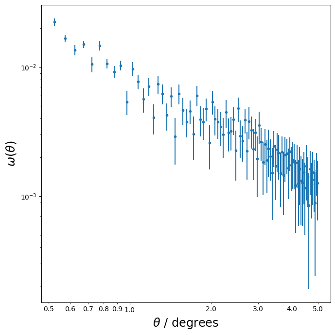

```python
# Create a figure
fig = plt.figure(figsize=(7, 7))

# Create a set of axes attached to our figure
ax = fig.add_subplot(1, 1, 1)

# Use the errorbar() method to plot the data
ax.errorbar(
    theta,  # The array of theta values calculated by treecorr
    omega,  # The array of omega values calculated by treecorr
    yerr=np.sqrt(
        omega_variance
    ),  # The square root variance values calculated by treecorr
    linestyle="none",  # Don't draw a line between the points on our plot
    marker="o",  # Use a circular marker style
    markersize=3,  # Set a marker size slightly smaller than the default (which is 5)
)

# Set the x and y axes to display logarithmic scales
ax.set_yscale("log")
ax.set_xscale("log")

# Fiddly formatting to improve the x-axis labels
from matplotlib import ticker
ax.xaxis.set_major_formatter(ticker.StrMethodFormatter('{x:.1f}'))
ax.xaxis.set_minor_formatter(ticker.StrMethodFormatter('{x:.1f}'))

# Set the x and y axes' titles
ax.set_ylabel(r"$\omega(\theta)$", fontsize="xx-large")
ax.set_xlabel(r"$\theta$ / degrees", fontsize="xx-large")

# Tidy up the plot
plt.tight_layout()

plt.savefig("0.9-1.00_Plot1.png")
```

```python
def rebin(theta, omega, omega_variance, points_to_combine=5):
    rebinned = np.array(
        [
            [
                theta[start : start + points_to_combine].mean(),
                omega[start : start + points_to_combine].mean(),
                omega_variance[start : start + points_to_combine].sum()
                / points_to_combine**2,
            ]
            for start in range(0, dd.rnom.size, points_to_combine)
        ]
    ).T
    return rebinned
```

```python
# Rebin the correlation function data using our `rebin` function
# The function returns three arrays containing our rebinned data.
theta_rebinned, omega_rebinned, omega_var_rebinned = rebin(
    theta, omega, omega_variance, 5
)
```

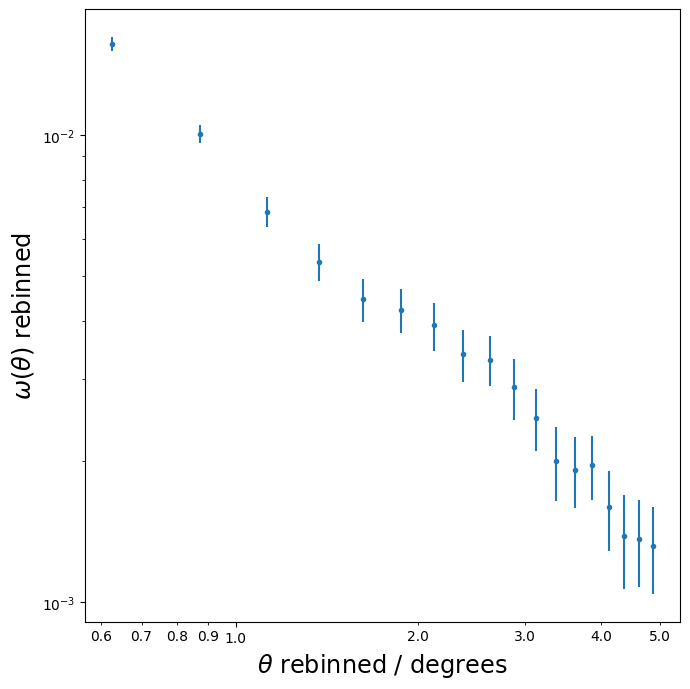

```python
# Create a figure
fig = plt.figure(figsize=(7, 7))

# Create a set of axes attached to our figure
ax = fig.add_subplot(1, 1, 1)

# Use the errorbar() method to plot the data
ax.errorbar(
    theta_rebinned,  # The array of rebinned theta values
    omega_rebinned,  # The array of rebinned omega values
    yerr=np.sqrt(omega_var_rebinned),  # The square root of the rebinned variance values
    linestyle="none",  # Don't draw a line between the points on our plot
    marker="o",  # Use a circular marker style
    markersize=3,  # Set a marker size slightly smaller than the default (which is 5)
)

# Set the x and y axes to display logarithmic scales
ax.set_yscale("log")
ax.set_xscale("log")

# Fiddly formatting to improve the x-axis labels
from matplotlib import ticker
ax.xaxis.set_major_formatter(ticker.StrMethodFormatter('{x:.1f}'))
ax.xaxis.set_minor_formatter(ticker.StrMethodFormatter('{x:.1f}'))

# Set the x and y axes' titles
ax.set_ylabel(r"$\omega(\theta)$ rebinned", fontsize="xx-large")
ax.set_xlabel(r"$\theta$ rebinned / degrees", fontsize="xx-large")

# Tidy up the plot
plt.tight_layout()

plt.savefig("0.9-1.00_Plot2.png")
```

```python
# Function to compute the broken power law component
def bkn_powerlaw(
    theta,  # numpy array of theta values
    norm,  # power law normalisation
    index_below,  # power law index below the break
    index_above,  # power law index above the break
    theta_break,  # angular separation at which the power law breaks
):
    # compute and return the values of the broken power law component using
    # the numpy.where function
    return np.where(
        # A boolean array True at positions where theta < theta_break
        # and False otherwise
        theta < theta_break,
        # An array of values to choose if the corresponding element of
        # the first argument is True i.e. for values of theta below
        # theta_break
        norm * (theta / theta_break) ** index_below,
        # An array of values to choose if the corresponding element of
        # the first argument is False i.e. for values of theta above
        # or equal to theta_break
        norm * (theta / theta_break) ** index_above,
    )


# Function to compute the gaussian component
def gaussian(
    theta,  # numpy array of theta values
    mean,  # gaussian mean
    sigma,  # gaussian sigma (standard deviation)
    norm,  # gaussian normalisation
):
    # compute and return the values of the gaussian component
    return norm * np.exp(-(((theta - mean) / sigma) ** 2))


# Function to compute the combined model
def model(
    theta,  # numpy array of theta values
    model_params,  # array of all 5 model parameters
):
    # extract the individual model parameters.
    # note that we expect them to be in a specific order and we will
    # need to be aware of this when we use the iminuit.minimize
    # function
    (
        bao_norm,
        bao_location,
        bao_sigma,
        pl_index_1,
        pl_index_2,
        pl_norm,
        pl_break,
    ) = model_params

    # compute the values of the power law components and store the results
    # power_law_1 = powerlaw(theta, pl_norm_1, pl_index_1)
    # power_law_2 = powerlaw(theta, pl_norm_2, pl_index_2)
    broken_powerlaw = bkn_powerlaw(theta, pl_norm, pl_index_1, pl_index_2, pl_break)
    # compute the values of the gaussian component and store the result
    bao_signal = gaussian(theta, bao_location, bao_sigma, bao_norm)

    # compute the combined model values by summing the two component arrays
    model = broken_powerlaw + bao_signal

    # return the combined model values
    return model
```

```python
# Fit function that computes the chi-square statistic
def fit_function(model_params, *data):
    # unpack the 2-dimensional data array into three separate data arrays.
    # note that we expect them to be in a specific order and we will
    # need to be aware of this when we use the iminuit.minimize
    # function
    theta, omega, omega_errors = data

    # call the model function to compute values of the combined model
    # given an array of theta values and the set of model parameters
    # that was passed to this function.
    model_omega = model(theta, model_params)

    # compute the chi-square statistic
    chi_square = (((omega - model_omega) / omega_errors) ** 2).sum()

    # return the computed chi_square statistic
    return chi_square
```

```python
# final guesses for parameters
bao_norm = 0.001    # normalisation of the gaussian BAO signal component
bao_location = 2.6  # mean of the gaussian BAO signal component
bao_sigma = 0.9     # sigma of the gaussian BAO signal component
pl_index_1 = -1.4   # index of the broken power law component below the break
pl_index_2 = -0.2   # index of the broken power law component above the break
pl_norm = 1.3e-3    # normalisation of the broken power law component
pl_break = 3.8      # value of theta at which the power law breaks


# collect the initial parameter guesses together into a numpy array in the
# order that is expected by our `model` function.
initial_parameter_guesses = np.array(
    [bao_norm, bao_location, bao_sigma, pl_index_1, pl_index_2, pl_norm, pl_break]
)
```

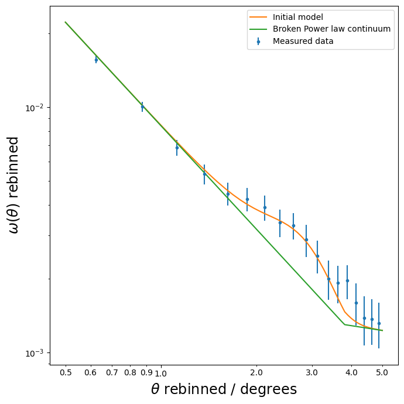

```python
# Create a figure
fig = plt.figure(figsize=(7, 7))

# Create a set of axes attached to our figure
ax = fig.add_subplot(1, 1, 1)

# Use the errorbar() method to plot the data
ax.errorbar(
    theta_rebinned,  # The array of rebinned theta values
    omega_rebinned,  # The array of rebinned omega values
    yerr=np.sqrt(omega_var_rebinned),  # The square root of the rebinned variance values
    linestyle="none",  # Don't draw a line between the points on our plot
    marker="o",  # Use a circular marker style
    markersize=3,  # Set a marker size slightly smaller than the default (which is 5)
    label="Measured data",  # Add a label that will be shown in the legend for this plot
)

# Use the `numpy.linspace` function to define a range of theta
# values at which to compute the values of the best fitting model
# function
theta_grid = np.linspace(0.5, 5, 50)

# Now call the `model` function to compute the model values for
# the values of theta in `theta_grid`. Note that we pass an array
# containing the initial parameter values as the second argument
# to the `model` function
initial_model_values = model(
    theta_grid,
    initial_parameter_guesses,
)

# Use the `plot` method of our axes object to plot the initial model
ax.plot(
    theta_grid,  # values of theta to plot the initial model for
    initial_model_values,  # values of the initial model
    label="Initial model",  # Add a label that will be shown in the legend for this plot
)

# Now call the `bkn_powerlaw` function to compute values for the
# broken power law continuum component of our model for the
# values of theta in `theta_grid`. Note that becuse of the way
# we defined the `bkn_powerlaw` function we must pass the parameters
# of our model that pertain to the broken
# power law separately.
initial_continuum_values = bkn_powerlaw(
    theta_grid,  # values of theta to plot the initial model for
    pl_norm,  # the brokemn power law normalisation
    pl_index_1,  # index of the broken power law component below the break
    pl_index_2,  # index of the broken power law component above the break
    pl_break,  # value of theta at which the power law breaks
)

# Use the `plot` method of our axes object to plot the initial continuum model
ax.plot(
    theta_grid,  # values of theta to plot the initial model for
    initial_continuum_values,  # values of the initial continuum model
    label="Broken Power law continuum",  # Add a label that will be shown in the legend for this plot
)

# Set the x and y axes to display logarithmic scales
ax.set_yscale("log")
ax.set_xscale("log")

# Fiddly formatting to improve the x-axis labels
from matplotlib import ticker
ax.xaxis.set_major_formatter(ticker.StrMethodFormatter('{x:.1f}'))
ax.xaxis.set_minor_formatter(ticker.StrMethodFormatter('{x:.1f}'))

# Set the x and y axes' titles
ax.set_ylabel(r"$\omega(\theta)$ rebinned", fontsize="xx-large")
ax.set_xlabel(r"$\theta$ rebinned / degrees", fontsize="xx-large")

# Add a legend to our axes
ax.legend()

# Tidy up the plot
plt.tight_layout()

plt.savefig("0.9-1.00_Plot3.png")
```

```python
# Bounds for model parameter values

# bounds on normalisation of the gaussian BAO signal component
# Note that we do not place an upper bound on this parameter.
bao_norm_bounds = [1e-3, None]
# bounds on mean of the gaussian BAO signal component
bao_location_bounds = [1.5, 4]
# bounds on sigma of the gaussian BAO signal component
bao_sigma_bounds = [0.4, 0.9]
# bounds on index of the broken power law component below the break
# Note that we restrict this to be negative, implying a falling power
# law.
pl_index_1_bounds = [-5, -1]
# bounds on index of the broken power law component above the break
# Note that we allow this to be slightly positive.
pl_index_2_bounds = [-3, 0.5]
# bounds on normalisation of the broken power law component
# Note that we do not place an upper bound on this parameter.
pl_norm_bounds = [1e-4, None]
# bounds on value of theta at which the power law breaks
# Note that we allow a large range of values because we do
# not need the continuum model to be physically meaningful
# but we do need it to be flexible.
pl_break_bounds = [3, 6]

# collect the parameter bounds together into a numpy array in the
# order that is expected by our `model` function.
parameter_bounds = np.array(
    [
        bao_norm_bounds,
        bao_location_bounds,
        bao_sigma_bounds,
        pl_index_1_bounds,
        pl_index_2_bounds,
        pl_norm_bounds,
        pl_break_bounds,
    ]
)
```

```python
# run the minimize function to find the best fit parameters
fit_results = imin.minimize(
    fit_function,
    x0=initial_parameter_guesses,
    args=[theta_rebinned, omega_rebinned, np.sqrt(omega_var_rebinned)],
    bounds=parameter_bounds,
    options=dict(stra=2, maxfun=10000),  # You should not need to change these options
)
```

```python
# test the value of the success attribute
if fit_results.success:
    # if True, print that the fit succeeded
    print("The fit succeeded!")
else:
    # if False, print that the fit failed and the message which may provide clues about why
    print("The fit failed:", fit_results.message)
```

```
The fit succeeded!
```

```python
# unpack the best fitting parameters found by the minimize function
(
    fitted_bao_norm,
    fitted_bao_location,  # the best fit BAO angular size
    fitted_bao_sigma,
    fitted_pl_index_1,
    fitted_pl_index_2,
    fitted_pl_norm,
    fitted_pl_break,
) = fit_results.x
```

```python
# The next two lines compute the parameter errors
fit_results.minuit.errordef = fit_results.minuit.LEAST_SQUARES
fit_results.minuit.hesse()

# unpack the best fitting parameter uncertainties
(
    fitted_bao_norm_err,
    fitted_bao_location_err,  # estimated uncertainty on the best fit BAO angular size
    fitted_bao_sigma_err,
    fitted_pl_index_1_err,
    fitted_pl_index_2_err,
    fitted_pl_break_err,
    fitted_pl_norm_err,
) = fit_results.minuit.errors
```

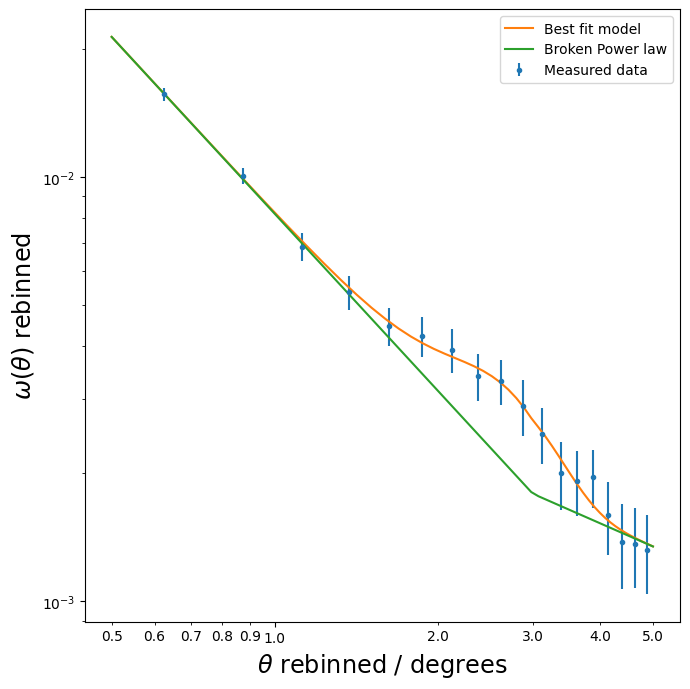

```python
# Create a figure
fig = plt.figure(figsize=(7, 7))

# Create a set of axes attached to our figure
ax = fig.add_subplot(1, 1, 1)

# Use the errorbar() method to plot the data
ax.errorbar(
    theta_rebinned,  # The array of rebinned theta values
    omega_rebinned,  # The array of rebinned omega values
    yerr=np.sqrt(omega_var_rebinned),  # The square root of the rebinned variance values
    linestyle="none",  # Don't draw a line between the points on our plot
    marker="o",  # Use a circular marker style
    markersize=3,  # Set a marker size slightly smaller than the default (which is 5)
    label="Measured data",  # Add a label that will be shown in the legend for this plot
)

# Use the `numpy.linspace` function to define a range of theta
# values at which to compute the values of the best fitting model
# function
theta_grid = np.linspace(0.5, 5, 50)

# Now call the `model` function to compute the model values for
# the values of theta in `theta_grid`. Note that we pass a list
# containing the best fit parameter values as the second argument
# to the `model` function
best_fit_model_values = model(
    theta_grid,
    [
        fitted_bao_norm,
        fitted_bao_location,  # the best fit BAO angular size
        fitted_bao_sigma,
        fitted_pl_index_1,
        fitted_pl_index_2,
        fitted_pl_norm,
        fitted_pl_break,
    ],
)

# Use the `plot` method of our axes object to plot the best fitting model
ax.plot(
    theta_grid,  # values of theta to plot the best fit model for
    best_fit_model_values,  # values of the best fitting model
    label="Best fit model",  # Add a label that will be shown in the legend for this plot
)

ax.plot(
    theta_grid,  # values of theta to plot the initial model for
    bkn_powerlaw(
        theta_grid,
        fitted_pl_norm,
        fitted_pl_index_1,
        fitted_pl_index_2,
        fitted_pl_break,
    ),  # values of the initial model
    label="Broken Power law",  # Add a label that will be shown in the legend for this plot
)

# Set the x and y axes to display logarithmic scales
ax.set_yscale("log")
ax.set_xscale("log")

# Fiddly formatting to improve the x-axis labels
from matplotlib import ticker
ax.xaxis.set_major_formatter(ticker.StrMethodFormatter('{x:.1f}'))
ax.xaxis.set_minor_formatter(ticker.StrMethodFormatter('{x:.1f}'))

# Set the x and y axes' titles
ax.set_ylabel(r"$\omega(\theta)$ rebinned", fontsize="xx-large")
ax.set_xlabel(r"$\theta$ rebinned / degrees", fontsize="xx-large")

# Add a legend to our axes
ax.legend()

# Tidy up the plot
plt.tight_layout()

plt.savefig("0.9-1.00_Plot4.png")
```

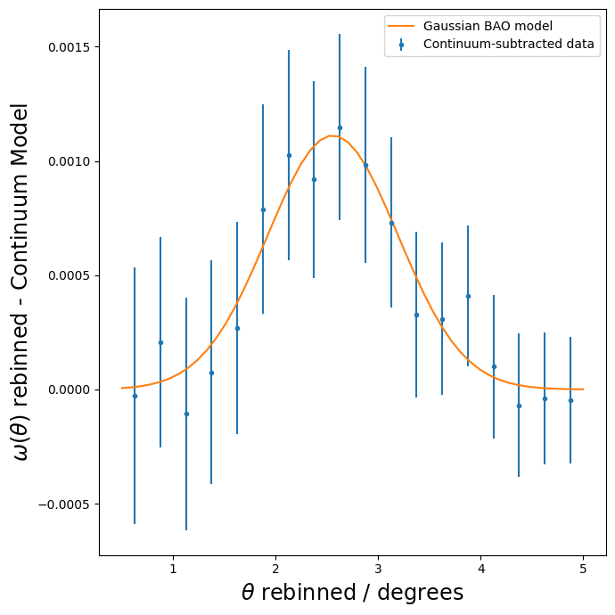

```python
# Create a figure
fig = plt.figure(figsize=(7, 7))

# Create a set of axes attached to our figure
ax = fig.add_subplot(1, 1, 1)

# subtract the continuum model corresponding with the best fit parameters from
# the correlation function data
continuum_subtracted_omega_rebinned = omega_rebinned - bkn_powerlaw(
    # calculate the values of the continuum model at the data point locations
    theta_rebinned,
    # pass the the best fit parameters
    fitted_pl_norm,
    fitted_pl_index_1,
    fitted_pl_index_2,
    fitted_pl_break,
)

# Use the errorbar() method to plot the continuum-subtracted data
ax.errorbar(
    theta_rebinned,  # The array of rebinned theta values
    continuum_subtracted_omega_rebinned,  # The array of continuum-subtracted omega values
    yerr=np.sqrt(omega_var_rebinned),  # The square root of the rebinned variance values
    linestyle="none",  # Don't draw a line between the points on our plot
    marker="o",  # Use a circular marker style
    markersize=3,  # Set a marker size slightly smaller than the default (which is 5)
    label="Continuum-subtracted data",  # Add a label that will be shown in the legend for this plot
)

# Use the `numpy.linspace` function to define a range of theta
# values at which to compute the values of the best fitting model
# function
theta_grid = np.linspace(0.5, 5, 50)

# Use the `plot` method of our axes object to plot the best fitting model
ax.plot(
    theta_grid,  # values of theta to plot the initial model for
    # gaussian model for the BAO signal
    gaussian(
        theta_grid,
        fitted_bao_location,
        fitted_bao_sigma,
        fitted_bao_norm,
    ),
    label="Gaussian BAO model",  # Add a label that will be shown in the legend for this plot
)

# Set the x and y axes' titles
ax.set_ylabel(r"$\omega(\theta)$ rebinned - Continuum Model", fontsize="xx-large")
ax.set_xlabel(r"$\theta$ rebinned / degrees", fontsize="xx-large")

# Add a legend to our axes
ax.legend()

# Tidy up the plot
plt.tight_layout()

plt.savefig("0.9-1.00_Plot5.png")
```

```python
# run the mnprofile function (the argument "x1" is just iminuit's internal
# label for the BAO angular size parameter)
test_bao_locs, chi_square_values, fit_succeeded = fit_results.minuit.mnprofile("x1")
```

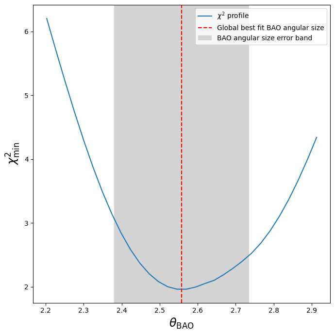

```python
# Create a figure
fig = plt.figure(figsize=(7, 7))

# Create a set of axes attached to our figure
ax = fig.add_subplot(1, 1, 1)

# Use the `plot` method of our axes object to plot chi-square versus BAO angular size
ax.plot(
    test_bao_locs,  # test values of the BAO angular size for which the chi square was minimised
    chi_square_values,  # the best fit chi-square values for each test BAO angular size
    label="$\chi^{2}$ profile",  # Add a label that will be shown in the legend for this plot
)

# Add a red, dashed vertical line at the location of the best fit value
ax.axvline(
    fitted_bao_location,
    color="r",
    linestyle="dashed",
    label="Global best fit BAO angular size",
)

# Add a filled grey region illustrating the range spanned by the fit uncertainties
# associated with the BAO angular size
ax.axvspan(
    fitted_bao_location - fitted_bao_location_err,
    fitted_bao_location + fitted_bao_location_err,
    facecolor="lightgrey",
    label="BAO angular size error band",
)

# Set the x and y axes' titles
ax.set_ylabel("$\chi^{2}_{\min}$", fontsize="xx-large")
ax.set_xlabel(r"$\theta_{\mathrm{BAO}}$", fontsize="xx-large")

# Add a legend to our axes
ax.legend()

# Tidy up the plot
plt.tight_layout()

plt.savefig("0.9-1.00_Plot6.png")
```

```python
# append the best fit BAO angular size
bao_locs.append(fitted_bao_location)
# append the uncertainty on the best fit BAO angular size
bao_loc_errors.append(fitted_bao_location_err)
```

```python
# generate an array of 100 redshifts  between 0.6 and 1.1
# for which to predict the expected size of the BAO feature
z_grid = np.linspace(start=0.6, stop=1.1, num=100)
```

```python
bao_comoving_size = 150 * u.Mpc
```

```python
bao_physical_sizes = bao_comoving_size / (1 + z_grid)
# print the physical sizes' units to verify that they are Mpc
print("The units of the computed physical sizes are", bao_physical_sizes.unit)
```

```
The units of the computed physical sizes are Mpc
```

```python
ang_diam_distances = apcosmo.Planck18.angular_diameter_distance(z_grid)
# print the angular diameter distances' units to verify that they are Mpc
print(
    "The units of the computed angular diameter distances are", ang_diam_distances.unit
)
```

```
The units of the computed angular diameter distances are Mpc
```

```python
# compute the predicted BAO angular scales in radians
bao_angular_scales_rad = (bao_physical_sizes / ang_diam_distances) * u.radian
# convert from radians to degrees
bao_angular_scales = bao_angular_scales_rad.to(u.degree)
```

```python
# compute the mean redhsift of the galaxies in our selection
z_mean = data_selection["DNF_ZMEAN_SOF"].mean()
z_mean_vals.append(z_mean)
```

```python
print(z_mean_vals)
print(bao_locs)
print(bao_loc_errors)
print(z_min_vals)
print(z_max_vals)
```

```
[0.94710153]
[2.5578188515535225]
[0.17756230899046366]
[0.9]
[1.0]
```

```python
# Combine the lists into a dictionary
data_dict = {
    "z_mean_vals": z_mean_vals,
    "bao_locs": bao_locs,
    "bao_loc_errors": bao_loc_errors,
    "z_min_vals": z_min_vals,
    "z_max_vals": z_max_vals,
}
```

```python
df = pd.DataFrame(data_dict)
```

```python
csv_filename = "data_2.csv"  # File name
df.to_csv(csv_filename, index=False)  # Save without row indices

print(f"Data saved successfully to {csv_filename}!")
```

```
Data saved successfully to data_2.csv!
```

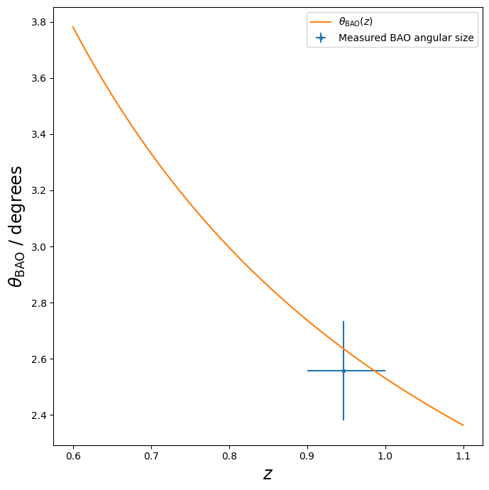

```python
# Create a figure
fig = plt.figure(figsize=(7, 7))

# Create a set of axes attached to our figure
ax = fig.add_subplot(1, 1, 1)

# compute sizes of lower and upper error bars in the redshift direction
# These are equal to the distance between the mean redshift and the lower
# or upper bin boundaries
z_err_low = np.array(z_mean_vals) - np.array(z_min_vals)
z_err_high = np.array(z_max_vals) - np.array(z_mean_vals)

# Use the errorbar() method to plot the data
ax.errorbar(
    x=z_mean_vals,  # mean redshift of galaxies in our redshift bin
    y=bao_locs,  # best fit BAO angular scale for galaxies in redshift bin
    yerr=np.atleast_2d(bao_loc_errors),  # uncertainty best fit BAO angular scale
    xerr=np.array([
        z_err_low,
        z_err_high,
    ]),  # horizontal errors to represent the reshift bin width
    linestyle="none",  # Don't draw a line between the points on our plot
    marker="o",  # Use a circular marker style
    markersize=3,  # Set a marker size slightly smaller than the default (which is 5)
    label="Measured BAO angular size",  # Add a label that will be shown in the legend for this plot
)


# Use the `plot` method of our axes object to plot theoretical angular sizes
ax.plot(
    z_grid,  # values of redshift for which to plot the theoretical angular sizes
    bao_angular_scales,  # values of the theoiretical angular sizes
    label=r"$\theta_{\mathrm{BAO}}(z)$",  # Add a label that will be shown in the legend for this plot
)

# Set the x and y axes' titles
ax.set_ylabel(r"$\theta_{\mathrm{BAO}}$ / degrees", fontsize="xx-large")
ax.set_xlabel("$z$", fontsize="xx-large")

# Add a legend to our axes
ax.legend()

# Tidy up the plot
plt.tight_layout()

plt.savefig("0.9-1.00_Plot7.png")
```

```python
# Print out your list of mean redshifts to as to identify an element you want to remove

print(z_mean_vals)

# The function below empties all of the lists

def clear_all_lists(z_min_vals,z_max_vals,z_mean_vals,bao_locs,bao_loc_errors):

        z_min_vals.clear()
        z_max_vals.clear()
        z_mean_vals.clear()
        bao_locs.clear()
        bao_loc_errors.clear()

clear_all_lists(z_min_vals,z_max_vals,z_mean_vals,bao_locs,bao_loc_errors)

print(z_mean_vals)
```

```
[0.94710153]
[]
```

## 1.00 < z < 1.10

```python
# create five empty lists to store data about redshift bins and BAO data in each bin
z_min_vals, z_max_vals, z_mean_vals, bao_locs, bao_loc_errors = [], [], [], [], []
```

```python
z_min = 1.00
z_max = 1.10

# append the minimum redshift of the galaxies in this bin
z_min_vals.append(z_min)
# append the maximum redshift of the galaxies in this bin
z_max_vals.append(z_max)

# Select a redshift-limited subset from the observed catalogue
data_selection = select_z_bin(data_table, z_min, z_max, "DNF_ZMEAN_SOF")
# Select a redshift-limited subset from the synthetic catalogue
random_selection = select_z_bin(random_table, z_min, z_max, "Z")
```

```python
data_cat = tc.Catalog(
    ra=np.array(
        data_selection["RA"], dtype=np.float16
    ),  # Right ascensions of our galaxies - just a column from the catalogue table
    dec=np.array(
        data_selection["DEC"], dtype=np.float16
    ),  # Declinations of our galaxies - just a column from the catalogue table
    ra_units="degrees",  # The units used for RA - degrees
    dec_units="degrees",  # The units used for Declination - degrees
    npatch=20,  # Count pairs within 20 separate patches to calculate a variance estimate
)

random_cat = tc.Catalog(
    ra=np.array(
        random_selection["RA"], dtype=np.float16
    ),  # Right ascensions of our galaxies - just a column from the catalogue table
    dec=np.array(
        random_selection["DEC"], dtype=np.float16
    ),  # Declinations of our galaxies - just a column from the catalogue table
    ra_units="degrees",  # The units used for RA - degrees
    dec_units="degrees",  # The units used for Declination - degrees
    patch_centers=data_cat.patch_centers,  # Use the patches that were calculated for the DES survey catalogue
)

# This NNCorrelation object will compute DD(theta)
dd = tc.NNCorrelation(
    min_sep=0.5,
    max_sep=5.0,
    bin_size=0.05,
    bin_type="Linear",
    sep_units="degrees",
    bin_slop=0.02,  # Specifying bin_slop=0.02 results in a small loss of precision but is much faster
    var_method="jackknife",
)

# This NNCorrelation object will compute RR(theta)
rr = tc.NNCorrelation(
    min_sep=0.5,
    max_sep=5.0,
    bin_size=0.05,
    bin_type="Linear",
    sep_units="degrees",
    bin_slop=0.02,  # Specifying bin_slop=0.02 results in a small loss of precision but is much faster
    var_method="jackknife",
)

# This NNCorrelation object will compute DR(theta)
dr = tc.NNCorrelation(
    min_sep=0.5,
    max_sep=5.0,
    bin_size=0.05,
    bin_type="Linear",
    sep_units="degrees",
    bin_slop=0.02,  # Specifying bin_slop=0.02 results in a small loss of precision but is much faster
    var_method="jackknife",
)
```

```python
# Actually calculate DD(theta) - we only need to pass the DES survey catalogue
dd.process(data_cat)

# Actually calculate RR(theta) - we only need to pass the synthetic catalogue
# Note that this is the most time consuming operation in this activity - it can take
# several minutes to complete.
rr.process(random_cat)

# Actually calculate DR(theta) - we need to pass both catalogues
dr.process(data_cat, random_cat)

omega, omega_variance = dd.calculateXi(rr=rr, dr=dr)
```

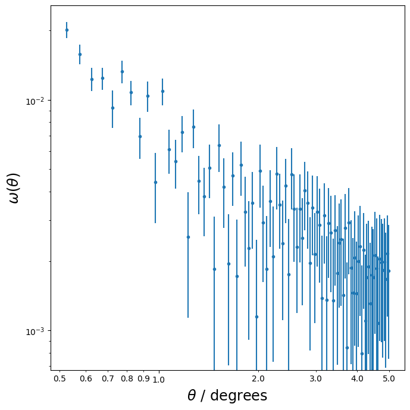

```python
# Create a figure
fig = plt.figure(figsize=(7, 7))

# Create a set of axes attached to our figure
ax = fig.add_subplot(1, 1, 1)

# Use the errorbar() method to plot the data
ax.errorbar(
    theta,  # The array of theta values calculated by treecorr
    omega,  # The array of omega values calculated by treecorr
    yerr=np.sqrt(
        omega_variance
    ),  # The square root variance values calculated by treecorr
    linestyle="none",  # Don't draw a line between the points on our plot
    marker="o",  # Use a circular marker style
    markersize=3,  # Set a marker size slightly smaller than the default (which is 5)
)

# Set the x and y axes to display logarithmic scales
ax.set_yscale("log")
ax.set_xscale("log")

# Fiddly formatting to improve the x-axis labels
from matplotlib import ticker
ax.xaxis.set_major_formatter(ticker.StrMethodFormatter('{x:.1f}'))
ax.xaxis.set_minor_formatter(ticker.StrMethodFormatter('{x:.1f}'))

# Set the x and y axes' titles
ax.set_ylabel(r"$\omega(\theta)$", fontsize="xx-large")
ax.set_xlabel(r"$\theta$ / degrees", fontsize="xx-large")

# Tidy up the plot
plt.tight_layout()

plt.savefig("1.00-1.10_Plot1.png")
```

```python
def rebin(theta, omega, omega_variance, points_to_combine=5):
    rebinned = np.array(
        [
            [
                theta[start : start + points_to_combine].mean(),
                omega[start : start + points_to_combine].mean(),
                omega_variance[start : start + points_to_combine].sum()
                / points_to_combine**2,
            ]
            for start in range(0, dd.rnom.size, points_to_combine)
        ]
    ).T
    return rebinned
```

```python
# Rebin the correlation function data using our `rebin` function
# The function returns three arrays containing our rebinned data.
theta_rebinned, omega_rebinned, omega_var_rebinned = rebin(
    theta, omega, omega_variance, 5
)
```

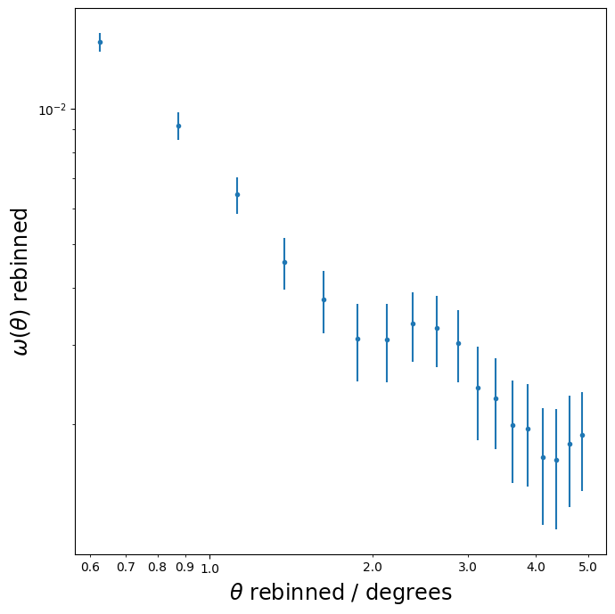

```python
# Create a figure
fig = plt.figure(figsize=(7, 7))

# Create a set of axes attached to our figure
ax = fig.add_subplot(1, 1, 1)

# Use the errorbar() method to plot the data
ax.errorbar(
    theta_rebinned,  # The array of rebinned theta values
    omega_rebinned,  # The array of rebinned omega values
    yerr=np.sqrt(omega_var_rebinned),  # The square root of the rebinned variance values
    linestyle="none",  # Don't draw a line between the points on our plot
    marker="o",  # Use a circular marker style
    markersize=3,  # Set a marker size slightly smaller than the default (which is 5)
)

# Set the x and y axes to display logarithmic scales
ax.set_yscale("log")
ax.set_xscale("log")

# Fiddly formatting to improve the x-axis labels
from matplotlib import ticker
ax.xaxis.set_major_formatter(ticker.StrMethodFormatter('{x:.1f}'))
ax.xaxis.set_minor_formatter(ticker.StrMethodFormatter('{x:.1f}'))

# Set the x and y axes' titles
ax.set_ylabel(r"$\omega(\theta)$ rebinned", fontsize="xx-large")
ax.set_xlabel(r"$\theta$ rebinned / degrees", fontsize="xx-large")

# Tidy up the plot
plt.tight_layout()

plt.savefig("1.00-1.10_Plot2.png")
```

```python
# Function to compute the broken power law component
def bkn_powerlaw(
    theta,  # numpy array of theta values
    norm,  # power law normalisation
    index_below,  # power law index below the break
    index_above,  # power law index above the break
    theta_break,  # angular separation at which the power law breaks
):
    # compute and return the values of the broken power law component using
    # the numpy.where function
    return np.where(
        # A boolean array True at positions where theta < theta_break
        # and False otherwise
        theta < theta_break,
        # An array of values to choose if the corresponding element of
        # the first argument is True i.e. for values of theta below
        # theta_break
        norm * (theta / theta_break) ** index_below,
        # An array of values to choose if the corresponding element of
        # the first argument is False i.e. for values of theta above
        # or equal to theta_break
        norm * (theta / theta_break) ** index_above,
    )


# Function to compute the gaussian component
def gaussian(
    theta,  # numpy array of theta values
    mean,  # gaussian mean
    sigma,  # gaussian sigma (standard deviation)
    norm,  # gaussian normalisation
):
    # compute and return the values of the gaussian component
    return norm * np.exp(-(((theta - mean) / sigma) ** 2))


# Function to compute the combined model
def model(
    theta,  # numpy array of theta values
    model_params,  # array of all 5 model parameters
):
    # extract the individual model parameters.
    # note that we expect them to be in a specific order and we will
    # need to be aware of this when we use the iminuit.minimize
    # function
    (
        bao_norm,
        bao_location,
        bao_sigma,
        pl_index_1,
        pl_index_2,
        pl_norm,
        pl_break,
    ) = model_params

    # compute the values of the power law components and store the results
    # power_law_1 = powerlaw(theta, pl_norm_1, pl_index_1)
    # power_law_2 = powerlaw(theta, pl_norm_2, pl_index_2)
    broken_powerlaw = bkn_powerlaw(theta, pl_norm, pl_index_1, pl_index_2, pl_break)
    # compute the values of the gaussian component and store the result
    bao_signal = gaussian(theta, bao_location, bao_sigma, bao_norm)

    # compute the combined model values by summing the two component arrays
    model = broken_powerlaw + bao_signal

    # return the combined model values
    return model
```

```python
# Fit function that computes the chi-square statistic
def fit_function(model_params, *data):
    # unpack the 2-dimensional data array into three separate data arrays.
    # note that we expect them to be in a specific order and we will
    # need to be aware of this when we use the iminuit.minimize
    # function
    theta, omega, omega_errors = data

    # call the model function to compute values of the combined model
    # given an array of theta values and the set of model parameters
    # that was passed to this function.
    model_omega = model(theta, model_params)

    # compute the chi-square statistic
    chi_square = (((omega - model_omega) / omega_errors) ** 2).sum()

    # return the computed chi_square statistic
    return chi_square
```

```python
# final guesses for parameters
bao_norm = 0.001    # normalisation of the gaussian BAO signal component
bao_location = 3.0  # mean of the gaussian BAO signal component
bao_sigma = 0.9     # sigma of the gaussian BAO signal component
pl_index_1 = -1.3   # index of the broken power law component below the break
pl_index_2 = 0.4   # index of the broken power law component above the break
pl_norm = 1.3e-3    # normalisation of the broken power law component
pl_break = 3.8      # value of theta at which the power law breaks


# collect the initial parameter guesses together into a numpy array in the
# order that is expected by our `model` function.
initial_parameter_guesses = np.array(
    [bao_norm, bao_location, bao_sigma, pl_index_1, pl_index_2, pl_norm, pl_break]
)
```

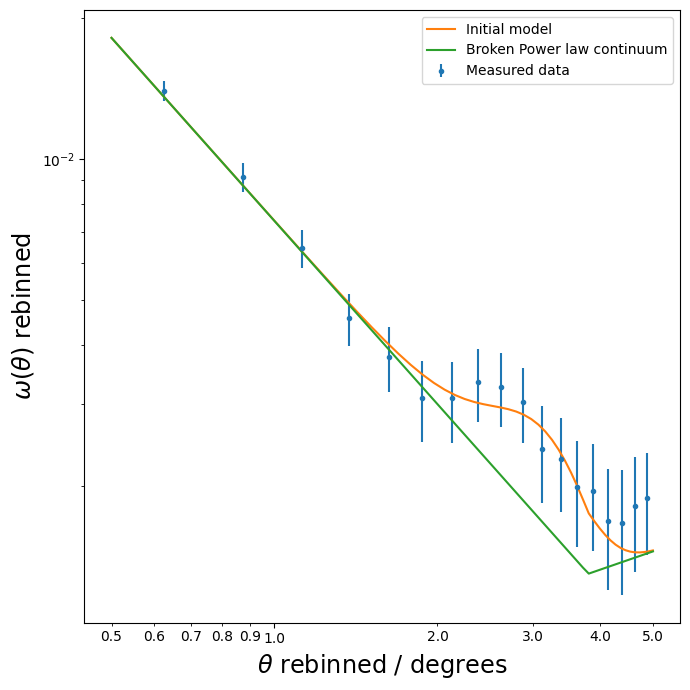

```python
# Create a figure
fig = plt.figure(figsize=(7, 7))

# Create a set of axes attached to our figure
ax = fig.add_subplot(1, 1, 1)

# Use the errorbar() method to plot the data
ax.errorbar(
    theta_rebinned,  # The array of rebinned theta values
    omega_rebinned,  # The array of rebinned omega values
    yerr=np.sqrt(omega_var_rebinned),  # The square root of the rebinned variance values
    linestyle="none",  # Don't draw a line between the points on our plot
    marker="o",  # Use a circular marker style
    markersize=3,  # Set a marker size slightly smaller than the default (which is 5)
    label="Measured data",  # Add a label that will be shown in the legend for this plot
)

# Use the `numpy.linspace` function to define a range of theta
# values at which to compute the values of the best fitting model
# function
theta_grid = np.linspace(0.5, 5, 50)

# Now call the `model` function to compute the model values for
# the values of theta in `theta_grid`. Note that we pass an array
# containing the initial parameter values as the second argument
# to the `model` function
initial_model_values = model(
    theta_grid,
    initial_parameter_guesses,
)

# Use the `plot` method of our axes object to plot the initial model
ax.plot(
    theta_grid,  # values of theta to plot the initial model for
    initial_model_values,  # values of the initial model
    label="Initial model",  # Add a label that will be shown in the legend for this plot
)

# Now call the `bkn_powerlaw` function to compute values for the
# broken power law continuum component of our model for the
# values of theta in `theta_grid`. Note that becuse of the way
# we defined the `bkn_powerlaw` function we must pass the parameters
# of our model that pertain to the broken
# power law separately.
initial_continuum_values = bkn_powerlaw(
    theta_grid,  # values of theta to plot the initial model for
    pl_norm,  # the brokemn power law normalisation
    pl_index_1,  # index of the broken power law component below the break
    pl_index_2,  # index of the broken power law component above the break
    pl_break,  # value of theta at which the power law breaks
)

# Use the `plot` method of our axes object to plot the initial continuum model
ax.plot(
    theta_grid,  # values of theta to plot the initial model for
    initial_continuum_values,  # values of the initial continuum model
    label="Broken Power law continuum",  # Add a label that will be shown in the legend for this plot
)

# Set the x and y axes to display logarithmic scales
ax.set_yscale("log")
ax.set_xscale("log")

# Fiddly formatting to improve the x-axis labels
from matplotlib import ticker
ax.xaxis.set_major_formatter(ticker.StrMethodFormatter('{x:.1f}'))
ax.xaxis.set_minor_formatter(ticker.StrMethodFormatter('{x:.1f}'))

# Set the x and y axes' titles
ax.set_ylabel(r"$\omega(\theta)$ rebinned", fontsize="xx-large")
ax.set_xlabel(r"$\theta$ rebinned / degrees", fontsize="xx-large")

# Add a legend to our axes
ax.legend()

# Tidy up the plot
plt.tight_layout()

plt.savefig("1.00-1.10_Plot3.png")
```

```python
# Bounds for model parameter values

# bounds on normalisation of the gaussian BAO signal component
# Note that we do not place an upper bound on this parameter.
bao_norm_bounds = [1e-3, None]
# bounds on mean of the gaussian BAO signal component
bao_location_bounds = [1.5, 4]
# bounds on sigma of the gaussian BAO signal component
bao_sigma_bounds = [0.4, 0.9]
# bounds on index of the broken power law component below the break
# Note that we restrict this to be negative, implying a falling power
# law.
pl_index_1_bounds = [-5, -1]
# bounds on index of the broken power law component above the break
# Note that we allow this to be slightly positive.
pl_index_2_bounds = [-3, 0.5]
# bounds on normalisation of the broken power law component
# Note that we do not place an upper bound on this parameter.
pl_norm_bounds = [1e-4, None]
# bounds on value of theta at which the power law breaks
# Note that we allow a large range of values because we do
# not need the continuum model to be physically meaningful
# but we do need it to be flexible.
pl_break_bounds = [3, 6]

# collect the parameter bounds together into a numpy array in the
# order that is expected by our `model` function.
parameter_bounds = np.array(
    [
        bao_norm_bounds,
        bao_location_bounds,
        bao_sigma_bounds,
        pl_index_1_bounds,
        pl_index_2_bounds,
        pl_norm_bounds,
        pl_break_bounds,
    ]
)
```

```python
# run the minimize function to find the best fit parameters
fit_results = imin.minimize(
    fit_function,
    x0=initial_parameter_guesses,
    args=[theta_rebinned, omega_rebinned, np.sqrt(omega_var_rebinned)],
    bounds=parameter_bounds,
    options=dict(stra=2, maxfun=10000),  # You should not need to change these options
)
```

```python
# test the value of the success attribute
if fit_results.success:
    # if True, print that the fit succeeded
    print("The fit succeeded!")
else:
    # if False, print that the fit failed and the message which may provide clues about why
    print("The fit failed:", fit_results.message)
```

```
The fit succeeded!
```

```python
# unpack the best fitting parameters found by the minimize function
(
    fitted_bao_norm,
    fitted_bao_location,  # the best fit BAO angular size
    fitted_bao_sigma,
    fitted_pl_index_1,
    fitted_pl_index_2,
    fitted_pl_norm,
    fitted_pl_break,
) = fit_results.x
```

```python
# The next two lines compute the parameter errors
fit_results.minuit.errordef = fit_results.minuit.LEAST_SQUARES
fit_results.minuit.hesse()

# unpack the best fitting parameter uncertainties
(
    fitted_bao_norm_err,
    fitted_bao_location_err,  # estimated uncertainty on the best fit BAO angular size
    fitted_bao_sigma_err,
    fitted_pl_index_1_err,
    fitted_pl_index_2_err,
    fitted_pl_break_err,
    fitted_pl_norm_err,
) = fit_results.minuit.errors
```

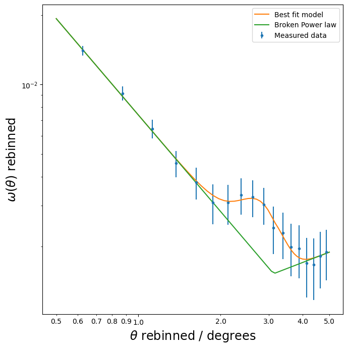

```python
# Create a figure
fig = plt.figure(figsize=(7, 7))

# Create a set of axes attached to our figure
ax = fig.add_subplot(1, 1, 1)

# Use the errorbar() method to plot the data
ax.errorbar(
    theta_rebinned,  # The array of rebinned theta values
    omega_rebinned,  # The array of rebinned omega values
    yerr=np.sqrt(omega_var_rebinned),  # The square root of the rebinned variance values
    linestyle="none",  # Don't draw a line between the points on our plot
    marker="o",  # Use a circular marker style
    markersize=3,  # Set a marker size slightly smaller than the default (which is 5)
    label="Measured data",  # Add a label that will be shown in the legend for this plot
)

# Use the `numpy.linspace` function to define a range of theta
# values at which to compute the values of the best fitting model
# function
theta_grid = np.linspace(0.5, 5, 50)

# Now call the `model` function to compute the model values for
# the values of theta in `theta_grid`. Note that we pass a list
# containing the best fit parameter values as the second argument
# to the `model` function
best_fit_model_values = model(
    theta_grid,
    [
        fitted_bao_norm,
        fitted_bao_location,  # the best fit BAO angular size
        fitted_bao_sigma,
        fitted_pl_index_1,
        fitted_pl_index_2,
        fitted_pl_norm,
        fitted_pl_break,
    ],
)

# Use the `plot` method of our axes object to plot the best fitting model
ax.plot(
    theta_grid,  # values of theta to plot the best fit model for
    best_fit_model_values,  # values of the best fitting model
    label="Best fit model",  # Add a label that will be shown in the legend for this plot
)

ax.plot(
    theta_grid,  # values of theta to plot the initial model for
    bkn_powerlaw(
        theta_grid,
        fitted_pl_norm,
        fitted_pl_index_1,
        fitted_pl_index_2,
        fitted_pl_break,
    ),  # values of the initial model
    label="Broken Power law",  # Add a label that will be shown in the legend for this plot
)

# Set the x and y axes to display logarithmic scales
ax.set_yscale("log")
ax.set_xscale("log")

# Fiddly formatting to improve the x-axis labels
from matplotlib import ticker
ax.xaxis.set_major_formatter(ticker.StrMethodFormatter('{x:.1f}'))
ax.xaxis.set_minor_formatter(ticker.StrMethodFormatter('{x:.1f}'))

# Set the x and y axes' titles
ax.set_ylabel(r"$\omega(\theta)$ rebinned", fontsize="xx-large")
ax.set_xlabel(r"$\theta$ rebinned / degrees", fontsize="xx-large")

# Add a legend to our axes
ax.legend()

# Tidy up the plot
plt.tight_layout()

plt.savefig("1.00-1.10_Plot4.png")
```

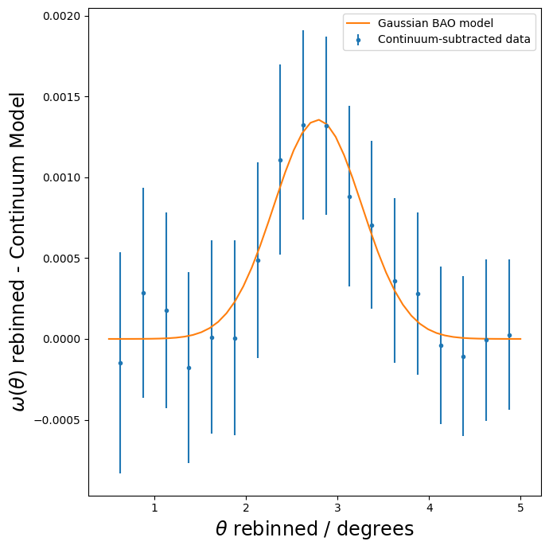

```python
# Create a figure
fig = plt.figure(figsize=(7, 7))

# Create a set of axes attached to our figure
ax = fig.add_subplot(1, 1, 1)

# subtract the continuum model corresponding with the best fit parameters from
# the correlation function data
continuum_subtracted_omega_rebinned = omega_rebinned - bkn_powerlaw(
    # calculate the values of the continuum model at the data point locations
    theta_rebinned,
    # pass the the best fit parameters
    fitted_pl_norm,
    fitted_pl_index_1,
    fitted_pl_index_2,
    fitted_pl_break,
)

# Use the errorbar() method to plot the continuum-subtracted data
ax.errorbar(
    theta_rebinned,  # The array of rebinned theta values
    continuum_subtracted_omega_rebinned,  # The array of continuum-subtracted omega values
    yerr=np.sqrt(omega_var_rebinned),  # The square root of the rebinned variance values
    linestyle="none",  # Don't draw a line between the points on our plot
    marker="o",  # Use a circular marker style
    markersize=3,  # Set a marker size slightly smaller than the default (which is 5)
    label="Continuum-subtracted data",  # Add a label that will be shown in the legend for this plot
)

# Use the `numpy.linspace` function to define a range of theta
# values at which to compute the values of the best fitting model
# function
theta_grid = np.linspace(0.5, 5, 50)

# Use the `plot` method of our axes object to plot the best fitting model
ax.plot(
    theta_grid,  # values of theta to plot the initial model for
    # gaussian model for the BAO signal
    gaussian(
        theta_grid,
        fitted_bao_location,
        fitted_bao_sigma,
        fitted_bao_norm,
    ),
    label="Gaussian BAO model",  # Add a label that will be shown in the legend for this plot
)

# Set the x and y axes' titles
ax.set_ylabel(r"$\omega(\theta)$ rebinned - Continuum Model", fontsize="xx-large")
ax.set_xlabel(r"$\theta$ rebinned / degrees", fontsize="xx-large")

# Add a legend to our axes
ax.legend()

# Tidy up the plot
plt.tight_layout()

plt.savefig("1.00-1.10_Plot5.png")
```

```python
# run the mnprofile function (the argument "x1" is just iminuit's internal
# label for the BAO angular size parameter)
test_bao_locs, chi_square_values, fit_succeeded = fit_results.minuit.mnprofile("x1")
```

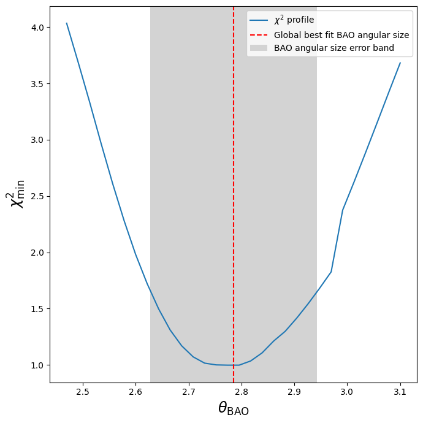

```python
# Create a figure
fig = plt.figure(figsize=(7, 7))

# Create a set of axes attached to our figure
ax = fig.add_subplot(1, 1, 1)

# Use the `plot` method of our axes object to plot chi-square versus BAO angular size
ax.plot(
    test_bao_locs,  # test values of the BAO angular size for which the chi square was minimised
    chi_square_values,  # the best fit chi-square values for each test BAO angular size
    label="$\chi^{2}$ profile",  # Add a label that will be shown in the legend for this plot
)

# Add a red, dashed vertical line at the location of the best fit value
ax.axvline(
    fitted_bao_location,
    color="r",
    linestyle="dashed",
    label="Global best fit BAO angular size",
)

# Add a filled grey region illustrating the range spanned by the fit uncertainties
# associated with the BAO angular size
ax.axvspan(
    fitted_bao_location - fitted_bao_location_err,
    fitted_bao_location + fitted_bao_location_err,
    facecolor="lightgrey",
    label="BAO angular size error band",
)

# Set the x and y axes' titles
ax.set_ylabel("$\chi^{2}_{\min}$", fontsize="xx-large")
ax.set_xlabel(r"$\theta_{\mathrm{BAO}}$", fontsize="xx-large")

# Add a legend to our axes
ax.legend()

# Tidy up the plot
plt.tight_layout()

plt.savefig("1.00-1.10_Plot6.png")
```

```python
# append the best fit BAO angular size
bao_locs.append(fitted_bao_location)
# append the uncertainty on the best fit BAO angular size
bao_loc_errors.append(fitted_bao_location_err)
```

```python
# generate an array of 100 redshifts  between 0.6 and 1.1
# for which to predict the expected size of the BAO feature
z_grid = np.linspace(start=0.6, stop=1.1, num=100)
```

```python
bao_comoving_size = 150 * u.Mpc
```

```python
bao_physical_sizes = bao_comoving_size / (1 + z_grid)
# print the physical sizes' units to verify that they are Mpc
print("The units of the computed physical sizes are", bao_physical_sizes.unit)
```

```
The units of the computed physical sizes are Mpc
```

```python
ang_diam_distances = apcosmo.Planck18.angular_diameter_distance(z_grid)
# print the angular diameter distances' units to verify that they are Mpc
print(
    "The units of the computed angular diameter distances are", ang_diam_distances.unit
)
```

```
The units of the computed angular diameter distances are Mpc
```

```python
# compute the predicted BAO angular scales in radians
bao_angular_scales_rad = (bao_physical_sizes / ang_diam_distances) * u.radian
# convert from radians to degrees
bao_angular_scales = bao_angular_scales_rad.to(u.degree)
```

```python
# compute the mean redhsift of the galaxies in our selection
z_mean = data_selection["DNF_ZMEAN_SOF"].mean()
z_mean_vals.append(z_mean)
```

```python
print(z_mean_vals)
print(bao_locs)
print(bao_loc_errors)
print(z_min_vals)
print(z_max_vals)
```

```
[1.0475651]
[2.784842617422405]
[0.15770654037779153]
[1.0]
[1.1]
```

```python
# Combine the lists into a dictionary
data_dict = {
    "z_mean_vals": z_mean_vals,
    "bao_locs": bao_locs,
    "bao_loc_errors": bao_loc_errors,
    "z_min_vals": z_min_vals,
    "z_max_vals": z_max_vals,
}
```

```python
df = pd.DataFrame(data_dict)
```

```python
csv_filename = "data_3.csv"  # File name
df.to_csv(csv_filename, index=False)  # Save without row indices

print(f"Data saved successfully to {csv_filename}!")
```

```
Data saved successfully to data_3.csv!
```

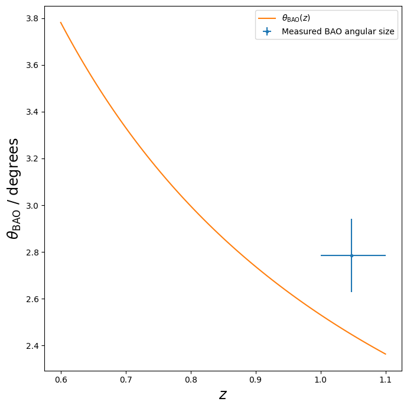

```python
# Create a figure
fig = plt.figure(figsize=(7, 7))

# Create a set of axes attached to our figure
ax = fig.add_subplot(1, 1, 1)

# compute sizes of lower and upper error bars in the redshift direction
# These are equal to the distance between the mean redshift and the lower
# or upper bin boundaries
z_err_low = np.array(z_mean_vals) - np.array(z_min_vals)
z_err_high = np.array(z_max_vals) - np.array(z_mean_vals)

# Use the errorbar() method to plot the data
ax.errorbar(
    x=z_mean_vals,  # mean redshift of galaxies in our redshift bin
    y=bao_locs,  # best fit BAO angular scale for galaxies in redshift bin
    yerr=np.atleast_2d(bao_loc_errors),  # uncertainty best fit BAO angular scale
    xerr=np.array([
        z_err_low,
        z_err_high,
    ]),  # horizontal errors to represent the reshift bin width
    linestyle="none",  # Don't draw a line between the points on our plot
    marker="o",  # Use a circular marker style
    markersize=3,  # Set a marker size slightly smaller than the default (which is 5)
    label="Measured BAO angular size",  # Add a label that will be shown in the legend for this plot
)


# Use the `plot` method of our axes object to plot theoretical angular sizes
ax.plot(
    z_grid,  # values of redshift for which to plot the theoretical angular sizes
    bao_angular_scales,  # values of the theoiretical angular sizes
    label=r"$\theta_{\mathrm{BAO}}(z)$",  # Add a label that will be shown in the legend for this plot
)

# Set the x and y axes' titles
ax.set_ylabel(r"$\theta_{\mathrm{BAO}}$ / degrees", fontsize="xx-large")
ax.set_xlabel("$z$", fontsize="xx-large")

# Add a legend to our axes
ax.legend()

# Tidy up the plot
plt.tight_layout()

plt.savefig("1.00-1.10_Plot7.png")
```

```python
# Print out your list of mean redshifts to as to identify an element you want to remove

print(z_mean_vals)

# The function below empties all of the lists

def clear_all_lists(z_min_vals,z_max_vals,z_mean_vals,bao_locs,bao_loc_errors):

        z_min_vals.clear()
        z_max_vals.clear()
        z_mean_vals.clear()
        bao_locs.clear()
        bao_loc_errors.clear()

clear_all_lists(z_min_vals,z_max_vals,z_mean_vals,bao_locs,bao_loc_errors)

print(z_mean_vals)
```

```
[1.0475651]
[]
```

## 0.75 < z < 0.85

```python
# create five empty lists to store data about redshift bins and BAO data in each bin
z_min_vals, z_max_vals, z_mean_vals, bao_locs, bao_loc_errors = [], [], [], [], []
```

```python
z_min = 0.75
z_max = 0.85

# append the minimum redshift of the galaxies in this bin
z_min_vals.append(z_min)
# append the maximum redshift of the galaxies in this bin
z_max_vals.append(z_max)

# Select a redshift-limited subset from the observed catalogue
data_selection = select_z_bin(data_table, z_min, z_max, "DNF_ZMEAN_SOF")
# Select a redshift-limited subset from the synthetic catalogue
random_selection = select_z_bin(random_table, z_min, z_max, "Z")
```

```python
data_cat = tc.Catalog(
    ra=np.array(
        data_selection["RA"], dtype=np.float16
    ),  # Right ascensions of our galaxies - just a column from the catalogue table
    dec=np.array(
        data_selection["DEC"], dtype=np.float16
    ),  # Declinations of our galaxies - just a column from the catalogue table
    ra_units="degrees",  # The units used for RA - degrees
    dec_units="degrees",  # The units used for Declination - degrees
    npatch=20,  # Count pairs within 20 separate patches to calculate a variance estimate
)

random_cat = tc.Catalog(
    ra=np.array(
        random_selection["RA"], dtype=np.float16
    ),  # Right ascensions of our galaxies - just a column from the catalogue table
    dec=np.array(
        random_selection["DEC"], dtype=np.float16
    ),  # Declinations of our galaxies - just a column from the catalogue table
    ra_units="degrees",  # The units used for RA - degrees
    dec_units="degrees",  # The units used for Declination - degrees
    patch_centers=data_cat.patch_centers,  # Use the patches that were calculated for the DES survey catalogue
)

# This NNCorrelation object will compute DD(theta)
dd = tc.NNCorrelation(
    min_sep=0.5,
    max_sep=5.0,
    bin_size=0.05,
    bin_type="Linear",
    sep_units="degrees",
    bin_slop=0.02,  # Specifying bin_slop=0.02 results in a small loss of precision but is much faster
    var_method="jackknife",
)

# This NNCorrelation object will compute RR(theta)
rr = tc.NNCorrelation(
    min_sep=0.5,
    max_sep=5.0,
    bin_size=0.05,
    bin_type="Linear",
    sep_units="degrees",
    bin_slop=0.02,  # Specifying bin_slop=0.02 results in a small loss of precision but is much faster
    var_method="jackknife",
)

# This NNCorrelation object will compute DR(theta)
dr = tc.NNCorrelation(
    min_sep=0.5,
    max_sep=5.0,
    bin_size=0.05,
    bin_type="Linear",
    sep_units="degrees",
    bin_slop=0.02,  # Specifying bin_slop=0.02 results in a small loss of precision but is much faster
    var_method="jackknife",
)
```

```python
# Actually calculate DD(theta) - we only need to pass the DES survey catalogue
dd.process(data_cat)

# Actually calculate RR(theta) - we only need to pass the synthetic catalogue
# Note that this is the most time consuming operation in this activity - it can take
# several minutes to complete.
rr.process(random_cat)

# Actually calculate DR(theta) - we need to pass both catalogues
dr.process(data_cat, random_cat)

omega, omega_variance = dd.calculateXi(rr=rr, dr=dr)
```

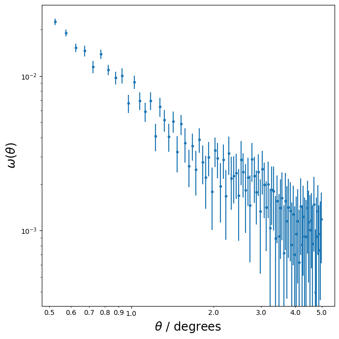

```python
# Create a figure
fig = plt.figure(figsize=(7, 7))

# Create a set of axes attached to our figure
ax = fig.add_subplot(1, 1, 1)

# Use the errorbar() method to plot the data
ax.errorbar(
    theta,  # The array of theta values calculated by treecorr
    omega,  # The array of omega values calculated by treecorr
    yerr=np.sqrt(
        omega_variance
    ),  # The square root variance values calculated by treecorr
    linestyle="none",  # Don't draw a line between the points on our plot
    marker="o",  # Use a circular marker style
    markersize=3,  # Set a marker size slightly smaller than the default (which is 5)
)

# Set the x and y axes to display logarithmic scales
ax.set_yscale("log")
ax.set_xscale("log")

# Fiddly formatting to improve the x-axis labels
from matplotlib import ticker
ax.xaxis.set_major_formatter(ticker.StrMethodFormatter('{x:.1f}'))
ax.xaxis.set_minor_formatter(ticker.StrMethodFormatter('{x:.1f}'))

# Set the x and y axes' titles
ax.set_ylabel(r"$\omega(\theta)$", fontsize="xx-large")
ax.set_xlabel(r"$\theta$ / degrees", fontsize="xx-large")

# Tidy up the plot
plt.tight_layout()

plt.savefig("0.75-0.85_Plot1.png")
```

```python
def rebin(theta, omega, omega_variance, points_to_combine=5):
    rebinned = np.array(
        [
            [
                theta[start : start + points_to_combine].mean(),
                omega[start : start + points_to_combine].mean(),
                omega_variance[start : start + points_to_combine].sum()
                / points_to_combine**2,
            ]
            for start in range(0, dd.rnom.size, points_to_combine)
        ]
    ).T
    return rebinned
```

```python
# Rebin the correlation function data using our `rebin` function
# The function returns three arrays containing our rebinned data.
theta_rebinned, omega_rebinned, omega_var_rebinned = rebin(
    theta, omega, omega_variance, 5
)
```

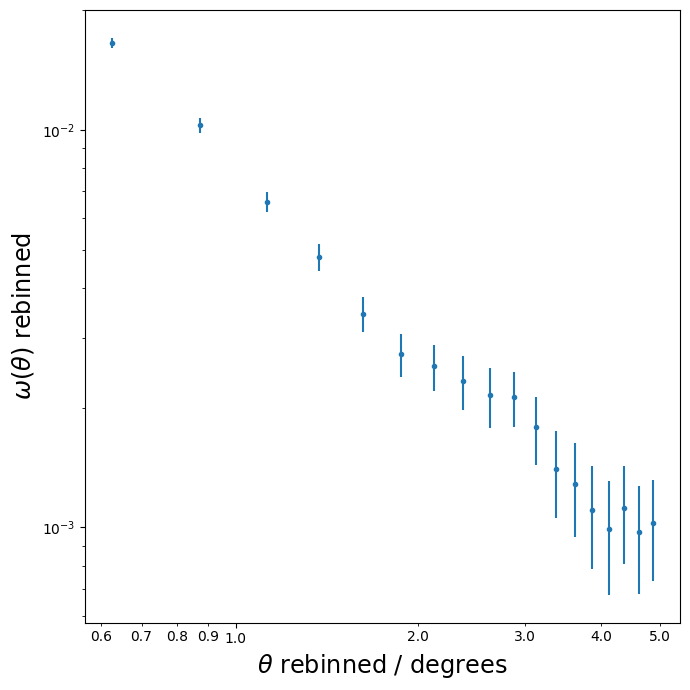

```python
# Create a figure
fig = plt.figure(figsize=(7, 7))

# Create a set of axes attached to our figure
ax = fig.add_subplot(1, 1, 1)

# Use the errorbar() method to plot the data
ax.errorbar(
    theta_rebinned,  # The array of rebinned theta values
    omega_rebinned,  # The array of rebinned omega values
    yerr=np.sqrt(omega_var_rebinned),  # The square root of the rebinned variance values
    linestyle="none",  # Don't draw a line between the points on our plot
    marker="o",  # Use a circular marker style
    markersize=3,  # Set a marker size slightly smaller than the default (which is 5)
)

# Set the x and y axes to display logarithmic scales
ax.set_yscale("log")
ax.set_xscale("log")

# Fiddly formatting to improve the x-axis labels
from matplotlib import ticker
ax.xaxis.set_major_formatter(ticker.StrMethodFormatter('{x:.1f}'))
ax.xaxis.set_minor_formatter(ticker.StrMethodFormatter('{x:.1f}'))

# Set the x and y axes' titles
ax.set_ylabel(r"$\omega(\theta)$ rebinned", fontsize="xx-large")
ax.set_xlabel(r"$\theta$ rebinned / degrees", fontsize="xx-large")

# Tidy up the plot
plt.tight_layout()

plt.savefig("0.75-0.85_Plot2.png")
```